Skip to manuscript

Recursive Industrial Intelligence Fourth Edition · r4.0

# Recursive Industrial Intelligence

## Fourth Edition, revision 4.0 · July 2026

**Leonardo Stern · Independent researcher**

*A self-sustaining, self-expanding space industrial system is coherent as an argument; whether it is feasible or economical is a question for models. This standalone edition preserves the executed Third Edition models and adds an explicit autonomous seed, its knowledge package, its material flows, and the dynamics by which it attempts to reproduce.*

> **Status.** Fourth Edition r4.0 release candidate, completed 2026-07-27 from the frozen Third Edition r3.5 baseline and not yet represented as an immutable tag or version DOI. The complete implementation and artifacts are published on the repository’s `main` branch; the final tagged build must add the immutable URL, release date, and version DOI. **Standalone:** this document carries the full argument and requires no prior edition; earlier editions are intellectual history, not dependencies. The inherited r3.5 results regenerate via `scripts/run_baseline.py`, `run_part2.py`, and `run_deep.py` and are checksummed in `outputs/MANIFEST.md`. The new integrated-bootstrap results regenerate via `scripts/run_fourth.py` and are checksummed separately in `outputs/fourth/MANIFEST.md`. They reserve explicit terms for material flows, seed sizing, embodied autonomy, process-specific gravity, construction and commissioning, source transfers, a rate-limited Earth counterfactual, the intelligence–compute coupling, and debris state dynamics — and test their consequences through declared, stylized proxies rather than resolving the underlying engineering. Every structural coefficient in the new layer is ASSUMPTION-class; its outputs are scenario implications, not measurements, probabilities, engineering estimates, or forecasts. The completed change ledger is `docs/FOURTH_EDITION_PLAN.md`; see Appendices B–D.

## Abstract

This paper develops and tests a conditional thesis: advanced AI, reusable launch, robotics, energy systems, and automated manufacturing could be combined into an industrial system beyond Earth that maintains and expands its own productive capacity. This Fourth Edition retains the complete Third Edition quantitative baseline and expands the object of analysis from an abstract industrial substrate to a reproducible autonomous seed: physical equipment, embodied autonomy, software and simulation, industrial memory, experimental capacity, and material-category-resolved supply. Part I implements a ten-sector, multisector capacity model with decomposed depreciation, repair, recycling, stockpiles, imports, common-cause shocks, and architecture-specific constraints for LEO, the lunar surface, and Mars. Its unit-invariant replication metric is balanced capacity doubling; its endpoint is realized post-shock growth, and its bottleneck diagnostic is a finite 1% supply-response test with explicit co-binding. The assumption ensembles produce outcomes ranging from collapse to sustained expansion, with electronics dominant on the Moon, electronics and power on Mars, and captured/recovered feed dominant in LEO. The inherited model begins with positive capacity in all ten sectors and omits construction lags, commissioning, yield ramps, and minimum efficient scales; its doubling times are stylized capacity-model first passages, not factory-construction or seed-commissioning forecasts. Part II builds an affine levelized-cost model for terrestrial and space compute, separating integrated disposable satellites from serviceable/reusable platforms. At central inputs, generic LEO compute costs 3.97 times Earth on the serviceable-platform architecture and 4.90 times Earth if integrated and disposable; the disclosed Starmind AI1 mass case remains 2.56 and 2.90 times Earth, respectively. The analysis therefore supports neither a point forecast of autonomous industry nor present orbital-compute parity. It identifies the architecture-dependent measurements and demonstrations that would most change those conclusions. A new 18-sector, 17-material-group integrated-bootstrap model then represents an installed operating seed — physical equipment with stylized autonomy, intervention, construction, and commissioning constraints — and asks how much installed mass is sufficient, whether its material graph can close first on the Moon and later across asteroidal sources, and whether it can reach a second operating production cell without routine human intervention. Under the declared central assumptions, the minimum-mass lunar design retaining an Earth-supplied vitamin stock is 216.7 t installed — 58.1 t (27%) of it that stock — and first reaches two operating-cell equivalents at 11.2 years, holding 2.29 equivalents at year 40 while contracting over the final five years; the configured strict lunar-only source graph is structurally infeasible, with the shortfall quantified per material category; and a synthetic composite Moon–asteroid portfolio satisfies the same constraints at 185.5 t, reaches two cell-equivalents at 22.8 years, and is the only durably expanding case, at 12.55 equivalents at year 40. A central negative result follows from ablation: removing or freezing the declared intelligence–industry coupling leaves every trajectory unchanged, because construction is material-limited at every step. The reported growth is therefore a material-throughput result, not a product of the assumed AI feedback — whose dynamic coefficients these scenarios consequently cannot test — while the assumed AI level binds statically, through seed feasibility. These are deterministic consequences of a stipulated architecture and assumption ensemble (Part I.8), not seed designs, engineering estimates, or forecasts. The model operationalizes the coupled loop and sharpens its material and autonomy conditions; it does not demonstrate that the assumed processes, source portfolio, AI gains, or industrial closure exist.

**Keywords:** recursive industrial improvement; space manufacturing; industrial closure; orbital compute; lunar industry; multisector capacity; autonomous industrial seed; embodied autonomy; lunar materials; techno-economics; Monte Carlo.

## Scope and Status

This is a strategic hypothesis and research program with, now, its first quantitative core — not a techno-economic demonstration. It identifies necessary conditions, bottlenecks, and discriminating tests for a self-expanding industrial system, computes what its own assumptions imply, and states throughout which of its six propositions each conclusion rests on.

The reference system in this edition is **machine-only**: no resident human population, agriculture, or biosphere-scale life-support loop is required for industrial reproduction. Human settlement can create demand and impose additional requirements, but it is not a prerequisite of the thesis. Water, hydrogen, carbon, nitrogen, and oxygen remain important as propellants, reductants, coolants, lubricants, polymers, process gases, and chemical feedstocks; removing agriculture narrows the closure problem but does not remove volatile chemistry from it.

Six distinct propositions run through this document and carry different evidence:

- **(P1)** A recursively expanding industrial system is conceptually possible — a respectable case is made.
- **(P2)** Such a system might eventually be technically feasible — quantitatively explored for both the inherited industrial substrate and a first explicit integrated bootstrap (Part I): outcomes span failure to sustained expansion across named assumption sets, with the feasibility margin localized to architecture-specific bottlenecks. The coupled intelligence–industry functions now have an operational stylized form, but their coefficients remain assumptions rather than evidence of complete-system feasibility (III.6).
- **(P3a)** Orbital and lunar *compute during the Earth-dependent bridge* would be economically competitive — now quantified (Part II) and, at anchored values, *negative*, with crossover requiring a specific, currently unanchored corner of parameter space.
- **(P3b)** A *mature, high-closure* space-industrial ecology would eventually obtain a structural economic advantage over terrestrial expansion — **unquantified**: Part II prices the bridge architectures, not an ecology that manufactures its own power systems, radiators, structures, and replacement hardware off Earth, so nothing in this document establishes or refutes P3b (the Fourth Edition couples physical and compute quantities, not the mature ecology’s full costs).
- **(P4a)** The companies are deliberately integrating launch, communications, AI, terrestrial and orbital compute, chip design and manufacture, and prospective off-world energy and manufacturing — substantially documented, since SEC-filed offering materials associated with the S-1 (the Rule 433 free-writing prospectus and incorporated materials) name orbital compute, lunar manufacturing and energy, in-orbit manufacturing, manufacturing on the Moon and Mars, asteroid mining, and “interplanetary industrialization” among the initiatives [S27].
- **(P4b)** That this integration is intended to produce recursive industrial closure — inferential, with no closure program, seed bill of materials, reproduction metric, or minimum-cut roadmap published, and assessed against competing explanations (Part III).

The P4 split matters: the two halves carry materially different evidential status, and earlier editions conflated them. Conclusions are licensed by the strongest proposition they rest on, not by the conjunction of all six.

**Evidential classes.** Documented statements; announced initiatives; technically grounded pathways; inferred strategy; speculative closure — as in the Second Edition — plus one new rung: **computed**, meaning derived mechanically from stated assumptions by the companion model (public repository with checksummed output manifest, Appendix C). A computed result inherits the epistemic class of its weakest input; structural coefficients are ASSUMPTION-class throughout, so no computed result is a measurement. Every computed number below carries its assumption-set label (conservative / central / optimistic); a result quoted without its set label is a misquotation.

| evidential category | proposition or observation | current status |
| --- | --- | --- |
| Documented | Mars-city objective; integrated energy and manufacturing programs; AI research mission; the SEC-filed off-world initiative list (P4a) | direct statements and regulatory filing |
| Announced / partly advanced | Terafab, Intel participation, executed county agreements, and a named orbital-silicon line | declared initiative with unsettled implementation |
| Technically grounded | ISRU, autonomous excavation, robotic construction, and the self-replicating-factory literature (P1/P2 pathway) [S4, S5, S23, S24] | recognized engineering pathway; system closure undemonstrated |
| Computed | industrial-substrate feasibility, material-category-resolved seed and second-cell scenarios (P2), and bridge-economy compute costs (P3a) | mechanical implications of assumption-class inputs, not measurements or empirical probabilities |
| Inferred | the observed portfolio is intended to progress from integrated off-world industry to recursive closure (P4b) | strategic synthesis; closure-specific observables remain absent |
| Speculative | a mature high-closure ecology obtains a structural economic advantage (P3b) | physical quantities are coupled in r4.0; complete mature-system economics remain unquantified |

## Executive Summary

This document develops a unified hypothesis: the deepest strategic value of advanced AI, reusable launch, energy systems, robotics, and automated manufacturing may lie in combining them into a recursively improving industrial system beyond Earth. The end state is not merely a rocket fleet, a settlement, a humanoid robot, or a frontier model, but a distributed industrial ecology able to sustain itself, expand productive capacity, and progressively reduce Earth dependence.

> **Central proposition.** Once a space-based industrial system can obtain local energy and materials, maintain its machinery, manufacture additional productive equipment, and coordinate itself through AI, the primary constraint shifts from acquiring terrestrial inputs to allocating productive throughput over time.

That proposition distinguishes two growth regimes. An orbital data center whose servers, structures, power systems, and replacements continue to be made on Earth is **deployed capacity**, not a self-expanding industry:

$$\frac{\mathrm d C_{\mathrm{orbit}}}{\mathrm d t}
= q_c L_{E\rightarrow O}(t)-\delta_C C_{\mathrm{orbit}}.$$

At a constant Earth-to-orbit delivery rate $L_{E\rightarrow O}$, capacity grows approximately linearly while depreciation is small and ultimately approaches $q_cL_{E\rightarrow O}/\delta_C$. By contrast, a closed industrial stock that allocates a fraction of its own output to producing additional productive equipment follows the idealized endogenous law

$$\frac{\mathrm d H}{\mathrm d t}=(r-\delta_H)H,$$

and compounds only when $r>\delta_H$. Off-Earth location does not create that acceleration: **reproductive closure does**. The role of off-Earth industry is to combine that endogenous growth regime with access to matter, energy, and usable area outside Earth’s biosphere and society-priced siting constraints. Earth-fed orbital compute can therefore raise intelligence at a constant deployment rate without crossing the industrial-reproduction threshold; the two cases must not be conflated.

The framework contains two coupled loops. In the digital loop, AI improves software, research, engineering, evaluation, and coordination. In the physical loop, AI and robots improve mining, refining, power, manufacturing, construction, transport, and the production of additional compute. Each loop strengthens the other:

```
better intelligence → better automation → more productive capacity →
more compute → better intelligence
```

The economic argument compresses to two walls and two escapes. The capital wall: expansion purchased through markets runs into scarcity pricing and supply-elasticity limits as ambitions scale; the escape is self-replication, which re-denominates expansion from dollars into materials, energy, and time. The operating wall: on Earth, society-priced costs — land, permits, politics, waste heat — rise with scale and cannot be closed away; the escape is space, where permission attaches to the gateway rather than the complex. Both escapes pass through one passage: the bridge, in which the first self-replicating seed is bought at full market price, operated where depreciation is most severe, and financed by intermediate products.

This edition prices the passage and models the seed. Five headline results:

1. **The active bottleneck is architecture-specific.** A unit-invariant finite-response diagnostic relaxes each material balance by 1%, then divides credit among rows whose positive response is within 5% of the largest. Electronics receives about 94–97% of co-binding credit on the lunar surface; electronics and power divide most credit on Mars; and capture/mining receives about 86–100% in LEO. The LEO architecture has no ore body and depends on captured and recovered feed. Import-cut experiments are small, margin-conditional samples, so their defensible executive-level result is ordinal rather than a precise frequency: import dependency is architecture-dependent, and electronics is often load-bearing where the sampled vitamin gap is deepest. That identity is conditional on a homogeneous electronics-productivity assumption, not a measurement of real electronics closure.
2. **Balanced-capacity doubling and durable expansion are different outcomes.** The headline replication metric is λ(t) = min_j K_j(t)/K_j(0) ≥ 2: every modeled sector has doubled in its own capacity units. It is not a claim that a commissioned second physical factory exists. The endpoint records realized, post-shock growth; the pre-shock allocation endpoint remains a diagnostic. In central ensembles, 267/400 LEO, 224/400 lunar, and 60/400 Mars runs are expanding at year 30, but only 122, 20, and 4 respectively sustain positive realized growth throughout years 25–30. Median balanced doubling among runs that reach it is about 26.0 years in LEO, 5.0 on the Moon, and 11.0 on Mars. The Earth-import-cut LEO result is expressly conditional on continued capture feed and is not an autonomous-ecology result.
3. **The space-compute crossover is an architecture story, not a launch-price story.** At central inputs, generic LEO compute is 3.97× Earth on a serviceable/reusable platform and 4.90× if the satellite is integrated and disposable. The Starmind AI1 disclosure scenario is 2.56× and 2.90×, respectively. None of the 2,000 shared-draw Monte Carlo runs in any reported architecture/reference cell favors space. Negative median break-even launch prices show why: qualification cost, hardware and platform life, and utilization can dominate launch. The deterministic aspirational case reaches 0.76× only by combining company targets with three favorable, unpublished model bounds and is assigned no probability.
4. **The installed seed is a material-and-knowledge graph, not a cargo total.** The new 18-sector, 17-material-group layer requires physical equipment, digital tools, industrial memory, experiments, task-resolved autonomy, gravity-compatible processes, and reproduction to a second operating cell. It sizes an already installed, operating seed — deployment, unpacking, and first commissioning are not simulated — and its reproduction metric is first passage to two operating-cell equivalents in a continuous aggregate, not a discretely commissioned second factory. Under the declared central assumptions, the Earth-vitamin lunar bridge requires 216.7 t installed, of which 58.1 t (27%) is Earth-supplied vitamin stock — a substantially Earth-provisioned seed, not a nearly closed one — reaching two cell-equivalents at 11.2 years and holding 2.29 at year 40. The terrestrial rehearsal reaches two at 9.2 years but holds only 1.93 at year 40: reproduction occurred once and was not durably retained, the same transient-versus-durable distinction Part I’s endpoint hierarchy enforces. The configured strict lunar-only source graph is structurally infeasible — its trace inputs cannot reproduce the assumed electronics and process-equipment stack, in the central case and in every draw. A deliberately synthetic composite Moon–asteroid portfolio satisfies the same constraints at 185.5 t, reaches two cell-equivalents at 22.8 years, and reaches 12.55 at year 40. Across 200 deterministic assumption draws, the lunar-bridge, strict-lunar, and Moon–asteroid cases are model-feasible in 126, 0, and 187 draws (the terrestrial rehearsal in 83); these frequencies measure the satisfying volume of the declared parameter box, not success probabilities.
5. **The declared AI coupling does not drive the Fourth-layer growth.** Ablations that zero or freeze the intelligence–industry coupling reproduce every central trajectory exactly: realized construction is capped by material availability at every step, so the coupling’s dynamic coefficients never bind — the headline growth is a material-throughput result, not an artifact of the assumed AI feedback, and symmetrically these trajectories cannot test that feedback. The assumed AI level is load-bearing *statically* instead: at base autonomy the lunar-bridge and Moon–asteroid seeds fail the feasibility threshold outright. Durability splits the cases the same way — the lunar bridge retains two cell-equivalents in all 126 feasible draws yet has negative net reproduction over the final five years in every one of them; only the Moon–asteroid network expands durably (187/187).

The Fourth layer also makes one architecture boundary stateful: **industrial closure does not license a dense orbital shell.** Active, derelict, and fragment stocks feed a **five-year fragment creation-to-clearance ratio** $R_{\mathrm{debris}}$ — a flow ratio over the final five years, not a branching-process reproduction number or a derived criticality threshold. In the declared year-40 scenarios, the Earth-fed orbital cases clear more fragments than they create ($R_{\mathrm{debris}}=0.61$ with weak mitigation and 0.35 with strong), while dense endogenous deployment creates roughly 5.5× what it clears under both mitigation levels ($R=5.53$ weak and 5.58 strong — the ratio is not monotonic in mitigation strength even as the fragment stock falls from 16.5 to 12.6, one reason it is a stress-test indicator rather than a safety measure). A sparse distributed topology sits at the boundary ratio of 1.00 with an empty fragment stock only because its collision-kernel multiplier is explicitly set to 0.01. These are topology stress tests, not orbital traffic forecasts or cascade-threshold results [S45–S49].

The strategic assessment (Part III): the evidence **substantially establishes deliberate integrated space–AI–industrial development (P4a)** at the level of declared direction and early implementation — the initiative list in the SEC-filed offering materials and the first-party messaging are difficult to explain under a purely terrestrial reading. It **does not establish recursive closure as the objective (P4b)**: the closure-specific observables — seed bills of materials, reproduction metrics, minimum-cut roadmaps, locally reproducible production equipment — remain absent. What has changed is that the discriminating indicators are now *model-ranked*: the rational next moves of a closure-seeking actor — electronics-closure engineering, loss-tolerant orbital-compute persistence, materials-recovery recycling — are exactly the observations the models identify as informative.

## How to read this document

The four parts carry different kinds of claim and can be read independently:

- **Part I** is model: the inherited ten-sector capacity model and the new integrated-bootstrap layer. Its results are computed implications of declared assumption sets, never measurements. The canonical numeric tables are in I.8; every restatement elsewhere (Abstract, this summary, III.6, IV.1) follows them.
- **Part II** is techno-economics: the levelized-cost crossover model and its reconciliation with independent studies. Canonical tables in II.3.
- **Part III** is interpretation: an ordinal, evidence-tabled assessment of corporate strategy. It contains no model outputs, only their use as ranking criteria for observables.
- **Part IV** is quarantined scenario extrapolation plus the limitations statement; nothing in it feeds back into Parts I–II.

Readers who want only the load-bearing results should read the Executive Summary, I.8, II.3, and the Limitations section. The epistemic rules — source classes, ASSUMPTION labeling, and the frequency-not-probability convention — are defined in Scope and Status and apply everywhere. Appendix A carries parameter provenance, Appendix B the revision history (including what changed under each external review), Appendix C reproducibility, and Appendix D the complete model specification.

# Part I — Technical Feasibility

## I.1 Recursive self-improvement: the digital loop

Recursive self-improvement (RSI) occurs when an intelligent system contributes to the process that produces a more capable successor. The useful unit is not a public model release but a verified improvement loop: identify a weakness, propose a change, run an experiment, evaluate, deploy, and use the improved system to accelerate the next cycle.

$$\begin{aligned}
I(t+1) &= I(t) + \Delta I(t), \\
\Delta I &= L \times G
\end{aligned}$$

I is effective intelligence; L is the number of useful loops completed; G is the average gain per successful loop. The loop rate is constrained by the least scalable part of the development system:

$$L = \min\!\left\{L_C(C), L_D(D), L_X(X), L_V(V), L_R(R)\right\}$$

— each conversion function turning its resource (compute, data, experimental throughput, verification capacity, deployment reliability) into verified loops per unit time. Efficiency is partly a function of intelligence, E(t) = f(I(t)): more capable systems may improve coding, architecture search, synthetic-data generation, hardware design, factory scheduling, scientific modeling, and evaluation design. The form of f — logarithmic, linear, superlinear, saturating — is unknown; a rigorous analysis identifies which regime observed loop completion supports rather than assuming takeoff. Public releases are lagging indicators; the strategically relevant measure is verified improvement loops per calendar time. The verification term V recurs in a second role as the governing safety constraint (Part III.4). Time-spaced releases nevertheless remain useful: they generate real-world feedback, revenue, reliability data, and operational learning. A release is part of the loop, but it is not the loop.

## I.2 Recursive industrial improvement: the physical loop

Digital intelligence depends on a physical substrate: chips, data centers, electricity, cooling, networks, factories, labor, materials, logistics, maintenance — a dependency inventory, not a sum; any term can bind. The physical recursive loop begins when AI and robotics improve the production of those inputs: better intelligence designs and operates better machines; better machines expand energy and manufacturing; expanded industry produces more compute; more compute supports better intelligence.

Energy hardware is not energy: “with solar, energy equals hardware” expresses a recursion, not an identity. Installed arrays generate power that supports production of additional arrays; the system still pays in materials, machine-hours, maintenance, and conversion losses. Robotic labor is manufactured productive capacity: when robots participate in producing factories, energy systems, and additional robots, labor becomes partially reproducible, and the robot reproduction ratio must exceed one *after* depreciation, failures, and the equipment needed for high-complexity components — stated with the horizon and unit it requires, R_robot,T = discounted lifetime robot-equivalent capacity produced over T ÷ robot-equivalent capacity retired, consumed, or irreversibly committed over T, since a factory is not “consumed” merely because it helped build robots. In the long run the decisive competitive variable — under the threshold-like, small-α branch of the capability model examined in II.5 — is not model quality but the doubling time of productive hardware — and Part I.4 examines what that replication must outrun.

**The embodied-autonomy threshold.** A mobile manipulator can have enough joints, reach, payload, sensing, and tool interfaces to span many industrial tasks without being able to close the labor loop. Kinematic sufficiency is not cognitive sufficiency. The threshold relevant here is whether the combined robot-and-AI system can diagnose unfamiliar faults, choose and use tools, execute long-horizon construction and repair, recover from failed actions, learn from intervention, and verify that the restored machine is safe to return to service. Present humanoid programs, including Optimus, are evidence of an intended general-purpose hardware form, not evidence that this unscripted industrial task set has been solved. The Fourth Edition therefore treats embodied autonomy as task coverage and recovery capability, not as robot count or degrees of freedom.

The loops couple through a second channel: **data as the exhaust of the physical loop**. Operating physical industry generates data that exists nowhere else — test telemetry, process parameters, failure archives, fleet traces. It commoditizes less readily than public text, for four reasons: negative results (the map of what does not work survives only in the archives of whoever paid for the failures); sim-to-real ground truth (real telemetry is the verification fuel for AI-proposed physical designs); legal fencing (export-controlled data cannot lawfully enter open corpora — and equally cannot feed publicly served models, so the strongest-moat data is harvestable only in an internal, access-controlled variant); and temporal lead time (longitudinal data imposes a minimum calendar-time barrier to a like-for-like archive: a rival beginning today matches the sampling rate but cannot reproduce the historical intervention-and-outcome sequence retroactively, though capital compresses much of the disadvantage through acquisition, larger current fleets, accelerated and parallel experimentation, simulation, transfer learning, and newer processes that make the old archive less relevant [S34] — a lead-time barrier, not an impossibility). The data-closure index κ_D is a direction-of-effort indicator, not a computable ratio: its denominator is not measurable, and value depends on quality, linkage, and integration, not origin. The honest caveat: proprietary physical data is lead time, not permanence — any actor operating comparable fleets and factories generates comparable exhaust, at national scale in China’s case.

The public record supplies two applications of the same supplemental-training mechanism, which is evidence of an emerging pattern rather than proof of a repeatable one. In July 2026, days after an in-house engineering model was reported to have received a supplemental pass over the coding data of an acquired developer-tools company, Musk said that the SpaceX engineering corpus — excluding ITAR-controlled material — would enter supplemental training of its roughly two-trillion-parameter successor [S11–S13]. The relevant advantage is therefore not raw ownership alone:

```
D_advantage = f(uniqueness, causal linkage, coverage, quality,
                accessibility, integration, verification value)
```

Generation is insufficient; the data must be integrated and attributable enough to train on. Tesla’s first CIO has described building the custom Warp enterprise system in roughly four months in 2012 after the company rejected off-the-shelf ERP, then extending it continuously so operations could change without waiting on a vendor [S15]. SpaceX independently built its own internal manufacturing and enterprise system, Warp Drive [S16]. The convergence on the same build-don’t-buy pattern is evidence that iteration speed, not a common brand name, drives the architecture.

Commentary describes the resulting ideal as a **unified build record** for each produced unit: *as designed* (models and simulations), *as built* (supplier batches, process settings, torques, and factory tests), and *as deployed* (fleet telemetry). Integrated cross-functional data and over-the-air learning are independently documented; the exact tri-phase schema is only partially confirmed and is treated as indicative [S14–S17]. Its analytical importance is the causal linkage from design intent through production parameters to field behavior — the quality dimension of κ_D.

For an autonomous seed, this record is more than training data: it is part of the transported productive system. Process recipes, material models, calibration procedures, controller firmware, CAD/CAM files, compilers, simulators, verification suites, dependency mirrors, failure histories, and intervention records determine whether physical equipment can be operated, repaired, and adapted after communication or supply is cut. The manuscript calls this package **industrial memory**. It is not equivalent to “all industrial knowledge,” an incoherent completion standard; it is a machine-readable operating foundation coupled to the experimental capacity to discover what the initial package omitted.

Scale proxies require disciplined interpretation. By mid-2026 the vehicle fleet had accumulated more than ten billion miles under supervised autonomy, against roughly 220 million fully driverless miles disclosed by another operator [S17, S30]. No valid conversion exists between those regimes, so the figures are not an advantage multiple. More informative disclosures concern structure: an occupancy network trained on 1.4 billion fleet video frames and an auto-labeling system replacing roughly five million hours of manual annotation [S17]. The aerospace analogue is thirteen heavy-lift flight tests by mid-2026: few observations, each with high information content [S31]. These quantities demonstrate data generation and integration capacity, not autonomous industrial closure.

## I.3 Why space changes the cost structure

On Earth, useful locations compete with communities, ecosystems, jurisdictions, and alternative uses. Off Earth, the monetary price of unused area approaches zero — but infrastructure does not become free; the cost *changes kind*, from purchasing scarce terrestrial sites and coordinating human institutions toward transporting, converting, and maintaining matter through an automated production network:

```
Earth: land + permits + construction + energy + materials + labor + coordination
Space: transport + energy + extraction + refining + manufacturing + maintenance + coordination
```

The land term declines sharply, but useful positions can remain scarce because of illumination, thermal conditions, communications geometry, orbital stability, resource proximity, political accessibility, and transport energy. The first system must still arrive, survive, obtain or import matter, reject heat, maintain operations, and replace failed equipment. Space removes neither scarcity nor cost; it changes their composition.

The standard external objections — station-keeping, collision management, imported mass, maintenance, coordination — become *internal product categories* once the complex can manufacture the required systems: propellant lines, tracking and maneuver capability, local extraction and recycling, inspection robots and modular spares, compute and communications. The crucial question is never whether these requirements exist but whether the complex can reproduce the industries that satisfy them faster than the system depreciates.

This is the causal boundary of the expansion claim. Moving an Earth-manufactured factory or data center into orbit changes its environmental and transport terms but leaves its growth exogenous to the off-world system. Moving a reproducible production graph off Earth does two different things: closure makes growth endogenous, while location relaxes terrestrial biosphere, land, and political rate limits. Either property can exist without the other. “Free industrial expansion” is shorthand for their conjunction, never for costless matter, energy, control, or time.

**Gravity is a process variable, not a system prerequisite.** Industrial operations divide into at least three classes: processes that tolerate or benefit from microgravity; bulk operations for which a stable downward acceleration assists excavation, hopper flow, phase separation, drainage, and conventional machine layout; and processes that need a specified acceleration, hydrostatic head, or convection regime. Lunar gravity (approximately $0.165g$) supplies the second class with a persistent “down,” although lower weight also reduces traction and changes granular flow. It cannot be declared sufficient for every casting, chemical, lubrication, thermal, or separation process without testing that process.

Where greater acceleration is needed, the relevant intervention is normally a rotating drum, centrifuge, or production module—not artificial gravity for the entire industrial ecology. For radius $R$ and angular speed $\omega$,

$$a_c=\omega^2R.$$

One terrestrial $g$ requires about 30 rpm at a one-meter radius or 9.5 rpm at ten meters. An ideal rotor consumes energy to spin up and stores $E=\tfrac12 I\omega^2$; it does not require continuous power merely to remain in uniform rotation. The engineering cost lies in structural mass, containment, bearings or magnetic suspension, balance control, vibration, rotating power/data interfaces, spin losses, maintenance, and the inability to share one acceleration geometry across every process. Lunar gravity is therefore plausibly enough for many bulk operations, while local centrifugation is the fallback for gravity-sensitive steps. No credible single dollar estimate exists without a process list, throughput, rotor radius, and maintenance architecture. The inherited ten-sector model has none of these variables; the Fourth layer adds declared per-process gravity requirements, centrifuge radii, and structural-mass and parasitic-power penalties (D.1) — stylized equipment overheads, not simulations of the underlying processes.

The complex need not be one self-contained factory: a distributed network of specialized nodes — lunar mines, orbital refineries, propellant depots, solar arrays, shipyards, robot factories, compute centers — whose combined input-output graph is closed. A caution on aggregation applies to every use of the word “space” in this document: LEO, high orbit, cislunar space, the lunar poles, Mars, and asteroids differ in radiation, thermal cycling, illumination, dust, gravity, resources, transport energy, and serviceability. Feasibility claims cannot be aggregated across them; the model of Part I.7 therefore uses three explicit reference architectures (LEO / lunar surface / Mars) rather than “space.”

## I.4 Depreciation: the harsh term

$$\frac{\mathrm d H}{\mathrm d t} = (r-\delta)H$$

Every claim ultimately reduces to whether gross replication r exceeds depreciation δ. Terrestrial industry operates inside an ambient repair economy; space assets have none of it.

Published measurements constrain a few component classes without bounding the depreciation of an autonomous industrial ecology:

- **GEO solar arrays** degrade 0.4–1.7%/yr [S19], overlapping a terrestrial PV median of 0.5–0.6%/yr at the low end and reaching several times it at the high end [S18] — one component class, silent about bearings, seals, lubricated mechanisms, batteries, machine tools, robots, radiators, dust-exposed joints, and optical metrology.
- **Constellation figures** are cohort-dependent: reported early-generation failure fractions near 3% fall below 0.5% for later generations, the underlying tracker separates early deorbit, uncontrolled decay, retirement, and disposal, and a fleet fraction without a cohort definition, observation interval, and satellite-years is not a hazard rate [S22].
- **Large-training-run figures** near one interruption per two thousand accelerator-days mix permanent component failures with recoverable host, network, and software events, most automatically recovered: a **cluster interruption frequency**, not a component hazard rate.

The space penalty is not faster wear — it is the five-to-fifteen-year no-repair design envelope, the internality of every repair chain, and discrete loss without salvage. Meanwhile the most advanced terrestrial capital — fab tools on 2–5-year schedules, accelerators retired within 3–6 years — is written off faster than a space solar array physically degrades, because obsolescence sets the terrestrial clock.

Five quantities must be kept apart, since compressing them was an internal inconsistency of earlier revisions: **physical degradation**, **functional failure**, **accounting depreciation**, **economic obsolescence**, and **frontier-equivalent capacity loss**. The last two are not physical — an accelerator does not vanish because a better one exists — so obsolescence enters a growth equation only where H is measured in quality-adjusted or frontier-equivalent capacity, which is why the terrestrial paradox above is a statement about accounting and frontier equivalence rather than about matter. The corrected form, decomposed per environment,

$$\delta_{\mathrm{total}}
= \delta_{\mathrm{wear}}
+ \delta_{\mathrm{catastrophic}}
+ \delta_{\mathrm{obsolescence}}
+ \delta_{\mathrm{logistics}}$$

is what the model implements per sector and per location: space raises the catastrophic and logistics terms, Earth raises the obsolescence term, wear differs modestly. The environment drives δ upward through radiation, thermal cycling, micrometeoroids and debris, vacuum effects, regolith dust, and the absence of an ambient repair economy.

**Collision-cascade boundary.** Kessler risk is not an unusually large independent shock. It is positive feedback: collisions create orbiting fragments, those fragments raise the later collision rate, and a sufficiently dense region can keep generating debris after new deployment stops [S45]. The implemented LEO `debris_event` instead has a fixed 0.05 yr⁻¹ Poisson rate and removes a sampled 0.02–0.10 fraction from selected sectors; the loss creates no debris and the event rate does not depend on deployed capacity. The continuous catastrophic term is likewise an exogenous hazard range. These terms can represent ordinary impact exposure but cannot test the cascade threshold, avoidance saturation, shell-to-shell fragment transport, or recovery through decay and active removal. Accordingly, every LEO scale result in I.8 is conditional on a debris regime in which fragment creation does not outrun clearance. The missing state is not assigned a silent proxy value. The Fourth layer supplies a first aggregate stress test — active assets, intact derelicts, and a fragment index, reported through a five-year fragment creation-to-clearance ratio (I.8, D.1); a shell-resolved model tracking trackable and untrackable fragments, collision-generated yield, and disposal and natural clearance by orbital region, with expected hazardous descendants per object as the cascade metric, remains queued (ROADMAP). Lunar orbit does not remove the issue: breakup simulations find strongly orbit-dependent evolution, including long-lasting debris in some low lunar orbits and nonuniform lunar impact patterns [S46].

One environment-specific case partly cuts the other way, and it is narrower than earlier drafts of this argument claimed. For **short-lived compute payloads in very low orbit**, aligning useful life with accelerator-obsolescence cycles reduces the economic value of repair: hardware retired within a few years regardless costs less to be unable to fix. The qualifications are substantial. Natural decay depends on altitude, ballistic coefficient, and solar activity — small spacecraft near 400 km can decay within five years, but beyond 500 km five-year decay is not assured and some objects persist for decades. The leading published orbital-compute architecture in fact places its cluster near **650 km** in dawn-dusk sun-synchronous orbit, chosen for illumination rather than disposal [S32], so the concession does not describe that design. Nor is disposal free: station-keeping, collision avoidance (large-constellation operators report on the order of a thousand automated avoidance manoeuvres per day [S27]), replacement launch, network spares, and residual capital loss all remain — and the same source that calls orbital repair impracticable proposes redundant provisioning instead, which is a cost, not its absence [S32]. The concession therefore covers some payload classes in very low orbit and does not generalize: mines, refineries, machine tools, and robots must last decades to close a loop. In this edition’s models it lands in Part II (compute payloads), while Part I’s industrial δ decomposition stands.

**The clock-setting component.** In any partially closed system, the component with the shortest replacement horizon that cannot yet be produced or stockpiled locally sets a hard clock on the entire complex. Closure priority follows failure rate × non-replaceability, not mass fraction. Viability requires:

$$T_{\mathrm{replenish},j} < T_{\mathrm{effective\ survival},j}
\qquad \text{for every critical component class } j$$

Effective survival includes installed redundancy, spare inventory, repair probability, and substitution — not time to first failure; the naive form ignored inventories, cannibalisation, and stockpiling, all of which the model carries explicitly. Part I.7 enforces the condition by construction, and Part I.8 identifies the clock-setting sector by computation.

## I.5 Industrial closure: the decisive threshold

Self-sustaining (P ≥ D: replacing what is consumed and lost) and self-expanding (P > D: net additional capacity) are different milestones.

$$g_H = \frac{P-D}{H}$$

P is productive capacity manufactured during the period, D is capacity lost or consumed, and g_H is the net growth rate of productive infrastructure H. Industrial closure measures how much of the critical input set is produced inside the network:

$$\kappa
= \frac{\text{critical inputs produced internally}}
{\text{total critical inputs required}}$$

At low closure, nearly all equipment arrives from Earth. At intermediate closure, local industry supplies propellant, shielding, structural material, tanks, roads, landing pads, and simple machines. At high closure, the network also supplies motors, sensors, precision tools, computers, robots, spacecraft, factory machinery, high-purity chemicals, and semiconductor equipment. The progression is descriptive, not a scalar score: the identity and replaceability of the residual imports determine whether the system is actually autonomous.

The scalar form is vocabulary, not measure: a system supplying 99.9% of its mass locally has effectively zero autonomous closure if the residual 0.1% contains irreplaceable electronics. The proper object is a vector — κ = (κ_power, κ_mining, κ_refining, κ_robotics, κ_machine-tools, κ_electronics, κ_thermal, κ_transport) — with minimum cut sets: the smallest combinations of imported inputs whose loss collapses the network. The clock-setting component is the scalar shadow of this vector structure. The hardest closure problem is the deep technological stack — precision metrology, advanced electronics, semiconductor fabrication, optics, high-purity processing, specialized alloys, software verification, and the machines that make those machines (Part III.2 examines the first announced attempt on its terrestrial face).

**Lineage.** The 1980 NASA/ASEE summer study [S23] designed a proof-of-principle self-replicating lunar factory growing from a ~100-ton seed and introduced quantitative closure analysis; Freitas and Merkle catalogued the design space [S24]. The present thesis is that lineage plus three ingredients the 1980 study lacked: general-purpose AI for coordination and redesign; a reusable heavy-lift transport economy; mass-manufactured robotics.

**The r and κ anchors, read honestly.** Three quantities sometimes presented as converging near one year are not commensurable: solar energy payback (0.9–4.1 yr [S20]) measures energy self-financing only; the NASA ~1-year figure is a **strawman replication target** adopted for a proof-of-principle design, with component values its authors described as crude estimates; Gigafactory Shanghai’s ten months is project execution inside a mature host economy. The replication time of a full industrial ecosystem is *unknown* — and in this edition it appears only as a computed output distribution (Part I.8). For κ, the honest headline is a theory-versus-demonstration gap, stated as its authors did: the 90–96% figure is closure reported in earlier studies of *specific nonreplicating* space-production applications, cited in support of plausibility arguments, and the 1980 study explicitly placed a rigorous demonstration that its factory could produce every required part beyond its own scope [S23]. Against that sit gram-per-hour oxygen and ~20% single-output yields actually demonstrated [S21]; full-system closure has not been demonstrated at any scale. Stating the gap converts the indicators of Part III.5 from rhetoric into measurable distance.

**The seed-factory transition.** Earth stops transporting finished infrastructure and transports a compact industrial seed, but “seed” denotes four inseparable layers:

1. **Physical seed:** power, extraction, refining, manufacturing, robots, compute, repair capability, laboratories, and initial spares.
2. **Digital seed:** AI weights, firmware, controllers, compilers, CAD/CAM, simulators, optimization and verification tools, and locally available software dependencies.
3. **Industrial memory:** process recipes, material and equipment models, calibration and maintenance procedures, complete build records, failure histories, intervention traces, and provenance.
4. **Experimental capacity:** instrumentation, metrology, test stands, flexible machine tools, and the ability to run controlled experiments that produce missing knowledge.

The package is viable only if it grows its productive base before critical imported components fail. A credible design requires redundancy, recycling, buffers, and an explicit path for every nonlocal dependency. No finite seed can encode “all necessary industrial knowledge”; the operational criterion is a sufficient foundation plus the capacity to diagnose gaps, run experiments, validate new processes, and incorporate the results into industrial memory. The inherited ten-sector model represents only part of the physical layer: spares are a shelf-life-limited stockpile state; nonlocal dependencies are import lines that can be cut; and the “explicit path” is an abstract sector requirement matrix. The Fourth layer sizes the seed and adds stylized representations of the remaining layers — a fixed 5 t digital-seed mass, task-coverage autonomy, intervention budgets, and commissioning dynamics (I.7, D.1). Those are declared proxies, not resolved requirements: collapsing storage, compute, calibration standards, laboratory machinery, consumables, and test articles into one constant means the model cannot yet determine which component of knowledge closure binds.

## I.6 Intelligence, coordination, and time

A sufficiently capable AI converts much of organizational coordination from human management into a computational service: scheduling machines, allocating energy, routing materials, diagnosing failures, redesigning components, balancing inventories, planning construction, and selecting the next bottleneck to expand.

```
Coordination burden = f(number of agents, complexity, uncertainty,
                        intelligence)
```

As intelligence and local autonomy improve, human management per unit of infrastructure can decline. The likely architecture is hierarchical rather than perfectly centralized: local controllers manage fast operations; facility-level agents coordinate production; higher-level planners allocate resources across the network.

An early terrestrial version is documented inside the same corporate ecosystem, though more weakly than some commentary claims. The confirmed systems provide real-time monitoring, production scheduling, quality management, and linked operational data at factory scale [S14–S17]. That is evidence that coordination functions traditionally mediated by human management are already becoming industrial data infrastructure. Claims that the systems replace management wholesale remain commentary-class and are not used here.

Coordination cannot reach zero. Machines must sense their environment; signals require propagation time; fabrication and motion take time; uncertain results require verification; and two projects cannot consume the same indivisible machine or stored resource simultaneously:

$$C_{\min}
= C_{\mathrm{sensing}}
+ C_{\mathrm{latency}}
+ C_{\mathrm{verification}}
+ C_{\mathrm{contention}}$$

The strongest claim is therefore that coordination approaches a physical information floor, not zero. Intelligence compresses planning and management overhead until observation, propagation, actuation, and verification dominate.

After high closure the central allocation question changes from “can the system obtain land, permits, workers, components?” to “how much productive throughput should be assigned, and when will output be complete?”

$$H_{\mathrm{created}}(t)
= \int_0^t \operatorname{throughput}(\tau)\,\mathrm d\tau$$

Scarcity becomes latency: outputs remain scarce because machines, energy, compute, transport capacity, and time have alternative uses, but the accounting unit shifts toward joules, kilograms processed, machine-hours, compute-hours, delta-v, and completion time. In the mature regime, growth is bottleneck-limited:

$$\frac{\mathrm d H}{\mathrm d t}
= \bigl(r(I,E,M)-\delta\bigr)H$$

When r exceeds δ, the idealized solution is exponential growth; real systems instead move through phases in which extraction, refining, power, thermal control, transport, precision manufacturing, compute, or maintenance is slowest. Intelligence accelerates growth by detecting and expanding that active bottleneck. The model below is an **idealized, perfectly informed coordination benchmark**, not a demonstration that an AI can observe, verify, and execute the allocation across a distributed factory. Within that benchmark, the co-binding set reported each step identifies the modeled active bottleneck.

## I.7 The multisector model

The model that produces a real number needs, per critical sector, a capacity, a sector-specific depreciation, a requirement matrix, and import terms — with self-expansion defined as feasible positive net growth in *every* indispensable sector. Earlier editions specified it; this one builds and runs it [S28]. Its elements:

- **Ten sectors**: power, mining, refining, robotics, machine tools, electronics, thermal, transport, and — as first-class *service* sectors — repair and recycling. Repair offsets the wear component of δ only, at an efficiency cost and a spares bill drawn from the requirement matrix; recycling converts retiring capacity into secondary mining/refining feed, capped by the scrap flow.
- **Requirement matrix** A[i,j]: units of sector-i output consumed to build one unit of sector-j capacity. ASSUMPTION-class, existing only inside named assumption sets (conservative / central / optimistic).
- **Decomposed δ per environment** (I.4’s four components, per sector), assembled from anchored ranges where anchors exist and declared ASSUMPTION entries elsewhere. Retirement does not become fully recyclable scrap: environment- and loss-specific recovery factors distinguish wear, catastrophic loss, obsolescence, and logistics loss, and repaired wear is subtracted from retirement. Each resolved value carries a provenance record into the generated reports.
- **The allocation step**: a three-stage lexicographic optimization. Stage 1 maximizes worst-case sector growth g over builds, wear repair, recycling, and stockpile drawdown. Stage 2 holds g at its optimum and minimizes normalized stock draw. Stage 3 holds both objectives and solves a strictly convex, normalized quadratic program over actions. This final tie-breaker makes the state transition unique instead of accepting an arbitrary LP vertex.
- **Vitamin-part stockpiles** with shelf life (electronics-class parts decay in storage), per-sector import cutoffs, Mars synodic pulse deliveries, and Poisson common-cause shocks hitting correlated sector groups (dust storms, solar storms, common design faults).
- **Three reference architectures**: LEO (no ore body — feed imported or recycled from on-orbit mass), lunar surface (regolith feed, abrasive dust, no magnetosphere), Mars (deepest logistics penalty, ~26-month synodic resupply pulses, dust storms).

**The vitamin gap.** One structural parameter dominates the scoped scalar-anchor screen in I.8: the fraction of the electronics sector’s output mix producible off-world (sampled 0.10–0.30; ASSUMPTION with a documented bounding argument — advanced-node logic and memory are not locally closable in this scenario class; boards, passives, and power electronics plausibly are). No published measurement exists. Among the quantities currently parameterized, anchoring it is the highest-value observation this program could acquire; that ranking does not cover omitted structural uncertainties.

**Fourth Edition integrated-bootstrap layer.** The inherited model asks whether ten abstract capacities can grow together. The new model asks whether a declared physical seed can supply the material, service, autonomy, and commissioning requirements of another operating cell. It expands the graph to 18 sectors — separating interconnects/boards, passives/power, sensors/control, packaging/test, mature logic, advanced logic/memory, and process equipment/metrology — and 17 material categories (15 elements plus rare-earth and dopant classes; the model is material-category-resolved, not element-resolved — stoichiometric and process-chemical closure is not checked at the species level). Its material balance is

$$\Delta M_e
= \sum_s Y_{s,e}X_s + I_e + \sum_a F^{\mathrm{in}}_{a,e}
- \sum_j B_{e,j}x_j - L_e - \sum_a F^{\mathrm{out}}_{a,e},$$

with explicit Earth→Moon vitamin, asteroid→Moon feed, and Moon→orbit finished-compute arcs. The seed optimizer includes task coverage and residual intervention, construction lags, yield ramps, minimum viable scale, and process-specific gravity or centrifuge overhead. A dynamic pass then requires the constructed plant to ramp through commissioning before it becomes an operating second cell. The equations, scenario definitions, and reproducibility record are in Appendix D and `outputs/fourth/MANIFEST.md`.

## I.8 Results

Monte Carlo over anchored ranges with common-cause shocks (n = 400 sampled runs per cell; one shared draw per anchor per run, correlating parameter uncertainty across sectors; every replication time is an output). r3.5 replaces the state metrics on external review; the definitions:

- **Balanced doubling (headline replication metric).** λ(t) = min_j K_j(t)/K_j(0); balanced doubling occurs when λ ≥ 2 — every modeled sector has at least doubled in its own capacity units. This is a balanced-capacity event, not a claim that a complete commissioned second plant or physical seed exists. λ is invariant to each sector’s arbitrary capacity unit, which the previous metric was not.
- **Aggregate doubling (continuity only).** First passage of Σ_j K_j to 2× its initial value. This depends on the arbitrary units the sectors are denominated in and can be reached by overbuilding easy sectors while a hard sector lags; r3.4’s “doubling times” were all of this type and are relabeled, not silently redefined.
- **Endpoint hierarchy.** Reported timestamps are step ends. (1) *expanding@30* — realized post-shock worst-sector state change g > 0 at year 30, the weakest endpoint: such a run may still be import- and stock-supported; (2) *pre-shock allocation endpoint* — the optimizer’s intended g before shocks, retained as a diagnostic rather than the headline; (3) *sustained* — realized g > 0 at every step ending in years 25–30; (4) *Earth-import cutoff* — a separate central-set ensemble with all Earth imports cut at year 30, counting runs with realized g > 0 throughout 30–35 (stock draw permitted). In LEO, captured feed continues, so that row is labeled **Earth import cutoff with continued capture feed**, not autonomy. None of these frequencies is called a real-world probability.
- **Binding sector and co-binding.** Each material-balance supply is relaxed by 1%, the allocation is re-solved, and the finite improvement in worst-case growth is measured. The perturbation is relative and therefore invariant to row units. Rows within 5% of the largest positive response form a co-binding set and share fractional credit. This replaces both the unit-sensitive slack heuristic and the degenerate LP-dual label.

The machine-readable outputs report two doubling denominators because they answer different questions: *ever doubled* is the first-passage time among all runs that ever reach the criterion within 35 yr (transient growth capacity); *survivor-conditioned* restricts to runs also expanding at year 30 (durable replication performance). The visible table below displays the ever-doubled denominator; survivor-conditioned counts and times remain in the CSV. The difference is a distinct outcome class — runs that doubled early and then lost viability. All shares are frequencies across this stipulated assumption ensemble and shock process — not empirical probabilities of real-world success (machine-readable table: `outputs/tables/mc_deep.csv`):

> **Inherited-model boundary.** Every run starts with positive capacity in all ten sectors. This layer has no construction lag, commissioning, yield ramp, or minimum efficient plant scale, and it permits continuous fractional capacity. Its reported years are stylized first-passage times inside an already complete abstract seed, not engineering schedules for a transported factory. The separate Fourth layer below adds a physical seed and commissioning dynamics, but remains assumption-class.

All doubling columns below are **balanced capacity** events (λ ≥ 2: every modeled sector doubled in its own units); the aggregate-metric columns live in the CSV. LEO rows describe the **import/capture-supported orbital recycling network** of I.6, not an autonomous ecology. (Cell values differ from the prior revision’s for two declared, one-time reasons — a binding-definition change and a draw-scheme re-key; each cell moved within its Wilson interval, and cells whose leading binding sector or margin-conditional statistics flipped are noted where quoted. Appendix B records the details.)

| set | env | realized expanding@30 (share, 95% CI) | sustained 25–30 | pre-shock allocation endpoint | balanced doubled: n, median (IQR) | λ@30 median | co-binds most |
| --- | --- | --- | --- | --- | --- | --- | --- |
| conservative | LEO | 12/400 (0.03, 0.02–0.05) | 5 | 13 | 0 | 0.40 | mining 99.5% |
| conservative | lunar | 33/400 (0.08, 0.06–0.11) | 4 | 36 | 51, 9.5 (8.5–12.6) | 0.84 | electronics 93.8%, power 5% |
| conservative | Mars | 2/400 (0.01, 0.00–0.02) | 0 | 2 | 0 | 0.12 | power 51.8%, electronics 48% |
| central | LEO | 267/400 (0.67, 0.62–0.71) | 122 | 277 | 67, 26.0 (23.2–30.0) | 1.26 | mining 97.7% |
| central | lunar | 224/400 (0.56, 0.51–0.61) | 20 | 255 | 379, 5.0 (4.2–6.2) | 2.87 | electronics 95.5% |
| central | Mars | 60/400 (0.15, 0.12–0.19) | 4 | 66 | 33, 11.0 (8.0–11.2) | 0.55 | electronics 61.7%, power 38% |
| optimistic | LEO | 387/400 (0.97, 0.95–0.98) | 173 | 400 | 399, 10.8 (9.2–12.8) | 4.61 | mining 86.5%, electronics 14% |
| optimistic | lunar | 347/400 (0.87, 0.83–0.90) | 56 | 394 | 400, 2.8 (2.5–3.2) | 8.20 | electronics 96.5% |
| optimistic | Mars | 195/400 (0.49, 0.44–0.54) | 10 | 232 | 275, 5.5 (5.0–8.4) | 1.43 | electronics 66.8%, power 33% |

Earth-import cutoff (central set, all Earth imports cut at year 30; endpoint = realized g > 0 at each step ending in the 30–35 window):

| env / qualification | positive realized growth at year 35 after Earth-import cutoff, stock draw permitted (share, 95% CI) | sustained positive realized growth throughout years 30–35 | pre-shock allocation endpoint |
| --- | --- | --- | --- |
| LEO — **Earth import cutoff with continued capture feed** | 210/400 (0.53, 0.48–0.57) | 88 | 224 |
| lunar | 170/400 (0.42, 0.38–0.47) | 23 | 187 |
| Mars | 53/400 (0.13, 0.10–0.17) | 2 | 64 |

Reading: the conservative ensemble mostly fails on the realized endpoint: 3% of LEO, 8% of lunar, and 0.5% (2/400) of Mars runs are expanding at year 30. Central results are architecture-dependent: the realized endpoint is 67% in LEO, 56% on the Moon, and 15% on Mars, while only 31%, 5%, and 1% of all runs, respectively, remain positive throughout years 25–30. The gap between the pre-shock allocation endpoint and the realized endpoint is the cost of shocks at the reported step. The Mars synodic pulse can still flatter a single endpoint; λ = 0.55 and 4/400 sustained central runs show that contraction is the more informative reading there.

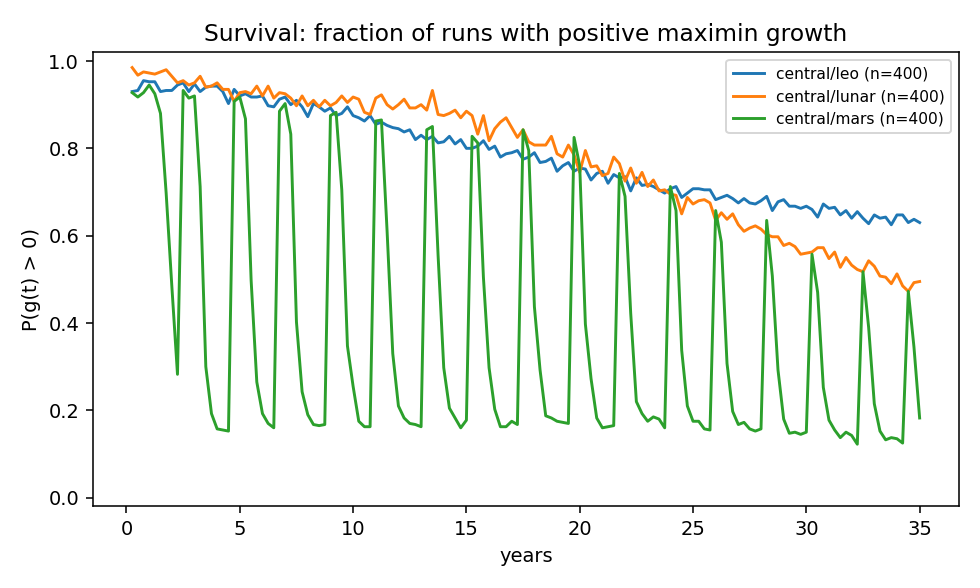

Survival curves, central assumption set: fraction of runs with positive realized maximin growth over time, by architecture. Ensemble frequencies under the stipulated assumption set, not empirical probabilities.

Balanced doubling is faster on the Moon but the endpoint is more durable in LEO: among runs that ever reach λ ≥ 2, the central median is 5.0 years on the Moon versus 26.0 in LEO. These are balanced-capacity first passages, not construction records for complete second factories. LEO has no ore body, so growth is throttled by captured and recovered material. Recycling yield is below unity and recovery now depends on loss type; recycling alone cannot fund net expansion. The LEO Earth-import-cut row therefore preserves capture feed and must not be described as autonomy. The lunar surface has regolith feed and can grow quickly when electronics permits, while the finite-response diagnostic assigns about 96% of central lunar co-binding credit to electronics. The spread is the result: current evidence does not close feasibility, but the model identifies the conditional measurements that would.

**Cut sets and the ensemble-frequent minimum cut.** At central anchor values no import cut set is fatal by year 30 anywhere — imports accelerate but are not load-bearing *at central values*. That statement misleads alone, because cuts appear near the feasibility margin. Over sampled anchors (n = 40 draws per cell), conditional on an otherwise-expanding draw, central lunar electronics and the all-import cut coincide in this regeneration; central LEO is more exposed to the feed loop as a whole than to electronics alone; and the small central Mars survivor set produces no fatal candidate cut in this regeneration. Exact conditional frequencies have moved materially across equally valid small-n regenerations. They are reported in `outputs/report_deep.md` for reproducibility, but the defensible claim is ordinal: cut dependence appears near the feasibility margin and is architecture-specific; this experiment does not estimate a stable real-world probability. Capacity knockouts at central values: the eight physical production sectors (power, mining, refining, robotics, machine tools, electronics, thermal, transport) are knockout-indispensable in both architectures tested; repair is additionally indispensable on the lunar surface. **A recorded correction (Appendix B): earlier revisions claimed recycling was knockout-indispensable in LEO. That claim came from a stale output and does not reproduce — with LEO’s 5% capture feed, a recycling knockout is survivable at central values.** What survives is the structural point: the LEO architecture lives on recovered and captured mass (capture/mining receives 98% of central co-binding credit), so its dependency is the feed loop as a whole rather than any single import line.

**The clock-setting curve.** Expansion frequency against the e-folding time of Earth-supply withdrawal (n = 60 per grid point; machine-readable: `outputs/tables/import_decay_deep.csv`): on the lunar surface under central assumptions, the realized year-30 endpoint is 0.40, 0.57, 0.43, 0.57, and 0.73 at 4-, 7-, 10-, 15-, and 25-year e-folding times. The non-monotonic wobble is within binomial noise at this n. The experiment is suggestive of a penalty for withdrawing the umbilical faster than the closure ramp, with electronics stockpile shelf life as a plausible mechanism. At $n=60$ per point it does not estimate a stable response curve or its steepness.

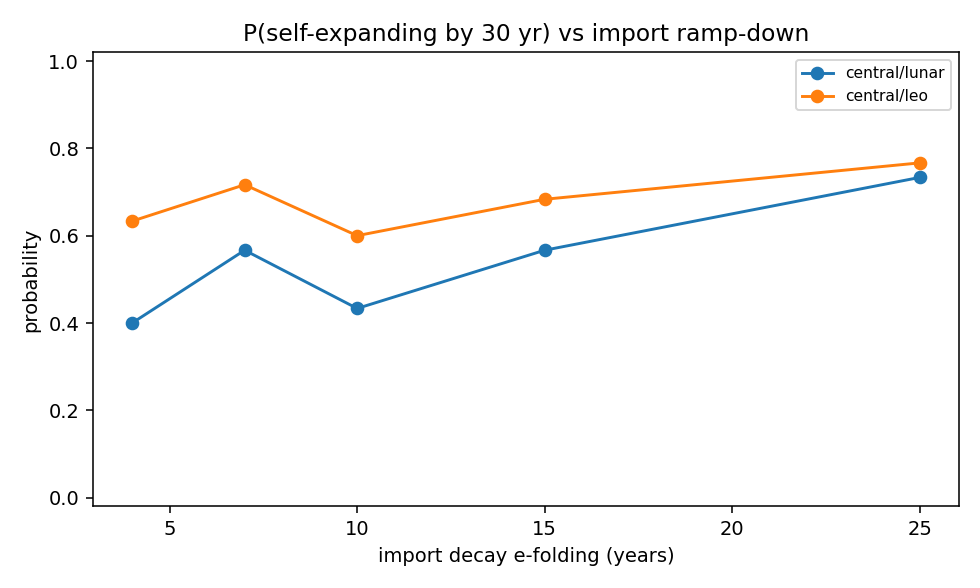

Expansion frequency at year 30 versus the e-folding time of Earth-supply withdrawal, central set, n = 60 per grid point. The wobble is within binomial noise at this n.

**Allocation-policy robustness.** The results above could in principle be an artifact of the myopic one-step maximin allocator — a forward-looking operator might accept lower current worst-case growth to build future capacity. Because the dynamics and balances are linear, the finite-horizon LP is solved exactly — though receding-horizon control remains an approximation to full-horizon optimization (truncation and terminal-value effects persist; an investment paying off after year six is invisible to a six-year window). On paired draws (identical parameter samples per policy, shocks off), a six-year receding-horizon maximin reproduces the myopic policy essentially exactly — 16/30 vs 16/30 sampled runs expanding on the lunar surface, 11/30 vs 11/30 in LEO, with co-binding shares computed under the same finite 1% response definition as the baseline. The absolute level is not stable at this small paired n — the lunar count has swung across equally valid regenerations, so the policy *equality* is the stable finding, not the level. The agreement holds because the maximin criterion already directs each step’s investment at the worst-off sector, which is the future bottleneck. A third policy, maximizing aggregate growth subject to no sector shrinking, collapses (0/30 in both architectures): worst-case allocation is load-bearing, not incidental. Bottleneck-first heuristics are subsumed by the maximin construction itself. The defensible conclusion is correspondingly scoped: under paired, shock-free draws for the tested LEO and lunar central cases, a six-year receding horizon did not materially change the outcomes; global allocation-policy robustness (longer horizons, perfect foresight, robust control under shocks) is not established — and the retooling analysis of Part IV exhibits one regime where allocation family genuinely matters. (`policies.py`; paired-draw comparison in `outputs/report_deep.md`.)

**Scalar-anchor sensitivity screening — with its scope stated.** The claim that the vitamin gap and logistics penalty dominate is a computation, not an assertion, and it is a *scoped* one — central assumptions, lunar architecture, shocks off, scalar anchors only; it does not rank structural requirement-matrix uncertainty, policy choices, shock distributions, or interaction effects, and repeating it across environments and sets with interaction-capable methods remains open cross-environment work: Spearman rank correlation between each anchor’s shared draw and the worst-case growth rate at year 30 across the ensemble (n = 300, central/ lunar, shocks off; anchors are drawn independently, so per-anchor rank correlation needs no independence corrections beyond the null band of roughly ±0.11, wider under multiplicity). Two parameters tower above the band: the space-electronics closure fraction (ρ ≈ +0.80) and the space logistics penalty (ρ ≈ −0.48) — both ASSUMPTION-class, which is the epistemic point: within this scalar screen, variation in year-30 growth is dominated by exactly the two numbers no one has measured. Every other screened anchor sits at or near the null band. (`montecarlo.sensitivity`; ranked table in `outputs/report_deep.md`.)

**Fourth Edition seed and reproduction results.** The new layer is a second, explicitly assumption-class model, not a relabeling of the inherited balanced-capacity runs. Structurally it is a two-stage hybrid: a multisector, multi-material seed-sizing LP, followed by an aggregate reproduction pass that advances a continuous count of operating cell-equivalents through construction and commissioning lags — the 18-sector detail constrains seed sizing but does not persist into the reproduction dynamics (sector-resolved reproduction is queued, ROADMAP). A scenario is **model-feasible** when the seed LP admits a solution satisfying every material, service, autonomy, intervention, and throughput constraint over the scenario horizon. The reproduction metric is **first passage to two operating-cell equivalents** — a continuous aggregate crossing, not a discretely commissioned second factory — with the year-40 column showing whether reproduction was durable. Central deterministic scenarios and deterministic 200-draw assumption ensembles:

| bootstrap architecture | central minimum-mass installed seed | Earth vitamin stock (share of seed) | first passage to two cell-equivalents | cell-equivalents, year 40 | model-feasible draws | feasible-draw seed p10 / p50 / p90 |
| --- | --- | --- | --- | --- | --- | --- |
| terrestrial closure rehearsal | 206.7 t | 48.1 t (23%) | 9.2 yr | 1.93 | 83/200 | 171 / 201 / 228 t |
| lunar vitamin bridge | 216.7 t | 58.1 t (27%) | 11.2 yr | 2.29 | 126/200 | 181 / 212 / 247 t |
| strict lunar-only | infeasible | — | — | — | 0/200 | — |
| Moon–asteroid network | 185.5 t | 0.0 t | 22.8 yr | 12.55 | 187/200 | 155 / 204 / 310 t |

“Minimum-mass installed seed” means minimum *installed operating* mass inside the declared linear seed architecture: the LP sizes a seed that is already unloaded, sited, powered, calibrated, and operating — delivery, unpacking, site preparation, and first commissioning are outside the model — and it is not a global optimum over unknown processes, designs, or objectives (a mass-versus-reproduction-time frontier is queued, ROADMAP). The vitamin share is worth stating plainly: at 27% of installed mass, the central lunar bridge is a substantially Earth-provisioned seed whose local loop supplies bulk mass, not a nearly closed system with trace imports. The year-40 column carries the transient-versus-durable distinction: the terrestrial rehearsal crosses two cell-equivalents at 9.2 years yet holds only 1.93 at year 40 — reproduction occurred once and was not durably retained — the lunar bridge barely grows past its first reproduction (2.29), and only the Moon–asteroid case compounds. The vitamin stock’s composition is resolved in `outputs/fourth/tables/vitamin_composition.csv`: Ni, Cu, and C dominate at roughly 80% of the lunar-bridge stock, with initial-rate coverage near five years per category.

The strict lunar-only case is a structural infeasibility, not a sampled tail: the central LP is infeasible — the configured trace-material yields cannot supply the assumed electronics and process-equipment stack — and all 200 draws preserve that infeasibility, so 0/200 restates the structure rather than measuring an uncertainty. Substitution, a different electronics stack, a new refining route, or a richer measured deposit can change it; the result is not a proof that lunar-only industry is impossible. The Moon–asteroid case assumes a deliberately synthetic composite portfolio rather than a known accessible body: 187/200 states what a sufficiently diverse source network would have to supply, not that such a portfolio is accessible, jointly recoverable on the assumed timetable, or economical. In its central solution the Moon supplies 366.2 t/yr of feed and the asteroid portfolio 173.8 t/yr. Source occurrence [S51–S56] bounds plausibility; it does not validate recoverable yield, reserve, throughput, purity, or transfer cost.

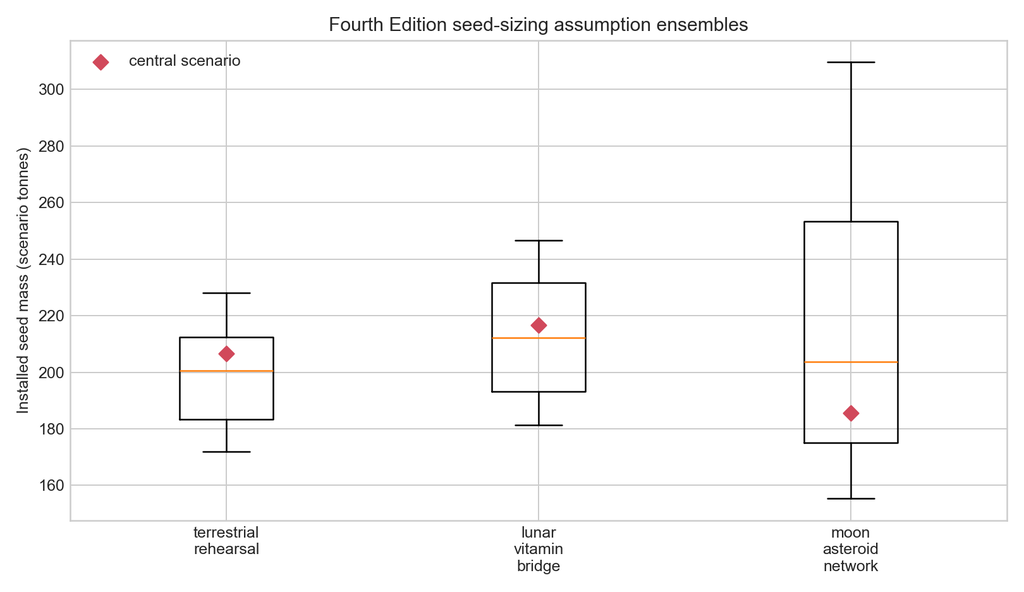

Installed seed mass across the 200-draw assumption ensembles, by scenario. Distributions describe the declared parameter box, not engineering uncertainty.

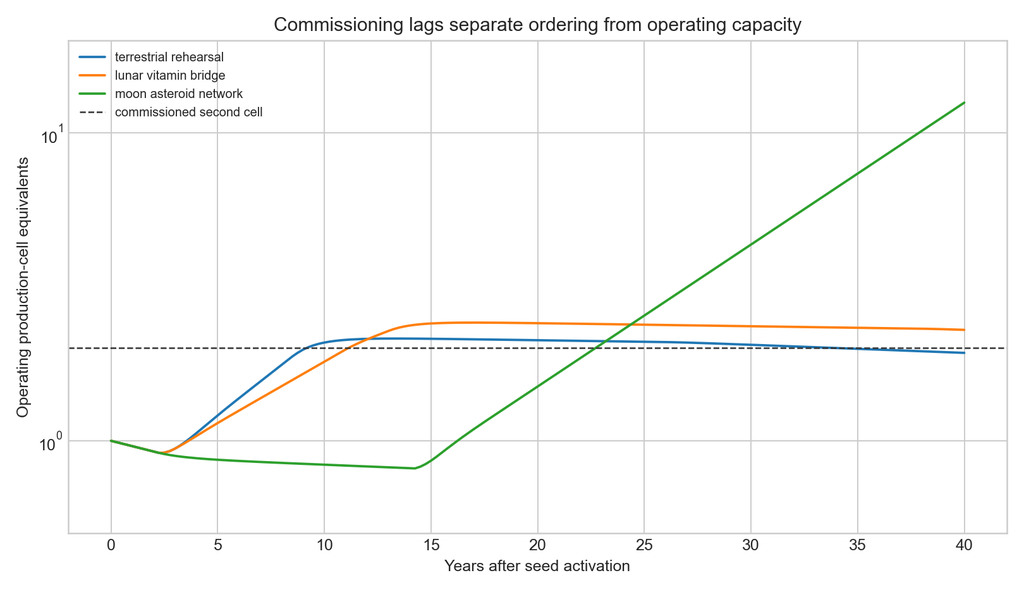

Operating cell-equivalents over time in the central scenarios: construction and commissioning lags separate ordering from operating capacity.

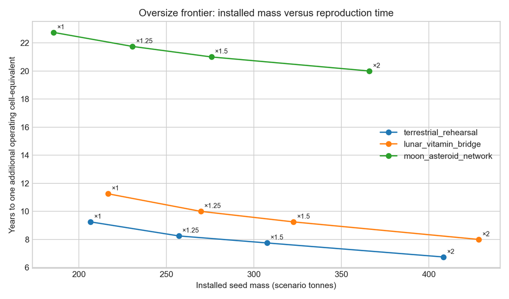

Oversize frontier: installed seed mass versus years to one additional operating cell-equivalent, central scenarios.

The coupled run distinguishes installed compute from the industrial stock that manufactures it. At year 40, the Moon–asteroid scenario has 12.55 normalized total endogenous compute capacity — numerically identical to its cell-equivalent count by construction, since endogenous compute is proportional to operating cells and normalized to the one-cell start — and exports 1.63 units to orbit. Constant-rate Earth-fed orbital deployment reaches 1.56, 2.81, or 4.99 units under the tight, base, and responsive rate cases. Those curves show the difference between rate-limited deployment and endogenous reproduction under the configured coefficients; they do not forecast datacenter capacity.

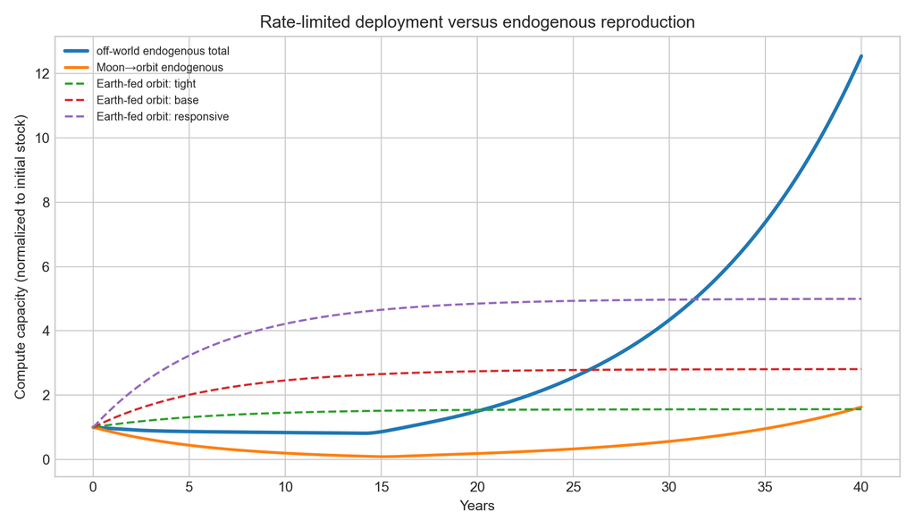

Rate-limited Earth-fed deployment versus endogenous reproduction, normalized compute capacity under the configured coefficients.

The stateful debris stress test reports the **five-year fragment creation-to-clearance ratio** $R_{\mathrm{debris}}$ — fragments created divided by fragments cleared over the final five years, a flow ratio rather than a branching-process reproduction number:

| deployment topology / mitigation | creation-to-clearance ratio, last 5 yr | fragment index, year 40 |
| --- | --- | --- |
| Earth-fed orbit / weak | 0.61 | 1.602 |
| Earth-fed orbit / strong | 0.35 | 0.284 |
| dense endogenous / weak | 5.53 | 16.497 |
| dense endogenous / strong | 5.58 | 12.632 |
| distributed endogenous / sparse topology | 1.00 | 0.000 |

A ratio above one means only that more fragments were created than cleared in the window; it is not a monotonic safety indicator. Strong mitigation lowers the dense case’s fragment stock (16.5 → 12.6) while the flow ratio stays essentially unchanged, because clearance scales with the shrinking fragment population. The sparse case reads exactly 1.00 with an empty stock because realized clearance is capped by the fragments available — a zero-stock boundary, not a computed equilibrium — and it reaches that boundary only under an assumed 0.01 collision-kernel multiplier. The result supports topology as a co-designed industrial constraint; it does not establish a safe orbit, validate a debris environment model, or locate a cascade threshold. Complete tables and figures are generated from the same run in `outputs/fourth/`.

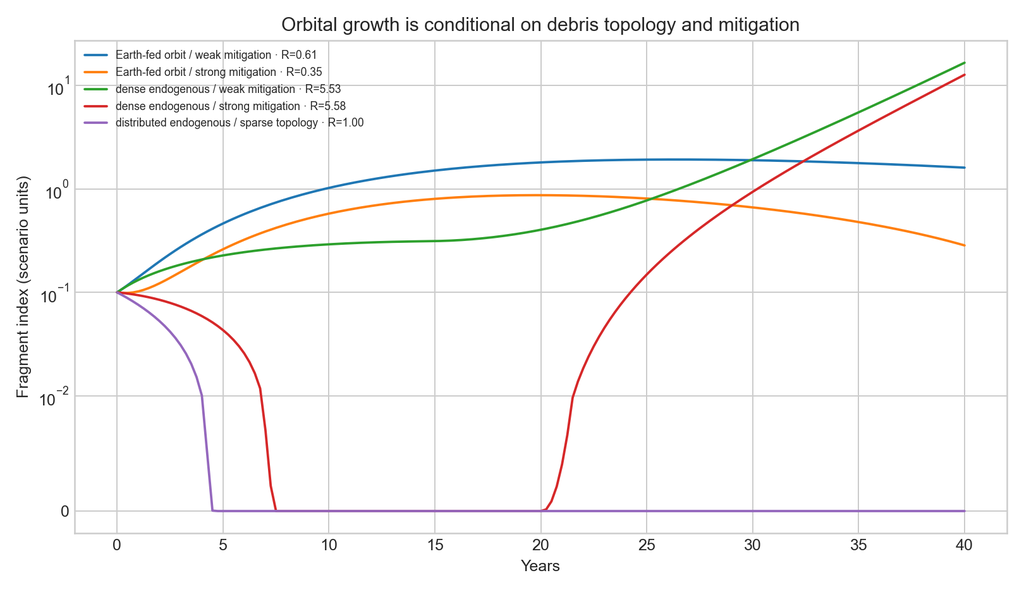

Fragment-index trajectories by deployment topology and mitigation: the debris stress test that produces the creation-to-clearance table above.

**What Part I establishes and does not.** It establishes structure: which sector binds, what the minimum cut is, how locations differ qualitatively (lunar fastest-doubling but hostage to the electronics cut; LEO feed-constrained but recycling-viable; Mars most path-dependent and import-fragile — r3.5 drops the earlier “most robust per unit of assumption-optimism” ranking, which had no defined normalization), and where the feasibility margin lies — structure that survives the allocation-policy variation above. The Fourth layer additionally establishes which declared material, autonomy, gravity, source, and commissioning constraints explain its own seed scenarios. Neither establishes point feasibility: both requirement matrices, element recipes and yields, vitamin gap, repair efficiencies, stockpiles, autonomy coefficients, lags, source portfolio, and shock/debris rates are ASSUMPTION-class. Solar-array, regolith, sample, or satellite data do not establish the coupled behavior of mines, bearings, machine tools, electronics production, or dust-exposed radiators.

## I.9 Development path, annotated

0. **Terrestrial autonomous-closure rehearsal.** Before launch, operate an integrated seed factory on Earth using only the material forms, energy intermittency, communications constraints, spares allowance, and production methods intended for the lunar deployment. Exclude routine human entry; route every human intervention through a logged maintenance interface; inject equipment faults and communication outages; and require the system to manufacture, assemble, calibrate, and commission a second production cell. This stage does not reproduce lunar gravity, vacuum, radiation, or abrasive dust, so environmental qualification remains separate. It does test whether the industrial graph and its encoded operating knowledge are autonomous enough to export. Report intervention hours per machine-hour, imported mass per unit of added local capacity, critical bill-of-material lines producible, autonomous recovery fraction, time to a commissioned second cell, and every remaining single-point dependency.
1. **Earth-dependent operations.** Earth supplies vehicles, energy systems, consumables, spares, electronics, and nearly all machinery; space assets perform narrow missions.
2. **Local-resource supplementation.** Local water, oxygen, shielding, construction feedstock, and selected propellant inputs reduce imported mass without yet closing the industrial loop.
3. **Heavy-industry closure.** The network produces bulk metals, glass, ceramics, structural parts, tanks, simple mechanisms, roads, pads, and large power structures.
4. **Advanced-manufacturing closure.** It adds motors, actuators, sensors, precision tools, robots, spacecraft subsystems, computers, and factory machinery. Terafab is best read as a terrestrial rehearsal of this stage (Part III.2): advanced-manufacturing integration practiced on Earth before any attempt to export it.
5. **Self-sustenance.** Internal production replaces depreciation and failure across every mission-critical category; Earth supply becomes optional rather than load-bearing.
6. **Self-expansion.** The system builds more mines, refineries, factories, power systems, robots, transports, and compute than replacement requires.
7. **Intelligence-industry recursion.** Additional compute improves intelligence; improved intelligence raises industrial replication efficiency; higher output creates still more compute.

   I increases → replication efficiency increases → infrastructure increases → compute increases → I increases

The bridge economy maps onto the ladder: terrestrial products carry the early stages; launch and connectivity carry Stages 2–4; orbital compute is a candidate Stage 4–5 tread; and in-space industrial services carry Stages 5–6. The model adds stage warnings. The Stage 4→5 transition is where the vitamin gap binds — no amount of Stage 3 bulk closure substitutes for an electronics tier. Stage 5 is location-dependent: LEO requires a sustained capture-and-recovery feed loop; under the present 5% capture assumption, recycling is valuable but not knockout-indispensable at central values. Mars requires electronics stockpiles engineered to synodic shelf life or a local electronics tier. The lunar surface has the fastest conditional balanced-doubling pathway when electronics closes sufficiently; LEO has the more durable central endpoint under its continuing-capture assumption.

**Location sequence and the lunar hybrid.** The development ladder is not a ladder of orbital altitudes. In particular, *Sun-synchronous orbit* is a planet-centered orbit whose plane precesses to preserve approximately the same local solar time [S49]. The familiar dawn-dusk SSO is still LEO—the 650 km orbital-compute design assessed in Part II is an example—not the destination after a lunar surface base.

For closure, the more coherent topology is:

1. **LEO as a bridge, not the terminal reservoir.** Communications, observation, early compute, assembly demonstrations, and transport can earn revenue and test systems, but bulk growth remains exposed to finite imported/captured feed and density-dependent collision risk.
2. **Lunar surface as the material backbone.** Extraction, bulk refining, construction, durable storage, shielding, and long-life machinery use a physical foundation and local regolith. South-polar planning seeks the conjunction of long illumination intervals and access to shadowed volatile deposits, while leaving reserve size and extraction economics unresolved; dust and landing ejecta remain major surface penalties [S47].
3. **Sparse lunar/cislunar orbit as the service layer.** Communications, navigation, observation, reusable transports, depots, assembly, and selected compute occupy orbit only where zero-g or illumination benefits repay shielding, stationkeeping, and service costs. NRHO is a candidate gateway geometry designed for eclipse avoidance and low stationkeeping, not a substitute ore body or a passive maintenance-free base [S48].
4. **Distributed heliocentric expansion after lunar export closure.** Productive nodes then spread across separated Sun-orbiting trajectories and resource paths—potentially including near-Earth objects—rather than reproducing one dense shell. The point is diversity of orbital elements and feedstocks, not one privileged “solar orbit.” Moving inward raises solar flux but also heat-rejection, radiation, communications, and materials constraints, so no optimal solar radius is claimed.

**Material-source sequence.** The Moon is not chemically equivalent to Earth, but neither is it short of bulk machine-building elements. Its crust is dominated by oxygen, silicon, magnesium, iron, calcium, and aluminum, with smaller titanium-bearing and other phases; composition varies strongly between highlands and mare terrains [S51]. Those elements support oxygen, glass and ceramics, aluminum, iron-bearing alloys, silicon feed, shielding, structures, and many bulk machine parts, subject to extraction energy, purification, alloying, yield, and process-equipment constraints. The early system can therefore treat the lunar surface as a **bulk-material backbone** while importing low-mass, high-criticality **material vitamins** from Earth: advanced chips, dopants, catalysts, specialty chemicals, bearings, sensors, precision tools, metrology, and any alloying elements whose local recovery is not yet viable.

An order-of-magnitude inventory check prevents “no iron” from becoming a false premise. At an average regolith bulk density near 1.5 t/m³ [S52], one square kilometer excavated to one meter contains about 1.5 million tonnes of regolith. Applying the approximately 3 wt% iron reported for lunar highlands material [S53] gives roughly 45,000 tonnes of iron **in place**. This is an illustrative inventory, not an ore reserve: it says nothing about site homogeneity, mineral form, excavation losses, energy, recovery yield, environmental impact, economics, or how much is practically extractable. It does show why asteroid mining is not a prerequisite for initial lunar iron.

The harder question is diversity. Lunar carbon and nitrogen occur at low concentrations in returned fines, while polar water evidence remains spatially heterogeneous and does not yet provide a bankable reserve estimate [S54, S55]. A robot-only ecology avoids agricultural and biosphere-scale demand, but it still uses volatiles and specialty elements for propellant, reduction chemistry, cooling, lubrication, polymers, process gases, electronics, and high-performance alloys. Carbonaceous asteroids and differentiated metal-rich bodies can eventually add water, carbon-bearing material, nickel, cobalt, and other feedstocks; returned Bennu material confirms carbon-rich organics and a history of water-related mineral chemistry in at least one carbonaceous body [S56]. Asteroids are therefore modeled as a **follow-on route to diversity and supply sovereignty**, not invoked as the first source of every machine metal.

Current demonstrations make individual conversion paths more concrete without closing the system. NASA describes integrated autonomous processing of regolith simulant into silicon solar cells, aluminum wire, oxygen, iron, and slag, alongside vacuum tests of molten-regolith electrolysis [S57]. These are meaningful subsystem demonstrations; they are not a lunar mine, an operational supply chain, a factory reproducing its own equipment, or an audited second production cell.

This ranks functions, not prestige destinations. Surface and orbit are complements: orbit is the transfer and service network; the surface supplies bulk matter and shielding. The inherited ten-sector and Part II models cannot compare that hybrid directly: they isolate lunar-surface capacity, cislunar compute, and Earth-supplied lunar compute, and they aggregate elements into industries. The Fourth layer adds material-category bills of material, source yields, Earth–Moon–orbit–asteroid arcs, and aggregate endogenous debris states. It therefore computes an explicit hybrid scenario, but its recipes, yields, transfer capacities, composite asteroid source, and collision kernels are declared assumptions. It does not establish lunar material sufficiency, a recoverable reserve, a launch date for asteroid supply, or an orbital safety case.

## I.10 Binding bottlenecks and failure modes

With model annotations:

- **Lithography and fabrication equipment** — the named residual chokepoint one layer below foundries, and the deepest single closure problem in this framework.
- **Reliability and repair** — the model makes mean-time-to-repair and spares closure first-class: repair is an explicit sector with an efficiency and a spares bill.
- **Thermal management** — radiators are launched mass; Part II’s radiator axis.
- **Energy storage and continuity** — the lunar night storage mass term; Mars dust-storm shocks.
- **Resource quality** — LEO has no ore body, so the sustained capture-and-recovery feed loop binds even though the separately modeled recycling sector is not knockout-indispensable at central values.
- **Verification and control** — Part III.4.
- **Political and legal environment.**
- **Economic survival of the transition** — Part II.1.
- **Concentrated coordination** — single points of failure a distributed competitor lacks.
- **Paradigm-shift stranding** — Part IV.3; exposure concentrated in the fabrication layer, while the fleet self-insures through its own 3–6-year depreciation.

# Part II — Comparative Economics

## II.1 The bridge economy

Each stage of the recursion must be independently profitable or deliberately financed: a staircase of self-supporting steps, not a single leap to closure. The plausible treads, in order: terrestrial products of the same machinery (vehicles, storage, robots — the ground floor pays rent **and** turns the autonomous seed into an audited industrial experiment); launch and connectivity (Starlink revenue and launch services fund transport); orbital compute services — a candidate tread, *now priced rather than merely doubted* (II.2–II.4); and in-space industrial services at higher closure. The test of the staircase: at every stage, revenue plus strategic financing must exceed the burn required to reach the next stage before the clock-setting components of Part I.4 expire — and Part I.8 makes the clock concrete: the electronics stockpile shelf life against the import ramp.

Stage 0 has a second economic role. Building the candidate lunar industries first on Earth captures process knowledge, failure data, tool interfaces, simulation residuals, and commissioning procedures while the repair economy is still accessible. Selling terrestrial output can finance that learning, but the decisive deliverable is the measured ability to build and commission a second cell under lunar-palette and no-routine-entry constraints. A factory that is profitable yet requires tacit human rescue has not validated the exported loop.

## II.2 The crossover model

Unit: **dollars per frontier-equivalent kilowatt-year of delivered IT load** — defined as one kilowatt-year of IT electrical load powering accelerators of frontier-generation efficiency, delivered at the case’s utilization; older-node capacity is converted by its J/FLOP penalty, so a frontier-equivalent kilowatt-year buys the same computational output regardless of which hardware generation supplies it. Three reference cases: a LEO inference service; high-orbit/cislunar batch compute; and Earth-supplied lunar-surface compute, with local manufacture entering only through the closure sweep. Mass and power budgets resolve from anchored ranges — launch price sheets (company_statement), flexible-array specific power and deployable-radiator specific mass (technical_report), accelerator system cost and lives (reporting), DC capex, PUE, WACC (reporting), qualification multiplier and utilization (ASSUMPTION, evidence-tempered) — each with a source class and per-run provenance. The space cost is affine in launch $/kg, so break-even launch prices are exact. Chip efficiency is a first-class parameter: off Earth, every watt not computed must be radiated, and radiator, PV, storage, and structure are launched mass, so a FLOPS/W advantage scales the entire power side per unit of delivered compute — efficiency and launch price enter the crossover multiplicatively, with a quantitative refinement below. This makes the popular framing of orbital compute as a launch-price race incomplete and supplies a thermodynamic rationale for internalizing chip *design*, not merely fabrication or supply security: the most efficient accelerator can tolerate a higher launch price because it carries less power and heat-rejection mass per useful computation.

Two lifecycle architectures are reported separately:

- **Integrated disposable satellite:** compute, PV, radiator, storage, structure, and original launch spend retire together.
- **Serviceable/reusable platform:** the compute payload refreshes on its hardware life while the power/thermal/structure platform and its original launch spend amortize over a longer infrastructure life. This is an explicit scenario assumption; modularity alone does not demonstrate serviceability.

For WACC $r$, useful life $T$, and annual operations fraction $f_o$,

$$\operatorname{CRF}(r,T)=\frac{r}{1-(1+r)^{-T}},
\qquad
a(T)=\operatorname{CRF}(r,T)+f_o.$$

Let $C_h$ be qualified accelerator capex, $C_I$ the sum of PV, radiator, and storage capex, $M_h$ accelerator mass, $M_I$ launched non-hardware mass after local closure, $\mu$ the destination launch multiplier, $p_L$ the LEO launch price, and $U_s$ delivered utilization. The complete space expression is

$$L_s =
\frac{C_h a(T_h)+C_I a(T_I)
+p_L\mu[M_h a(T_h)+M_I a(T_I)]}{U_s}
=\alpha+\beta p_L.$$

The integrated-disposable case sets $T_I=T_h$. The serviceable/reusable-platform case sets $T_I=\max(T_{I,\mathrm{anchor}},T_h)$. For Earth scenario $e$, PUE $\psi_e$, electricity price $p_e$, data-center shell capex $C_{DC}$, utilization $U_E$, and frontier-equivalent node penalty $\phi_e$,

$$L_E =
\frac{\phi_e\left[
C_{h,e}\operatorname{CRF}(r,T_{h,e})
+C_{DC}\operatorname{CRF}(r,15)
+8760p_e\psi_e\right]}{U_E}.$$

The responsive Earth case evaluates frontier and older-node hardware and selects the lower $L_E$. Because $L_s$ is affine in launch price, the exact break-even is

$$p_L^*=\frac{L_E-\alpha}{\beta};$$

a negative value means non-launch costs alone exceed the Earth counterfactual.

For the central LEO serviceable-platform case, $C_h=\$63{,}640/\mathrm{kW}$, $C_I=\$1{,}697/\mathrm{kW}$, $M_h=17.3$ and $M_I=28.8\ \mathrm{kg/kW}$, $p_L=\$2{,}366/\mathrm{kg}$, $a_h=0.3237$, $a_I=0.1704$, and $U_s=0.786$. Substitution gives

$$L_s =
\frac{63{,}640(0.3237)+1{,}697(0.1704)
+2{,}366[17.3(0.3237)+28.8(0.1704)]}{0.786}
=\$58{,}264/\mathrm{kW\!-\!yr}.$$

A fourth, explicitly conditional **Starmind AI1 disclosure scenario** does not replace those references. SpaceX publishes a 150 kW peak / 120 kW average compute payload, 150 kW solar array, 70 kW/tonne vehicle efficiency, 110 m² liquid radiator, and deployed dimensions of 20 by 70 m [S38]. The model uses the array/average-load ratio of 1.25. Because the page does not say whether the 70 kW/tonne numerator is peak or average, aggregate vehicle mass is sampled over the derived **14.3–17.9 kg per average kW** range and the direct disclosures retain `company_statement` provenance while the interpretation range is labeled `ASSUMPTION`. Radiator area, dimensions, redundant loops, shielding, and laser links are recorded but receive no invented mass or cost where none is disclosed. Hardware cost, qualification, life, achieved availability, and launch price retain the existing anchors.

The lifecycle split is explicit and assumption-class. AI1 publishes only aggregate vehicle mass, so the model first constructs the generic accelerator/PV/radiator/storage/structure mass budget and then scales every component by one common factor until its sum equals the sampled AI1 total. The resulting generic **hardware-versus-infrastructure proportion** assigns accelerator mass to the hardware refresh life and the balance to the infrastructure life in the serviceable case; the disposable case amortizes both on the hardware life. Capex is not inferred from vehicle mass: qualified generic accelerator capex is retained, while generic PV, radiator, and storage capex is evaluated at AI1’s disclosed 1.25 array-to-average-load ratio. The aspirational 10 kg/kW case uses the same proportional split. Neither that mass decomposition nor physical serviceability is disclosed by SpaceX; both are `ASSUMPTION`, and the serviceable AI1 and 0.76× boundary depend on them.

A fifth case is a deliberately optimistic, deterministic boundary rather than a new baseline: **Starmind AI1 aspirational best case**. It uses SpaceX’s formal ≥99% launch-cost-reduction target as **$185/kg** and the prospectus’s long-term **100 kW/t** orbital-compute scaling assumption (10 kg per average kW) [S37]. Because the company does not publish achieved AI1 qualification cost, useful life, or compute availability, the case separately labels as `ASSUMPTION` the favorable existing model bounds: 1.2× qualification, seven-year hardware life, and 0.95 utilization. It is excluded from Monte Carlo. Treating a target and three selected favorable bounds as probability distributions would manufacture a spurious probability of success.

**Post-IPO architecture calibration.** The technical literature available by late July 2026 does not supply one new “correct” mass-to-power ratio. It separates three architectures that should not be blended into one Monte Carlo distribution. Turyshev’s independent 1 MW high-sunlight closure allocates 29.4 kg/kW to PV, storage, and radiators; fixed spacecraft functions raise the total to **34–59 kg/kW** [S39]. This independently brackets the model’s 46 kg/kW central generic LEO case and supports its order-of-magnitude placement, although the model’s full component-corner envelope (about 25–91 kg/kW) is wider. AI1’s derived 14.3–17.9 kg/kW sits below that conventional envelope and remains a separate company-specification case. Below both are research architectures: an integrated solar-compute-radiator panel concept at about **8.9 kg/kW** and a tethered inference architecture at about **5 kg/kW** [S40]. Those figures are legitimate lower-bound scenarios, but depend respectively on kilometer-scale integrated arrays, unqualified vapor chambers, thin tandem PV and custom ASICs, or on long tethers, distributed deployment, shielding, station-keeping, and micrometeoroid tolerance. They are pre-prototype architecture claims, not evidence that the generic spacecraft prior should move to 5–10 kg/kW.

**Thermal closure is a system, not a radiator-panel coefficient.** NASA’s flight and mission studies distinguish 2.75 kg/m² ISS radiator panels from **8.8 kg/m²** after fluid loops and deployment are included; a JIMO study estimated **5 kg/m²** for the complete system. At 353 K radiator temperature, 0.86 emissivity, and a 173 K environmental sink, the cited sizing is about 1.4 m²/kW, implying roughly **7–12 kg/kW** for the complete heat-rejection system [S43]. This supports the middle and upper part of the model’s 3–12 kg/kW range, but shows that its low end represents advanced emitters, not a demonstrated full stack of cold plates, pumps, transport lines, deployment, and controls.

AI1 makes the ambiguity visible. Its published 110 m² radiator for 120 kW average compute is 0.92 m²/kW of quoted area [S38]. If 110 m² is physical footprint and both faces emit, the mean flux is about 545 W/m²; a simple Stefan–Boltzmann balance using NASA’s emissivity and environmental temperature gives an ideal radiator surface near 332 K (59 °C). If 110 m² instead denotes total emitting area, the load is about 1,090 W/m² and the ideal surface approaches 391 K (118 °C). Both calculations omit solar and Earth view, degradation, nonuniformity, pumping power, and the chip-to-coolant-to-radiator temperature drop. The disclosure is therefore not thermodynamically impossible, but its area convention, coolant temperature, and full thermal-system mass are crossover-critical measurements.

The terrestrial counterfactual **responds** — the epistemic requirement earlier editions missed. Three scenarios: *tight* prices scarcity (the politics-binds branch: permitting and climate commitments hold); *base* takes the anchors; *responsive* prices induced supply at the cheapest permitted firm-power floor — nuclear PPA, or the politically conditional natural-gas floor at $0.04–0.06/kWh (CCGT under $1,000/kW, ~2-year builds [S35]) — with an older-node hardware option taken when it wins on compute-normalized cost. Aspirational launch targets are sweep axes except in the explicitly labeled deterministic best case above; they never enter the probabilistic baseline.

**Starship V3/V4 aspiration, normalized.** SpaceX’s June 2026 prospectus does not quote a V3 or V4 customer price or a vehicle-specific cost per flight. It states instead that fully reusable V3 is designed to carry 100 metric tonnes to orbit, that a future generation could reach 200 tonnes as soon as V4, and that mature Starship is intended to reduce the historical $18,500/kg cost benchmark by 99% or more [S37]. Exactly 99% implies **$185/kg**; “or more” implies a lower value. The table converts that formal aspiration and three more aggressive sensitivity cases into full-payload flight-cost equivalents:

| LEO sensitivity case | $/kg | V3: 100 t full-load equivalent | V4: 200 t full-load equivalent | status |
| --- | --- | --- | --- | --- |
| formal corporate aspiration | ≤$185 | ≤$18.5M | ≤$37M | derived from the stated ≥99% reduction; not a price quote |
| aggressive mature-Starship case | $100 | $10M | $20M | scenario axis |
| extreme fuel-like case | $50 | $5M | $10M | scenario axis |
| extreme lower case | $30 | $3M | $6M | scenario axis |

The dollar-per-flight columns are arithmetic (`$/kg × full payload`), not company forecasts. They rise for V4 in the table because $/kg is being held constant while payload doubles. Holding flight cost constant gives the other useful comparison: a $10M flight is $100/kg on a full V3 and $50/kg on a full V4. Under-filled flights cost more per delivered kilogram; external customer prices can exceed internal marginal cost; and none of these figures includes a demonstrated cadence, reuse count, refurbishment burden, or capital-recovery schedule. This edition therefore uses **$185/kg as the traceable corporate aspiration, $100/kg as an aggressive case, and $30–50/kg only as an extreme fuel-like sensitivity band**. All remain comparison axes; $185/kg also enters the quarantined deterministic best case, never the Monte Carlo.

Two financing caveats are deliberate modeling choices, stated openly: a single WACC range (8–15%) applies to *both* sides — equalized financing is an assumption in favor of space, since an unprecedented orbital constellation would not price like a mature terrestrial data center — and the qualification multiplier, service life, and utilization are sampled independently, although the favorable corner (cheap qualification, long life, high utilization) likely involves correlated engineering assumptions; both refinements are queued (ROADMAP). Calibration: the Earth base case works out to ≈$1.7/kWh, matching published accelerator rental rates.

**Cost accounting — included and excluded.** Included: IT hardware with qualification premium; PV, radiators, storage, structure and their launched mass (with cislunar/lunar delivery multipliers), while structure itself is only a mass proxy and has no separate construction price; capital recovery at WACC with component-specific lives — compute hardware and its replacement launch mass on the refresh cycle, infrastructure and its launch spend on a separate 10–25-year ASSUMPTION-class range (r3.5); an operations fraction (2–6% of capex/yr) standing in for ground segment, downlink, and station-keeping in the serviceable-platform case, or all of those assets on the compute life in the integrated-disposable case; utilization derating; Earth-side DC capex, PUE, and firm-power floors. Excluded: spacecraft-bus, structure, harness, avionics, integration, and qualification manufacturing cost beyond the component prices above; complete thermal transport beyond the radiator coefficient; communications-terminal and ground-network capex; development and non-recurring engineering; launch-site, landing, turnaround, and fleet infrastructure beyond whatever is implicit in the $/kg target; launch failure and insurance; redundant provisioning beyond the life derating; collision-avoidance operations beyond the ops fraction; spectrum and regulatory costs; deorbit/disposal; residual value; and tax treatment. Turyshev’s independent inequality is consequently a stricter comparison than the current launch-only coefficient: at 40 kg/kW, a terrestrial infrastructure allowance of $10,000–40,000/kW permits only **$250–1,000/kg for launch and spacecraft build combined** before communications, operations, utilization, and finite-life penalties [S39]. The net direction of the exclusions is **not** claimed to be uniformly conservative in space’s favor (an r3.4 overstatement corrected on external review): most excluded items burden space more, but residual value and reuse of the power/thermal platform across accelerator generations would favor space, and the zero-closure lunar labeling and equalized financing are themselves pro-space simplifications. The reported multiples are therefore stylized-architecture outputs; the robust conclusion is structural — *which* terms dominate — not the exact ratios.

## II.3 Results

Central reference values plus the deterministic aspiration case ($ per kW-yr, rounded to three significant figures — these are assumption-conditioned outputs, not measurements; exact machine-readable values regenerate in `outputs/`):

| case | architecture | LCO | launched mass | vs Earth base (≈14,700) |
| --- | --- | --- | --- | --- |
| LEO inference | serviceable/reusable platform | 58,264 | 46 kg/kW | 3.97× |
| LEO inference | integrated disposable satellite | 71,901 | 46 kg/kW | 4.90× |
| cislunar batch | serviceable/reusable platform | 96,726 | 46 kg/kW | 6.59× |
| cislunar batch | integrated disposable satellite | 128,333 | 46 kg/kW | 8.75× |
| lunar surface (Earth-supplied) | serviceable/reusable platform | 2,773,476 | 454 kg/kW | 189× |
| lunar surface (Earth-supplied) | integrated disposable satellite | 5,065,254 | 454 kg/kW | 345× |
| Starmind AI1 disclosure scenario | serviceable/reusable platform | 37,483 | 16 kg/kW | 2.56× |
| Starmind AI1 disclosure scenario | integrated disposable satellite | 42,531 | 16 kg/kW | 2.90× |
| Starmind AI1 aspirational best case | serviceable/reusable platform | 11,156 | 10 kg/kW | 0.76× |
| Earth tight | — | 15,980 | — | — |
| Earth responsive | — | 12,783 | — | — |

(The integrated-disposable rows annualize *all* space capex — PV, radiators, storage, structure, and the launch spend that emplaced them — on the short compute-refresh life; the serviceable-platform rows amortize infrastructure on a separate `infrastructure_life_years` range (10–25 yr, ASSUMPTION-class with a stated bounding argument), with replacement chips and their launch mass still recurring on the compute life. Earlier revisions reported only the disposable reading; Appendix B records the change. The lunar case is labeled **Earth-supplied** because its central closure fraction is zero — local manufacture enters only through the closure sweep axis.)

Monte Carlo over anchored ranges, shared draws both sides (n = 2,000 sampled runs per row; frequencies under this ensemble, not empirical probabilities). The aspirational best case is excluded because its company targets and favorable unpublished assumptions are point sensitivities, not probability distributions:

| case | architecture | vs Earth | ratio p10/p50/p90 | space-cheaper runs | break-even $/kg p50 (p90) |
| --- | --- | --- | --- | --- | --- |
| LEO inference | serviceable/reusable | base | 2.7 / 4.2 / 6.4 | 0 / 2,000 | −844 (−132) |
| LEO inference | serviceable/reusable | responsive | 3.3 / 5.1 / 8.2 | 0 / 2,000 | −1,035 (−339) |
| LEO inference | integrated disposable | base | 3.3 / 5.1 / 8.2 | 0 / 2,000 | −606 (−124) |
| LEO inference | integrated disposable | responsive | 3.9 / 6.3 / 10.4 | 0 / 2,000 | −764 (−239) |
| cislunar batch | serviceable/reusable | base | 4.2 / 6.8 / 11.7 | 0 / 2,000 | −211 (17) |
| cislunar batch | serviceable/reusable | responsive | 5.1 / 8.6 / 14.5 | 0 / 2,000 | −299 (−49) |
| cislunar batch | integrated disposable | base | 5.3 / 9.1 / 15.8 | 0 / 2,000 | −158 (12) |
| cislunar batch | integrated disposable | responsive | 6.4 / 11.5 / 19.8 | 0 / 2,000 | −216 (−41) |
| lunar surface (Earth-supplied) | serviceable/reusable | base | 78.5 / 189.6 / 448.8 | 0 / 2,000 | −19 (−7) |
| lunar surface (Earth-supplied) | serviceable/reusable | responsive | 98.3 / 240.8 / 570.9 | 0 / 2,000 | −21 (−8) |
| lunar surface (Earth-supplied) | integrated disposable | base | 144.4 / 354.2 / 887.2 | 0 / 2,000 | −12 (−5) |
| lunar surface (Earth-supplied) | integrated disposable | responsive | 186.5 / 448.2 / 1,055.0 | 0 / 2,000 | −13 (−6) |
| Starmind AI1 disclosure | serviceable/reusable | base | 1.8 / 2.6 / 3.9 | 0 / 2,000 | −2,555 (−524) |
| Starmind AI1 disclosure | serviceable/reusable | responsive | 2.1 / 3.3 / 5.0 | 0 / 2,000 | −3,215 (−1,040) |
| Starmind AI1 disclosure | integrated disposable | base | 2.0 / 2.9 / 4.4 | 0 / 2,000 | −1,771 (−402) |
| Starmind AI1 disclosure | integrated disposable | responsive | 2.4 / 3.7 / 6.0 | 0 / 2,000 | −2,345 (−839) |

(Earth and space see the same sampled WACC and hardware cost in every draw — each anchor’s draw is cached per iteration — and the script’s seeds are stable, so the tables are deterministic across processes. Earlier revisions implemented neither property; Appendix B records the fix.)

All sixteen architecture/reference rows have zero observed successes in 2,000 draws, bounding each ensemble frequency below approximately 0.15% (95%). These are statements about this assumption ensemble, not empirical probabilities.

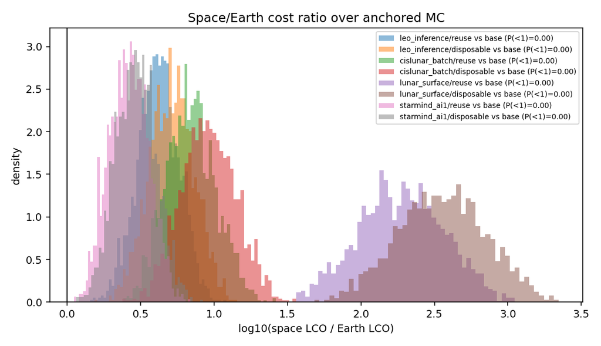

Distribution of the space/Earth cost ratio over the anchored Monte Carlo, shared draws both sides. No draw crosses parity in any architecture/reference cell.

AI1’s aggregate mass disclosure is material but not sufficient at the retained central values: it cuts launched mass from about 46 to 16 kg/kW and LCO from about $58,300 to $37,500/kW-yr, yet fixed non-launch costs still exceed Earth base (central break-even −$2,598/kg). With the remaining anchors simultaneously favorable — qualification ×1.2, seven-year life, and 0.95 utilization — AI1 is 1.28× Earth at the central published launch anchor, breaks even at about **$1,152/kg**, and reaches 0.79× at $250/kg. That moves the favorable-corner crossover close to the bottom of today’s published band, but only conditionally on performance values the AI1 page does not publish.

The aspirational case makes that conditionality explicit. The two company numbers alone—$185/kg and 100 kW/t—still produce about **$27,100/kW-yr, 1.85× Earth base** when qualification, life, and utilization remain at their central values. Selecting the three favorable non-company bounds as well produces about **$11,200/kW-yr, 0.76× Earth base**. This is the first modeled orbital-AI case cheaper than central Earth, but it is a boundary, not a forecast: all five favorable conditions must hold together, and the model assigns no probability to them.

The company’s own scale target exposes the feasibility burden. At 100 GW deployed annually and 100 kW/t, the flow is **one million tonnes/year**: 10,000 full 100-t V3 launches (27.4/day), or 5,000 full 200-t V4 launches (13.7/day), and roughly 833,000 AI1-sized 120-kW-average spacecraft. Even at $185/kg, launch cost alone is $185 billion/year before spacecraft manufacture. At the later AI1 page’s disclosed 70 kW/t, the same flow rises to 1.43 million tonnes and 14,286 full V3 launches/year. The current design is therefore 30% below the older 100 kW/t assumption; reaching it requires 43% more kW/t. Full rapid reuse, daily turnaround at unprecedented cadence, upper-stage recovery, fleet size, range capacity, and manufacturing are load-bearing. So are seven-year whole-system reliability and 95% compute utilization, neither published for AI1. Spectrum and regulatory approvals, collision avoidance and debris, replenishment, networking, insurance, program NRE, and landing/turnaround infrastructure remain excluded, while terrestrial energy, chips, cooling, permitting, and construction can also improve. The prospectus itself identifies approvals and spectrum as dependencies and warns that better terrestrial energy could reduce the orbital advantage [S37].

The post-IPO review sharpens the lifetime interpretation. The model’s 10–25-year infrastructure life is defensible only if the power and thermal platform survives multiple accelerator generations and the compute payload can actually be exchanged, serviced, or economically separated. For an integrated, non-serviceable LEO vehicle, the relevant infrastructure life is instead close to the spacecraft or compute life—typically about five years in the studies reviewed here [S39–S42]. The serviceable-platform and integrated-disposable results above now expose both lifecycle readings. Shortening every component to five years is appropriate for an integrated vehicle, but too pessimistic once modular payload replacement is demonstrated. Platform reuse is a named architecture gate, not an innocuous amortization choice.

A negative break-even means fixed, non-launch costs alone exceed the Earth cost: at those draws no launch price, even zero, closes the gap. The structural finding: **the crossover is gated by the space-qualification premium, equipment life, and utilization — not launch price alone.** The generic-LEO crossover surface (launch $/kg × life × qualification × radiator × closure × chip efficiency) shows no ratio-below-1 region at published prices on any single axis, and near-parity only in the defined Starship aspiration cases ($185/kg formal; $100/kg aggressive; $30–50/kg extreme) combined with favorable values on at least two other axes. AI1’s disclosed aggregate mass is a multi-parameter architecture constraint rather than a single-axis point on that generic surface; it produces the conditional near-published break-even above while leaving no competitive draw in either lifecycle ensemble. At the central LEO architecture’s approximately 46 kg/kW, those prices correspond to initial launch expenditures of about **$8,510, $4,600, $2,300, and $1,380 per installed IT kW**, respectively, before annualization. They largely remove the current launch bill, but a negative break-even still means they cannot overcome the fixed qualification/life/utilization gap on their own. Lunar closure is the weakest lever: chips are never closed, so even 95% closure of non-chip mass leaves the lunar case roughly 15–30× Earth at published prices — still more than an order of magnitude from parity.

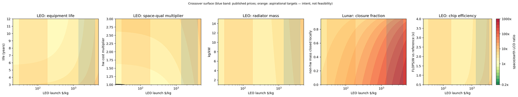

The generic-LEO crossover surface: space/Earth cost ratio against launch price with each companion axis varied over its anchored range. No single-axis path reaches parity at published prices.

The mass-multiplier refinement: at anchored values a 2× FLOPS/W advantage buys only ~39% of the benefit of halving launch price (ratio 4.0 vs 3.2 at $3,000/kg, both from 4.5), because the hardware term — untouched by efficiency — dominates both mass and capex. “The compute tax outweighs the launch tax” [S34] becomes true only after the qualification premium and hardware $/kW fall; near-term, both taxes are subordinate to qualification and life.

## II.4 External claim and independent-study checks

The two public crossover claims are recorded as comparison targets (never inputs), and both *reproduce inside the model* under identifiable conditions — which converts a public disagreement into a localized, testable one. The post-IPO review of independent studies below then checks the model rather than merely restating corporate claims. One preliminary correction of the record, because this document earlier mis-stated it: the Suncatcher design study does **not** claim system-level parity. Its cost section states twice that it is not a full economic analysis and not a comprehensive economic feasibility study, and its comparison sets the **amortised launch component alone** (≈$810/kW-yr for a Starlink-v2-class mass-to-power ratio at $200/kg; $810–7,500 across satellite classes) beside terrestrial data-center **electricity spend** (≈$570–3,000/kW-yr), explicitly excluding infrastructure, building, and chip costs [S32]. That is a launch-cost feasibility marker — the finding that launch need not remain independently prohibitive — not a parity claim, and it is consistent with this model, which reproduces launch as a minor term. The crossover claim this model contradicts is the stronger reading in circulation [S34], not the study’s own.

- **The Google/Planet study** (reported: crossover at $200–300/kg [S34]). At $250/kg with central anchors: space/Earth = 2.04 — no crossover. Under the favorable corner *within anchored ranges* (qualification ×1.2, 7-year life, 0.95 utilization, 3 kg/kW radiators): **0.88** — the claim reproduced. The dispute is three numbers, none of them launch price.
- **The Suncatcher design study** [S32] describes an 81-satellite dawn-dusk sun-synchronous cluster near 650 km with terabit-class optical links (an 800 Gbps unidirectional bench demonstration against a stated ~10 Tbps per-link requirement) and a learning-curve projection of ≲$200/kg by the mid-2030s — itself conditional on roughly 370,000 tonnes of additional cumulative mass launched, on the order of 1,800 Starship-class flights averaging ~180 per year, which the authors call ambitious. Its engineering results should be read precisely (arXiv v2, 17 June 2026):
  - HBM was the most **TID**-sensitive subsystem — irregularities from ~2 krad(Si) against a ~750 rad(Si) shielded five-year requirement, with no hard total-dose failures to 15 krad(Si) — while core logic and on-chip SRAM were the most **SEE**-sensitive. The reported inference error probability is roughly one per three million inferences under the stated assumptions, with the effect on **training** explicitly reserved.
  - At ~150 rad(Si)/yr, a seven-year dose (~1.05 krad) sits below the ~2 krad irregularity onset — the radiation results support five-year TID survivability with margin and *do not obviously contradict seven-year TID survival*.
  - What they do not establish is seven-year **system** reliability: SEE-induced corruption, host interruptions, training sensitivity, thermal management, and whole-spacecraft failure remain unresolved, with orbital repair called impracticable and redundant provisioning proposed instead — a cost, not an absence of one. The COTS practice supporting a low qualification premium (unmodified accelerators flying on imaging satellites [S34]) demonstrates cheapness, not five-year reliability.

The independent checks localize four additional gates:

- **Conventional mass and economic closure.** Turyshev closes PV, eclipse reserve, thermal rejection, fixed spacecraft functions, sustained communication, utilization, and finite life in a single framework [S39]. Its 34–59 kg/kW total independently brackets and supports the generic central mass at the order-of-magnitude level. Its more important result is the combined launch-plus-build ceiling: $250–1,000/kg at 40 kg/kW before communications and lifecycle penalties. Every additional $1,000/kW of communication or operations cost reduces that allowance by $25/kg. Current public launch prices consume more than the entire allowance before a spacecraft is built.
- **Low-mass architectures are conditional, not contradictory.** The integrated-panel and tether studies reach 8.9 and roughly 5 kg/kW respectively [S40], demonstrating that mass is an architecture variable rather than a universal constant. Both target inference and both exchange conventional subsystem maturity for deployment, structural, thermal, and custom-silicon risk. They justify explicit stretch scenarios; they do not justify assigning conventional spacecraft a five-kilogram prior.
- **Inference and training are different products.** Van Berkel compares a terrestrial 8,000-accelerator Clos fabric with orbital meshes: about 28,800 TB/s of terrestrial bisection bandwidth versus approximately 2.25 TB/s for a two-dimensional and 10 TB/s for a three-dimensional orbital mesh at 100 Gbps links, with network latency 150–450 times higher [S41]. Even much faster optical links do not remove multi-hop diameter and collective-communication latency. The appropriate early comparison is therefore per-satellite or loosely coupled **inference**, preprocessing, and communication-integrated edge work—not frontier distributed training. Training should receive a network-performance model, not an ordinary utilization scalar.
- **Small space-native nodes already have a different cost structure.** The peer-reviewed HPCA microdatacenter study finds power and thermal systems dominate bespoke small-satellite TCO, while compute hardware can be less than one percent; energy-efficiency improvements can reduce TCO by about two-thirds and are up to 2.5 times more valuable in space [S42]. This is encouraging for 0.5–10 kW Earth-observation preprocessing, where data originates in orbit and downlink is avoided. It is not evidence that a megawatt terrestrial-substitution service has the same economics.

The broader policy cross-check reaches the same conditional result by a different route. A University of Virginia assessment reports a simplified five-year 1 GW case at $135.6 billion in orbit versus $16.6 billion on Earth under present-style assumptions; near-parity appears only when launch falls to $30/kg, satellite hardware to $10/W, specific power rises to 100 W/kg, sunlight availability to 80%, and degradation and GPU failure both fall to 1% [S44]. Its model omits GPU cost, financing, insurance, logistics, and downtime and should not be treated as a precise forecast. Its contribution is the joint-condition result: parity emerges from several simultaneous improvements, not from launch price alone.

Consequence for the staircase, stated within the model’s service definition: **the modeled orbital architectures are not cost-competitive as substitutes for terrestrial frontier compute at the stated assumptions.** That conclusion now has a workload boundary: it applies directly to per-node inference in the cost model, while the new network evidence makes frontier distributed training less favorable than the scalar model shows. It does not price differentiated orbital products (in-orbit sensor processing, sovereign or military demand, resilience niches), which could be profitable while losing the commodity comparison. What follows for the staircase is correspondingly bounded: *commodity-scale* deployment ahead of the enabling corner is strategic positioning or learning investment rather than substitute-compute profit — an observation Part III converts into a discriminating test.

## II.5 Competition and the takeoff-speed assumption

**Explicit assumption.** This thesis is decision-relevant chiefly under a slow-to-medium AI takeoff. Under a fast software takeoff, incumbent compute and algorithms decide outcomes before any physical loop closes; the space complex becomes something the resulting intelligence builds afterward, not the path by which it arises. The prominent published bet on the fast branch [S35] argues automated AI research compresses AGI-to-superintelligence into roughly a year; this document’s program is the other branch, and the disagreement operates on priors, not on any evidence item below.

The system is not alone. China is the closest existing implementation of the terrestrial stages at national scale (solar, batteries, robotics, rare-earth refining, trailing-edge fabrication) lacking, for now, a reusable heavy-lift economy. Hyperscalers close the same inputs with capital rather than ownership — power agreements, custom silicon, supply contracts — which works until aggregate demand outruns what markets can scale. State programs hold ISRU roadmaps but iterate slowly.

Two corrections to the launch-chokepoint assumption, both cutting against a durable launch monopoly: payload cost-performance improved by two to three orders of magnitude over the decade against a smaller multiple for launch price [S34] — a crossover model treating launch as the primary axis mis-weights its own sensitivity analysis (borne out in II.3, where the crossover is not launch-gated); and chemical rockets are a local optimum — mass-manufactured vehicles, electromagnetic or kinetic launch, and mass drivers from a low-gravity surface (named in the fabrication initiative’s own material [S29]) would reset the launch axis rather than move along it.

**The capital wall.** Expansion purchased through markets pays stacked scarcity rents; when demand outruns supply, prices are set by scarcity. Properly qualified: markets are not static — the right formulation is a race between demand growth and induced supply with multi-year capacity lags as the binding term, and whether internal replication beats inducing market expansion is a *rate comparison* (which is what the responsive counterfactual of II.2 implements on the power axis). A self-replicating base escapes *mandatory dependence on external Earth markets* — not economic allocation, opportunity cost, or internal pricing, which persist in any multi-firm or internally-priced closed ecology: expansion re-denominates from currency into materials, energy, and time. Two caveats: the entry ticket is still paid in dollars — the first self-replicating unit is bought, not grown, which is what the bridge economy exists to finance — and the logic predicts *convergence, not uniqueness*: every serious actor eventually verticalizes or plateaus; the durable advantage is the shortest hardware doubling time once everyone is. Historical reference classes calibrate “unprecedented”: Manhattan and Apollo peaked near 0.4% of GDP; British railway investment ran ~40% of GDP over a decade; wartime borrowing far exceeded either [S35]. Trillion-scale buildout is extreme but inside the envelope — the capital wall yields to expected returns; what does not yield is the dependency structure of Part I.8.

**Integration versus modularity (the Coasean resolution).** Markets scaled semiconductors a billionfold through *dis*integration; why would this time differ? A firm’s boundary sits where internal coordination costs exceed market transaction costs [S25]. AI attacks the internal term (Part I.6) — but it attacks the external one too, improving supplier discovery, specification, contracting, monitoring, quality assurance, pricing, logistics, and modular interface design. The correct conditional is therefore that **AI moves the efficient boundary toward integration only if it reduces internal coordination costs faster than it reduces interfirm transaction costs**, an empirical question this document does not settle; what does survive is that the market interface retains an irreducible capital requirement efficiency gains do not remove. The defensible conclusion is bounded: AI may move the efficient boundary toward integration — not that ownership integration outperforms modular ecosystems in general. Three qualifications are central: markets also supply experimentation, selection, redundancy, and price signals, which an integrated complex must replicate internally or decay into soft-budget pathologies; technical closure (the network can produce its inputs) must not be conflated with contractual or ownership closure — this thesis requires only the first; and the in-domain integration success story confounds integration with reusability, cadence, and incentives [S1].

**The operating wall.** Physics-priced inputs (energy, materials, machine-hours) fall with scale; society-priced inputs (land, permits, interconnection, litigation, goodwill) rise with it — on Earth, closure has a structural ceiling because land, law, and neighbors cannot be internalized. Space shrinks and relocates the society-priced term rather than abolishing it, with one favorable property: permission attaches to the gateway (launches, spectrum) rather than the complex, so the millionth robot needs no new municipal permit. The hard physical version: Earth has a planetary waste-heat budget; space offers radiator area not bounded by a planetary surface (though still bounded by matter, transport, geometry, and maintenance — Part IV) — though not free rejection. Two external observations bracket how hard the wall binds *now*: data-center siting is already politically contested over electricity, water, and land — the society-priced curve observed from inside the industry [S34] — while the AGI-buildout literature meets the same wall with natural gas and deregulation at a firm-power floor below the nuclear PPA, never mentioning orbit [S35]. The wall binds through politics more than physics or long-run capital — though near-term hardware (turbines, transformers, cooling, construction capacity) can also bind — and the difference between branches is a parameter in this edition’s model, not a mood. And the sequence remains brutal: before high closure, space is the most *expensive* place to operate — every kilogram of spares travels at full launch freight while depreciation runs at its worst (II.3’s ~4–9×) — so the declining-cost regime switches on only after κ is high, which is why the bridge economy and the clock-setting components decide who survives to reach it.

**The threshold-model argument.** If RSI capability is a threshold — a base model good enough to run verified improvement loops — a smarter starting model confers a head start that the loop erodes; the durable variable becomes who runs more loops, which is hardware. Mid-2026 evidence supports continued benchmark compression between open and proprietary models (open-weight releases benchmarking near the frontier [S12]); it does not establish commoditization at an autonomous-R&D threshold, so hardware dominance is the small-α branch of the model rather than the established trajectory. If RSI-grade capability does arrive in open weights, model advantage weakens sharply without evaporating — post-training, proprietary data, evaluation systems, inference infrastructure, tool integration, operational reliability, distribution, and the capacity to run physical experiments all persist as differentiators — and to that extent the contest shifts onto the physical loop, the strongest form of the verticalization thesis. The counterpoint: the argument holds only if capability is threshold-like rather than continuously compounding (L_RSI ∝ A<sup>α·C</sup>β·V^γ, with α unknown); benchmark convergence does not establish that autonomous R&D capability is threshold-like. And the structural counterweight: models converge because they train on the same public data, so residual differentiation concentrates exactly in proprietary physical-process data (Part I.2) — if general capability commoditizes, the model contest narrows to the domains where training data is generated by owned industry, folding the model race back into the physical loop.

# Part III — Strategy Interpretation and Governance

## III.1 A Musk-associated technology stack

The following mapping is an analytical interpretation of how existing companies could supply layers of the proposed system — not proof that they are managed as one program, although the 2026 developments (the Terafab initiative; SpaceX’s absorption of xAI) bind the transport, communications, intelligence, and fabrication layers by overlapping control, strategic coordination, and contractual collaboration. Tesla remains a separate public company; a shared controlling figure and a framework agreement are not common ownership [S27].

| layer | contributor | capability | role in recursion |
| --- | --- | --- | --- |
| Intelligence | xAI (within SpaceX) | AI research, large-scale compute [S3] | design, coordination, recursive digital improvement |
| Energy | Tesla Energy | generation, storage, power electronics [S2] | power for compute, factories, robots |
| Robotic labor | Optimus | manipulation, maintenance; stated Terafab construction role | manufactured labor capacity |
| Manufacturing | Tesla | high-volume factories, batteries, motors | factory design, machine production at scale |
| Fabrication | Terafab (Tesla, SpaceX, xAI; Intel from Apr 2026) | declared: chip design, lithography operation, fabrication, memory, packaging [S6–S10, S27, S29] | declared compute-substrate layer; framework stage |
| Transport | SpaceX / Starship | reusable heavy lift | seed deployment, materials movement |
| Communications | Starlink | distributed connectivity | coordination across remote nodes |
| Compute deployment | planned D3 constellation | radiation-tolerant silicon | space-based compute as stated product |
| Data | fleet, factories, test programs | telemetry, process parameters, failure archives | the physical loop’s exhaust (I.2) |
| Industrial knowledge | Tesla / SpaceX / xAI / Terafab | CAD/CAM, simulation, software toolchains, process recipes, material models, build records, and failure archives | portable digital seed and industrial memory |
| Settlement | Mars objective | self-sufficient city as stated goal | demand center; survival independent of Earth |

The theoretical advantage is not ownership of complementary companies but a shorter verified end-to-end loop across design → manufacture → deploy → learn. The closure race rewards the shortest such loop, not the largest stock of any single input.

```
xAI improves intelligence → AI improves robots and factories →
factories expand energy and hardware → Terafab expands chips →
hardware expands compute on Earth and in orbit → compute improves AI
```

The advantage, if it exists, is the ability to integrate feedback, capital allocation, engineering, deployment environments, and industrial production into that shorter loop. Reported preparations for a SpaceX public offering would, if completed, add a financing event for the capital-intensive middle of the loop [S9, S27]; financing capacity is an enabler, not evidence of closure intent.

## III.2 Terafab and the fabrication frontier

**What was announced**: a Tesla–SpaceX–xAI chip fabrication initiative (March 2026), joined by Intel in April; declared scope from chip design through lithography operation, fabrication, memory, packaging, and test; reported $20B initial plant with a filing-based ceiling near $119B; 2-nm target; mass production stated for 2028 [S6–S10]. **What the primary source says** [S27]: a general framework with Tesla — timelines, milestones, and capital expenditures not yet determined; no binding obligations; a stated orbital data-center plan from as early as 2028; an acknowledged present shortfall in chip supply for orbital AI. **First-party messaging versus legal commitment** [S29]: the initiative’s own site frames the effort on the Kardashev scale, publishes scaling figures (~1B robots, ~10 Mt/yr launched, >1 TW solar), names chip lines for vehicles, robots, and space (AI5, AI6, D3), publishes an explicit orbital-versus-terrestrial cost decomposition, and names lunar mass drivers as the next step. The divergence between site and filing is itself informative: a strongly space-oriented declared strategy resting on unsettled implementation.

The implementation detail matters. Reporting describes a roughly $3B research fab producing a few thousand wafers per month before any scaled phase, with ambitions moving from about 100,000 wafer starts per month toward one million [S6–S10]. Those figures evidence intended scale, not comparable output: wafer starts cannot be compared with a foundry’s global production without node, wafer diameter, product mix, yield, and effective die output. Planned products include AI5/AI6 chips for vehicles and robots and radiation-tolerant D3 silicon for orbital deployment; Optimus robots have been assigned a stated construction and operating role. Each remains a target rather than demonstrated capacity.

**What it changes**: fabrication moves from missing term to declared target; the residual dependency moves one layer down (EUV lithography, deposition, etch, metrology, ultra-pure feedstocks — sole-supplier equipment, not foundries); the fab-to-space link becomes explicit (D3). **What it does not change**: no wafers have been produced; the timeline is faster than any historical ramp; industry skepticism is on record.

The competence question needs stating precisely, since earlier drafts got it wrong: Tesla, SpaceX, and xAI have no advanced-fab operating record, but **Intel plainly does**, and the reported process plan is Intel 14A — so the open question is whether that experience transfers into this organizational structure and what obligations Intel has actually accepted, not whether anyone involved has run a fab.

Two further corrections. The sites are distinct: a smaller Tesla research fab at the Giga Texas campus, and a proposed SpaceX-led scaled facility in Grimes County whose county tax and economic-development agreements are now recorded as fully executed — strengthening site-level commitment without constituting a definitive construction, funding, or operating agreement [S6–S10]. And scale comparisons used in earlier drafts are withdrawn: wafer-start counts cannot be set against a foundry’s global output without controlling for wafer diameter, node, product mix, yield, and effective die output, and “one terawatt per year” is a claimed annual production rate of hardware whose aggregate nameplate power draw would total a terawatt — a manufacturing-throughput figure not commensurable with national electricity consumption.

**The lithography question**: for terrestrial operation, purchased lithography is an acceptable permanent dependency; for high space closure it must eventually be reproduced, substituted (older nodes at volume; nanoimprint; e-beam), or accepted as designed permanent import — the deepest single closure problem in this framework (and precisely where the Part I vitamin gap lives). This edition adds the bottleneck convergence: the AGI-buildout literature identifies advanced packaging and HBM memory as the near-term chip constraints [S35], and HBM is what the Suncatcher radiation testing found most dose-sensitive [S32] — the same component class is the terrestrial scaling bottleneck and the space reliability weak point.

**Terafab-specific observables.** The milestones that would change this assessment are: the first research-fab wafer and disclosed yield at any node; visible order flow from lithography, deposition, etch, and metrology suppliers; evidence that memory and advanced packaging are actually produced in-house rather than outsourced; radiation-qualified D3 silicon with disclosed orbital-compute unit economics; and definitive agreements that commit capital and counterparties. Industry skepticism is therefore a testable forecast, not a rhetorical counterweight [S10].

## III.3 Competing hypotheses: the evidence table

The hypotheses are nested rather than exclusive, since a long-run off-world strategy can be *pursued through* vertical integration and supply hedging — those are mechanisms, not alternatives. **H0**: no *integrated* off-world strategy — individual terrestrial or orbital projects arise from ordinary standalone commercial, supply-chain, or research motives (with **H0′**, partly related businesses under overlapping control, as its weakest variant). Standalone orbital-compute ventures are H0-compatible under this definition; what H0 does not predict is cross-layer integration toward off-world industry. **H1**: deliberate integrated space–AI–industrial development — the P4a claim. **H2**: H1 plus an intended transition to recursive industrial closure — the P4b claim. Because the hypotheses nest, each evidence item is assessed on two separate margins — does it separate H1 from H0, and does it separate H2 from H1 — and the assessments are **ordinal, not numerical**: the items are correlated (several derive from the same corporate communications), absence-items depend on assumed observability, and declared intent is cheap; assigning multiplicable likelihood ratios to such material would imply a probabilistic model that does not exist. Ratings: *neutral* (equally expected under both), *weak*, *moderate*, *strong* (difficult to explain under the alternative). A distinct motive reading cuts across the nest: heavy industry moves off Earth to *protect the biosphere* rather than escape a constrained platform [S34] — same physics, different telos — which supplies an additional non-H2 explanation for any orbital-compute observation. Per the propositions ladder, everything here concerns P4, and P3 is decoupled from it: the migration case requires no claim about any company’s intentions.

[output not shown]

E12 and E15 (the Google/Planet Suncatcher prototype program and the design study’s content) are removed from this table in r3.4: they are actions of *independent* actors and bear on no hypothesis about the Musk-associated complex’s intentions. They are retained as engineering reference-class observations under external cross-checks below — an announced prototype program (satellites slated for early 2027 [S33]), and radiation results bounding the qualification corner (5-yr TID survivability supported with margin; 7-yr *system* reliability unresolved; II.4).

**What the models add to interpretation.** A rational H2 actor facing Part I would visibly invest in the electronics closure layer — rad-tolerant lines, stockpile logistics, shelf-life-rated spares, off-world packaging/test — because that is the most frequently observed minimum cut in the sampled ensemble. A rational H1-or-H2 actor facing Part II would run orbital compute at a loss for positioning, or privately believe the COTS/long-life corner; sustained scaled deployment after the unit economics are publicly evident is a *moderate-to-strong* discriminator between the strategic (H1/H2) and commercial (H0) readings — and conversely, quiet retreat after the demonstration phase is what H0 and H0′ predict. On-orbit *materials-recovery* recycling at scale (not debris-compliance servicing) would be *moderate-to-strong for H2 specifically*: Part I’s structural result that the LEO architecture lives on its recovered-mass feed loop (capture/mining receives ~98% of central co-binding credit; r3.5 withdraws the stronger stale claim that the recycling *sector* was knockout-indispensable) makes building that loop the rational early move of a LEO-first closure strategy and of no one else.

**External cross-checks** [S35]: the canonical AGI-buildout analysis resolves the power wall terrestrially without mentioning orbit — non-space-interested corroboration of Part II from outside; its chip bottleneck converges with the space radiation weak point (III.2); and its fast-takeoff thesis, if right, weakens the H1/H2 rationale regardless of the evidence — an effect on the prior, reported separately from the item-level assessments. A provisional July 2026 frontier-lab hiring sweep is quarantined as an appendix note (A.7), not used as an evidence-table item or model input.

**Cumulative assessment** (ordinal synthesis, not multiplication — the items are correlated and the ratings judgmental): the evidence **substantially establishes H1 at the level of declared direction and early implementation** — the initiative list in the SEC-filed offering materials (E6) and the first-party messaging (E14) are difficult to explain under a purely terrestrial reading, and E7/E9/E13 are consistent implementation steps (E12 no longer appears in the table — it was moved to the external cross-checks in r3.4 as an independent actor’s program). It **does not establish H2**: no item in the table is more than weakly diagnostic for closure intent, the closure-specific observables (seed bills of materials, reproduction metrics, minimum-cut roadmaps, locally reproducible production equipment) remain absent (E10), and most observed actions are equally expected under a conventional integrated off-world commercial strategy. P4a is documented; P4b remains inferential — which is exactly the split the propositions ladder now encodes.

## III.4 Control and governance of a self-expanding system

A self-expanding autonomous industrial network is, formally, a governed macroscale von Neumann replicator; the property that makes it valuable — compounding physical replication — makes its failure modes compound too. Verification must scale with expansion (V is a safety term); throttle authority must be explicit (rate limits, hardware-level authorization of replication steps, clarity about who holds them); the legal frame is unsettled and first movers set precedent.

The framework resolves its own tension — celebrating escape from society-priced costs while requiring retained constraint — through the gateway: in space, permission attaches to launches and spectrum, which is where governance holds enforceable leverage. The leverage variable is dependency — but not proportional to (1 − κ), since this document has already established that scalar closure is invalid and a single low-mass import can be a minimum cut conferring disproportionate leverage. The governing quantity is G_dependency = f(criticality, substitutability, stockpile, supplier concentration, enforceability): what matters is whether withholding an input collapses the network, not how much of it is imported. Part I supplies an answer that is architecture- and parameter-conditioned, and must be stated that way: **where import dependency remains load-bearing — the lunar and Mars ensembles — electronics is the most frequently observed minimum cut, and the vitamin parts are the last governance handle**; in the sampled central LEO draws a single import line is fatal only in a minority of draws (~0–11% for electronics across r3.5 regenerations), so there the material handle runs mainly through feed availability and the recovery loop rather than any one import line. Material-dependency governance has a declining window as closure rises; throttle authority, verification requirements, and replication limits are cheapest to embed as licensing conditions during the bridge period. Closure does not end governance (communications, cryptographic authority, personnel, ownership, insurance, treaties, orbital traffic, trade remain), but the material handle is the one that closes.

A serious control architecture — beyond this document’s scope but within its obligation to specify — requires hardware roots of authority; multi-party authorization for replication steps; explicit rate limits; compartmentalization and fault-containment zones; secure update and rollback channels; explicit cyberattack and insider-risk models; independent verification capacity; operator and government incentive analysis; jurisdiction and liability rules; and failure recovery when communications with Earth are unavailable. These are named requirements, not solved problems. They must be tested under the same loss-of-import, shock, and degraded-communications conditions used to test the production system.

Design principle: replication authority should be the most verified and least autonomous function in the system — positioned deliberately against the efficiency gradient, embedded at the seed stage, because it cannot be retrofitted onto a mature complex.

## III.5 Falsifiable indicators, model-ranked

The indicators carry ordinal diagnostic ratings informed by the models (consistent with III.3’s refusal of numerical likelihood ratios — the r3.4 “expected likelihood ratios” phrasing was a leftover and is withdrawn):

1. **A terrestrial autonomous-closure demonstrator that constructs and commissions a second production cell under lunar-palette, no-routine-entry constraints** — strong for H2 over H1.
2. **Production or fabrication equipment explicitly designed for local extraterrestrial reproduction** — strong for H2 over H1.
3. **A dedicated cross-company closure program with published κ-vector metrics** — strong for H2 over H1 (flips E10).
4. **A machine-readable off-world seed package** containing the physical bill of materials, digital toolchain, industrial memory, dependency graph, and experimental/commissioning plan — strong for H2 over H1.
5. **An element-resolved Moon–Earth–asteroid supply plan** with source yields, recovery losses, transfer arcs, import-withdrawal milestones, and explicit material-vitamin stocks — strong for H2 over H1.
6. **Sustained scaled orbital-compute deployment despite publicly evident unfavorable unit economics** — moderate-to-strong for H1/H2 over H0 (Part II makes the test operational — watch fleet growth after the economics are public).
7. **Electronics vitamin-gap engineering**: stockpile facilities, shelf-life-rated spares logistics, off-world packaging/test lines — moderate-to-strong for H2 over H1 (Part I makes it the rational first move of a closure strategy).
8. **On-orbit materials-recovery recycling at scale** — moderate-to-strong for H2 (the Part I LEO feed-loop result; r3.5 note — the earlier sector-indispensability framing was a stale-output claim and is withdrawn, the indicator survives on the feed-dependence structure).
9. **An export-control-scoped internal model variant** — moderate.
10. **Terafab executed definitive agreements with committed capital** — weak-to-moderate (upgrades E7 from framework to program; hedging inside H0 still predicts it).

The ranking above asks which observations discriminate among H0, H1, and H2. A second set asks whether the physical thesis is becoming feasible at all. These lower-diagnosticity but still necessary indicators from the Second Edition are retained:

- robots performing unscripted maintenance, construction, mining, and machine tending for long periods, with autonomous recovery fraction and human intervention hours reported per machine-hour rather than described only as “limited”;
- local production of propellant, structural material, and replacement parts at operational rather than laboratory scale;
- factories using locally processed feedstock to manufacture additional power, extraction, and production equipment;
- a measured decline in imported mass per unit of local productive capacity, reported by component class rather than as an aggregate mass fraction;
- element-level closure reported as inputs, inventories, losses, recycled flows, and source-specific yields—not inferred from aggregate local mass;
- space-manufactured compute, or production equipment capable of making it;
- net positive industrial reproduction after depreciation — P > D in every indispensable sector — with published r and δ estimates by component class;
- the Terafab-specific milestones in III.2: first wafer and yield, process equipment orders, in-house memory and packaging, qualified D3 silicon, orbital-compute revenue, and a measured robot reproduction ratio;
- open-weight systems demonstrating sustained autonomous verified improvement loops — evidence for the threshold-like branch in II.5 — and, separately, fleet- and factory-owning actors outperforming open models on engineering tasks in a way attributable to proprietary process data; the contrary result would show that κ_D does not bind;
- a sustained measured decline in cost per verified improvement loop, and replication-relevant conditions appearing in launch licenses or export-control terms while material leverage still exists.

Threshold observations that would move Appendix A: a demonstrated ISRU plant above ~50% full-system materials closure; audited robot production figures; an independent satellite-reliability audit reporting cohort-specific failures per satellite-year, separated from retirements and planned disposals (the earlier “~2.5–3%” figure was an early-cohort fleet fraction, not a general hazard rate, so divergence from it is not the right test); and any traceable datum on off-world-producible electronics tiers — the vitamin-gap anchor this document flags as its highest-value currently parameterized missing measurement. The thesis *weakens* if humanoid robotics remains economically narrow, advanced manufacturing cannot be localized, launch costs stop declining, closure requires a permanently growing Earth supply chain, verification costs rise faster than capacity — or if Terafab devolves into design-and-packaging dependent on external front-end fabrication, which would reopen the fabrication term entirely.

## III.6 Refined complete thesis

The coherent end state remains a recursively self-expanding space industrial ecology. Reusable rockets transport an initial seed. AI supplies scientific, engineering, and coordinating intelligence. Robots provide scalable physical labor. Local energy systems supply power. Mining and refining convert extraterrestrial matter into industrial feedstocks. Automated factories produce structures, machines, robots, transport vehicles, energy systems, and — if the electronics tier can close — compute. Communications integrate specialized nodes into one economic and operational network.

The network first reduces Earth dependence, then reaches self-sustenance, and finally produces net additional capacity. At high closure, station-keeping, collision management, maintenance, transport, and coordination remain real requirements; they are supplied by industries inside the network rather than purchased as externally scarce services.

```
matter + energy + intelligence + time → expanding productive capacity
```

Recursive self-improvement is therefore not limited to software. Intelligence improves the machinery and institutions that create intelligence; the industrial substrate returns energy, compute, data, experimentation, and physical agency to the intelligence layer. The ultimate product is an industrial system capable of producing more of itself.

The most precise formulation now available is conditional and model-separated. Current evidence substantially supports deliberate integrated space–AI–industrial development (P4a), but not an intended transition to recursive closure (P4b). The inherited industrial model finds expansion under some assumption sets and failure under others, with electronics and feedstock dependencies localized by architecture. The new integrated-bootstrap model makes a first explicit pass through the complete intelligence–industry loop, seed bill of material, source network, and reproduction to a second operating cell; it finds the lunar vitamin bridge and the synthetic Moon–asteroid scenario model-feasible under central assumptions and the configured strict lunar source graph structurally infeasible. Because every new structural coefficient is declared rather than measured, that is an executable hypothesis, not evidence that the complete recursion can be built. The comparative-economics model finds the Earth-dependent bridge uneconomic at anchored values and does not price the mature high-closure ecology. Capability accumulation is observed; positive off-world industrial reproduction and a unified closure strategy are not.

$$\begin{aligned}
I(t+1) &= I(t) + f(C,D,V,H), \\
H(t+1) &= H(t) + g(I,E,M,R) - \delta_{\mathrm{env}}H(t), \\
C(t+1) &= C(t) + h(H,E,\mathrm{fab})
\end{aligned}$$

In earlier editions f, g, and h were unspecified placeholders and this compact model was a causal diagram. The inherited model operationalizes g as the lexicographic maximin allocation of Part I.7 (with repair, recycling, stockpiles, and imports) and decomposes δ_env by sector and environment. The Fourth layer supplies a first stylized f and h: installed compute drives verified intelligence through a saturating gain law; intelligence raises task autonomy and industrial productivity; the resulting operating cells manufacture additional compute after construction and commissioning lags. Constant-rate Earth-fed deployment is run beside it as the counterfactual. These functions are executable and swept, but their coefficients are ASSUMPTION-class and they omit training data, algorithmic regime changes, verification failures, hardware-node detail, and many coordination limits. The model therefore tests the consequences of a coupling law; it does not measure that law or establish takeoff, subject also to the speed caveat of II.5. The r4.1 ablations sharpen this further: at central coefficients the dynamic coupling is inert — material supply caps construction at every step — so the declared f and h currently matter through seed feasibility (the static autonomy level), not through the growth trajectories (I.8). A coupling whose removal changes nothing is not evidence for recursion; it is a declared mechanism awaiting a regime in which it binds.

**What the thesis does not claim**

- It does not establish that the companies are managed under one confidential master plan; III.3 assesses the public evidence.
- It does not imply that energy, matter, infrastructure, coordination, or opportunity cost become literally free.
- It does not assume intelligence automatically solves semiconductor fabrication, reliability, verification, governance, or safety.
- It does not claim that the degrees of freedom of a current humanoid robot demonstrate unscripted industrial autonomy; embodied task coverage, recovery, and verification remain unmeasured requirements.
- It does not require human settlement, agriculture, or a closed biosphere for the reference machine ecology, nor does it claim humans could never be present. A crewed architecture is a larger closure problem than the one modeled here.
- It does not require every industrial node to be self-contained; closure can exist at network level.
- It does not require uninterrupted exponential growth; the system can move through bottleneck-limited regimes and can double before later losing viability.
- It does not claim Terafab will achieve viable yields or off-world fabrication closure; it is a declared terrestrial attempt whose implementation remains unsettled.
- It does not claim a slow takeoff is certain; the physical-path thesis is conditional on the slow-to-medium branch in II.5.
- It does not claim that closure is imminent, that model frequencies are empirical probabilities, or that space compute is economical today.

# Part IV — Conclusion, and Speculative Terminal Scenarios

## IV.1 The defensible core, restated with numbers attached

Two walls, two escapes, one passage. The capital wall yields to expected returns inside the historical envelope; the operating wall binds through politics rather than physics at current scale; both escapes remain conditional on surviving the bridge — and the bridge’s failure mode is now specific: hold electronics-class stockpiles against shelf life, and reach local production of some electronics tier before the import ramp decays. The defensible core conclusion stops here, with its conditionals quantified: *if* industrial closure becomes sufficiently high across every indispensable sector (Part I’s bottleneck is architecture-specific: capture/mining dominates LEO, electronics dominates the Moon, and electronics and power co-bind on Mars) *and* terrestrial expansion costs rise faster than off-world deployment costs (Part II says: not at anchored values; only in the qualification/life/utilization corner at target-class launch prices), *then* some large-scale industrial and computational activity may migrate off Earth. Everything beyond that sentence is scenario.

> **QUARANTINE NOTICE.** Sections IV.2–IV.4 are scenario-class: internally consistent extrapolation, not established result. Nothing in them feeds back into Parts I–II inputs. Each scenario carries a model check — usually a constraint, not support.

## IV.2 After convergence: deployment as the terminal regime

At some point the marginal value of further design improvement falls below the marginal value of another deployed node — architectural convergence. Past it, intelligence behaves as a commodity produced by infrastructure — heuristically, throughput ~ deployed energy × physical efficiency, a relation that omits memory, interconnect, utilization, data, reliability, verification, latency, workload composition, and fabrication yield. Efficiency is floor-bounded (Landauer, with reversible logic the stated exception); scale plausibly becomes the *dominant marginal* variable rather than the only one; scale means energy; energy means collector area; and collector area is not bounded by a planetary surface off Earth. It remains bounded — by matter, transport, orbital geometry, heat transport, collision risk, maintenance, and control, and per the published cluster analysis by the quadratic scaling of satellite count with cluster radius and by mutual occlusion of rejected infrared between closely flown spacecraft [S32]. The ceilings-and-rates argument is retained in its r2.10 sensitivity form: the waste-heat ceiling sits perhaps two orders above current civilizational energy use, the thermodynamic floor several orders below current efficiency, and the ~3×/yr algorithmic-efficiency figure [S26] measures compute-for-fixed-language-performance only. Under sustained compounding, distances that look like centuries become decades — *whether the compounding is sustained is precisely what is unknown*.

The two regimes can be stated as marginal cost curves. On Earth, the marginal cost of the n-th node can rise as the operator bids up land, congests grids, and encounters political and thermal limits. In space, *after closure*, the marginal cost can fall through learning and self-replication. One curve rises and the other falls; their crossover is the migration point, and it moves earlier as launch cost declines, closure improves, equipment life lengthens, or qualification premiums fall. Part II shows that the curves do not cross at the anchored bridge-economy values.

> **Model check.** The cost-curve claim — Earth’s marginal node rises with n, space’s falls with n after closure — is the crossover surface, and at anchored values the curves do not cross. The scenario needs three demanding unanchored conditions: rad-tolerance at commodity cost (the strongest current data supports five-year TID survivability but leaves system reliability — SEE, training workloads, thermal, whole-spacecraft — unresolved [S32]), service life nearer 15 years than 5, and target-class launch or closure substituting for launch. The collector-area arithmetic is not the disputed part; the three demanding unanchored conditions are where the scenario lives.

Two conditions attach. **Demand saturation**: if the set of tasks worth computing is bounded, demand saturates and the argument that space is the only arena permitting unbounded deployment loses its motivation [S34]. The physical ceilings bound how cheaply computation can be done; a demand ceiling would bound how much is wanted — the more decisive and less examined of the two. The non-saturation branch has a canonical published statement [S35] and no resolution; the scenario is conditional on it. **The upgrade asymmetry, narrowed**: software-layer improvements propagate to deployed compute at near-zero marginal cost, but hardware-dependent gains require replacement or retrofit — silicon is not upgraded in place. The model consequence: the space-electronics obsolescence term would shrink after convergence only for its software-limited share.

## IV.3 Paradigm shifts: delay, alteration, or prevention

Catch-up time (a new paradigm must beat the incumbent plus decades of compounded process learning, still improving as the newcomer matures) and finiteness (irreversible-computation paradigms climb toward the same ceiling; reversible computing is the stated exception) bound the leapfrog objection. Exposure is concentrated in fabrication on 10–20-year horizons; energy, labor, transport, and materials are less paradigm-sensitive — substantially reusable, not immune. The fleet self-insures through its own 3–6-year depreciation; the fab carries the stranding risk — the penalty of taking the lead.

General-purpose robotic manufacturing is a partial hedge because it is the industry that builds industries: after a paradigm shift, the cheapest retrofitter may be the actor able to build the next fab faster than a rival builds its first. The corresponding strategy is to verticalize the less paradigm-sensitive layers aggressively, preserve hardware generality and retooling capacity at the paradigm-specific layer, and track retooling speed alongside doubling time. The model check below shows that this hedge must be pre-positioned; it cannot be improvised after a catastrophic electronics loss.

## IV.4 The alternative telos, and the properly conditional close

One reading of the same physics reaches this document’s destination from opposite values: Earth is not a constrained platform to escape but a uniquely valuable biosphere to protect — zone the planet for habitation, site heavy industry and compute where there is no ecology to disturb [S34]. Independent corroboration of the operating-wall mechanism comes from the same quarter: data-center siting is politically contested over electricity, water, and land. The physical argument is common to both readings; only the telos differs — and this decouples P3 from P4: the migration case can be made without any claim about one company’s intentions.

The observed portfolio is consistent with an economic gradient toward greater integration — discovery until convergence, deployment after it, with space as one plausible arena under a demanding set of crossover conditions that this edition has now priced. Present evidence does not establish that recursive off-world industrial closure is the governing objective of the companies described in Part III. Earlier editions ended by saying a model could decide; this one built the model. What the model says is: the recursion is feasible only under assumptions that are currently choices rather than measurements; the economics point to Earth at every anchored value; and the observations that would change either conclusion are now named, ranked, and waiting.

## Limitations and claim boundary

The most robust outputs are structural within the implemented model: balanced doubling is unit-invariant; the three-stage allocator has a unique state transition; realized endpoints include same-step shocks; recoverable scrap cannot exceed loss-specific retirement; and Part II is exactly affine in launch price. Architecture comparisons, endpoint definitions, and regeneration from fixed seeds are also auditable.

The substantive conclusions remain assumption-conditioned. In the inherited model, the requirement matrix, homogeneous electronics-closure multiplier, repair and recovery efficiencies, stockpiles, shock process, import profile, and finite capture reservoir are not measured as a coupled industrial system. Its scalar-anchor screen does not rank structural matrix uncertainty, interactions, policy families, or all environments, and its LEO model has neither an endogenous debris stock nor a depleted capture reservoir.

The Fourth layer adds a material-category-by-sector bill of materials, source yields, Earth–Moon–orbit–asteroid transfer arcs, seed-mass optimization, four knowledge layers, task-resolved autonomy, intervention demand, process-specific gravity and centrifuge overhead, construction and transport lags, commissioning, yield ramps, minimum viable scale, reproduction to a second cell-equivalent, and an active/derelict/fragment debris state. These are model features, not validated factories. Its bills of material, recoverable yields, source throughput, autonomy/productivity gains, lag and ramp coefficients, intervention budget, asteroid portfolio, transfer capacities, and collision kernels are declared assumptions. The seed is minimum-mass only inside its fixed linear architecture, and it is sized as an installed, operating nucleus: delivery, unloading, site preparation, initial power deployment, calibration, and first commissioning are not simulated. The reproduction dynamics advance one continuous aggregate cell-equivalent — the 18-sector detail constrains seed sizing but does not persist into reproduction, so sector-specific commissioning order, partially complete second cells, and mid-construction bottlenecks are not represented. Seventeen material categories do not resolve mineralogy, alloying routes, contamination, process chemistry, purity ladders, tool wear, quality yield, or every consumable. The electronics tiers remain aggregates rather than fabs and tool chains. Documented elemental occurrence is not a grade distribution, recoverable reserve, refining yield, or accessible asteroid portfolio.

The terrestrial rehearsal in I.9 remains a proposed validation protocol, not an accomplished demonstration; its computed scenario is a requirements case, not an experiment. Gravity is treated more faithfully than a location label, but only through declared process compatibility and centrifuge mass/power penalties; the model does not simulate granular mechanics, convection, melt behavior, vacuum welding, dust, radiation, traction, or thermal cycling. The compute–intelligence loop is normalized and phenomenological. The Earth counterfactual imposes rate and siting ceilings rather than deriving land, grid, water, permitting, labor, or capital prices. The debris module is a stress-test stock-flow model, not a shell-resolved conjunction or traffic simulation.

Part II omits communications and ground-network capex, program NRE, insurance, spectrum and regulatory costs, and several spacecraft-bus functions; serviceability is a scenario, not an observed property. The Part II cost comparison is not dynamically coupled to the Fourth layer, so P3b remains unpriced even where the physical-model quantities compound. Several inherited Part II intervals still resolve through the collective [S36] record rather than a complete claim-level bibliography. That is sufficient to reproduce the computation, not to independently audit every range endpoint; Appendix A marks the affected calibration as provisional. Finally, the Part III strategy assessment is ordinal and observational: corporate filings and statements establish declared initiatives, not an intent to achieve recursive closure. No result in this paper is a forecast or an empirical probability of success.

# Appendix A: Parameter Anchors

The authoritative, machine-readable anchor set is `params/anchors.yaml` [S28]; every generated report carries a per-run provenance table. Ranges reflect genuine disagreement across sources; values are anchors, not precision claims. The Second Edition’s discipline — quantities normalized by type, rate quantities never averaged into one “r” — is implemented in code (`delta.py`) rather than prose. Rows marked *(context)* are documentary quantities cited for interpretation only: they are not wired model inputs and have no YAML entry. Every other row resolves from the YAML, and source classes use only the five enumerated classes of Scope and Status.

**Calibration-provenance boundary.** Reproducible anchor resolution is not the same as a complete scholarly source audit. Later sources provide exact titles, dates, locations, and permanent links, but several inherited anchors summarized through [S36] still lack an endpoint-by-endpoint record of author or organization, title, date, page/table/section, permanent URL or DOI, extracted value, and transformation. Until that claim-level register is complete, the affected ranges are provisional calibration inputs and the Part II multiples should not be described as independently source-audited.

## A.1 Capacity-loss quantities (δ), by type

| quantity | range | class [ref] | type |
| --- | --- | --- | --- |
| Solar-array degradation, GEO | 0.4–1.7 %/yr | peer_reviewed [S19] | continuous degradation |
| Terrestrial PV degradation | 0.5–0.6 %/yr median | peer_reviewed [S18] | continuous degradation |
| LEO constellation failure | ~3 % early generations; <0.5 % later | reporting [S22] | cohort-dependent; mixes failure, retirement, disposal; not a hazard rate |
| Satellite design life | ~15 yr GEO; ~5 yr LEO | technical_report (GEO) / reporting (LEO) [S22] | engineering envelope, not a hazard rate |
| Fab-tool depreciation | 2–5 yr | technical_report [S36] | accounting schedule; the wired model input is the advanced-obsolescence rate below |
| Advanced-node obsolescence rate, Earth | 0.15–0.35 /yr | technical_report [S36] | `delta.obsolescence_earth_adv`; frontier-equivalent capacity loss |
| Accelerator retirement | 3–6 yr | technical_report [S36] | technological retirement; `compute.life_years_earth` |
| Cluster interruption frequency | ~1 / 2,000 accelerator-days *(context)* | technical_report [S36] | mixes component, host, network, software events, mostly auto-recovered — NOT a component hazard rate |
| Space logistics penalty | 1–5 %/yr | **ASSUMPTION** | internal repair-chain tax; unanchored |

These are not interchangeable; the model converts each to capacity-loss-per-year per component class before it enters a growth equation. Solar-array and satellite data do not establish the depreciation of mines, bearings, seals, machine tools, batteries, robots, or dust-exposed thermal equipment — those entries are per-sector ASSUMPTIONS in `params/environments.yaml`.

## A.2 Rate quantities previously conflated as “r” — separated

| quantity | range | class [ref] | what it does NOT measure |
| --- | --- | --- | --- |
| PV energy payback | 0.9–1.1 yr Europe; 1.0–4.1 harmonized | peer_reviewed [S20] | reproduction of mines, refineries, tools, or the panel line |
| Strawman replication design target | ~1 yr (assumed) *(context)* | technical_report [S23] | an estimate or measurement of anything — it is a proof-of-principle design assumption |
| Construction-execution cadence | ~10 months | reporting | recursive reproduction; used a mature host economy |
| Humanoid robot production | 50–100k targeted *(context)* | company_statement | feasibility — targets evidence intent |

System replication time is unknown as a measurement. In this edition it exists only as a computed output distribution (Part I.8), set-labeled.

## A.3 Closure and data quantities

| quantity | range | class [ref] | note |
| --- | --- | --- | --- |
| Closure reported in cited nonreplicating applications | 90–96 % | technical_report [S23] | not a demonstrated result for the proposed factory; complete parts closure was outside its scope |
| Demonstrated ISRU O₂, Mars | 6–12 g/hr *(context)* | peer_reviewed [S21] | single output, small scale |
| Demonstrated lunar O₂ yield | ~20 %, TRL 5/6 | technical_report [S21] | full-system closure undemonstrated |
| Vitamin import fraction | 4–10 % | technical_report [S23] | CP-2255 residual |
| **Space electronics q-scale** | **0.10–0.30** | **ASSUMPTION** | **the vitamin gap — the results-driving unanchored number** |
| Fleet data scale | >10B supervised miles; ~220M fully driverless miles at another operator *(context)* | company_statement [S17, S30] | no conversion between regimes; not an advantage multiple or a model input |
| Heavy-lift flight tests | 13 through mid-2026 *(context)* | reporting [S31] | low-volume, high-information development proxy; not a capacity or reliability input |

## A.4 Comparative-economics budgets (Part II)

Every row resolves from `params/anchors.yaml`, whose per-entry notes carry the full provenance detail; [S36] is the collective reference for rows drawn from price sheets, operator disclosures, and industry reporting with no single permanent identifier.

| quantity | range | class [ref] |
| --- | --- | --- |
| LEO launch, published prices | $1,400–4,000 /kg | company_statement [S36: 2024–26 price sheets; F9 ~$70M/22.8 t, FH <sub>$97M/</sub>63 t] |
| Cislunar / lunar-surface $/kg multipliers | 2–4× / 4–20× | ASSUMPTION [today’s CLPS landed costs are ~100× LEO; range assumes maturing landers] |
| PV specific power | 80–150 W/kg | technical_report [S36: ROSA-class flexible blanket arrays] |
| Radiator specific mass | 3–12 kg/kW | technical_report [S36: deployable radiators at electronics-friendly reject temps; ISS EATCS practice ~6 kg/kW] |
| Accelerator system cost | $25–45k /kW IT | reporting [S36: H100/B200-class system pricing 2024–26] |
| Space qualification multiplier | 1.2–3.0× | ASSUMPTION (low end: COTS practice [S34]; [S32] radiation data supports 5-yr TID at the low end, system reliability open) |
| Equipment life, space / Earth | 3–7 / 3–6 yr | reporting (space) / technical_report (Earth) [S36: LEO design lives; accelerator refresh cycles per A.1] |
| Accelerator mass | 10–30 kg/kW IT | ASSUMPTION |
| Space power overhead | 1.10–1.25× | ASSUMPTION |
| Operations fraction | 2–6 % of capex/yr | ASSUMPTION |
| PV cost | $500–2,000 /kW | reporting [S36] |
| Radiator cost | $200–1,000 /kW | ASSUMPTION |
| Structure overhead fraction | 0.20–0.50 | ASSUMPTION |
| Lunar night storage | 4–10 kg/kWh | technical_report [S36] |
| Serviceable-platform infrastructure life | 10–25 yr | ASSUMPTION; requires power/thermal/structure reuse across compute refreshes |
| Integrated-disposable infrastructure life | equal to space equipment life | architecture definition; all assets retire together |
| Utilization LEO / cislunar / lunar | 0.65–0.95 / 0.90–0.99 / 0.45–0.85 | ASSUMPTION ([S32] dawn-dusk cluster design supports the LEO high end) |
| Starmind AI1 compute / solar / vehicle efficiency | 150 kW peak, 120 kW average / 150 kW / 70 kW·t⁻¹ | company_statement [S38]; conditional scenario |
| Starmind AI1 aggregate mass | 14.3–17.9 kg per average kW | ASSUMPTION derived from [S38]’s unspecified peak-vs-average efficiency denominator |
| Starmind AI1 radiator area / deployed envelope | 110 m² / 20 m × 70 m | company_statement [S38]; context only, no disclosed mass or cost |
| Aspirational AI1 launch cost / efficiency / mass | $185/kg / 100 kW·t⁻¹ / 10 kg per average kW | company targets plus derived arithmetic [S37]; deterministic case only |
| Aspirational AI1 qualification / life / utilization | 1.2× / 7 yr / 0.95 | ASSUMPTION; favorable existing bounds, not SpaceX specifications |
| DC capex | $11–20k /kW IT | reporting [S36: AI-optimized facility costs 2025–26, $11–20M/MW] |
| PUE | 1.10–1.40 | reporting [S36: hyperscale AI facilities] |
| Firm-power floors: nuclear PPA / gas | $0.09–0.13 / $0.04–0.06 per kWh | reporting [S36: restart PPAs ~$100–115/MWh; gas floor politically conditional, CCGT <$1,000/kW per S35] |
| Earth electricity price | $0.05–0.12 /kWh | reporting [S36] |
| Gas power capex | $700–1,200 /kW | reporting [S36] |
| Older-node hardware | $8,000–15,000 /kW | reporting [S36] |
| Older-node energy penalty | 1.5–3.0× | technical_report [S36] |
| Starmind AI1 solar power density | 250 W/m² | company_statement [S38] |
| Orbital-compute scale target | 100 GW/yr | company_statement [S37]; enters II.3’s scale audit only |
| WACC | 8–15 % | ASSUMPTION |

## A.5 External claims and quarantined sensitivity targets

| claim | value | class [ref] |
| --- | --- | --- |
| Mature-Starship formal aspiration | ≤$185/kg to orbit, derived from a stated ≥99% reduction from $18,500/kg; V3 100 t and possible V4 200 t | company_statement [S37]; comparison axis and deterministic best-case input, not a quoted price or MC prior |
| Aggressive / extreme Starship sensitivities | $100/kg / $30–50/kg; full-load equivalents: V3 $10M / $3–5M, V4 $20M / $6–10M | derived scenario axes; no demonstrated cost or customer price |
| Google/Planet crossover threshold | $200–300 /kg | company_statement [S34] |
| Suncatcher launch-cost feasibility marker (not a parity claim) | ≲$200 /kg by mid-2030s; launch-only vs electricity-only | technical_report [S32] |

## A.6 Engineering cross-checks added after the IPO — not model inputs

These values test or partition the Part II architecture rather than silently changing its priors. Where they become model inputs in a later edition, each must enter a named architecture scenario with its own life, qualification, communications, and manufacturing assumptions.

| cross-check | reported or derived value | interpretation |
| --- | --- | --- |
| Conventional 1 MW high-sunlight spacecraft | 29.4 kg/kW PV + storage + radiator; 34–59 kg/kW total [S39] | Brackets the generic central 46 kg/kW; best system-level mass calibration |
| AI1 aggregate vehicle | 14.3–17.9 kg per average kW, derived from 70 kW/t and 120/150 kW average/peak [S38] | Company-specification scenario; component split and achieved performance undisclosed |
| Integrated solar-compute-radiator array | 150 t / 16 MW ≈9.4 kg/kW by gross ratio; authors report 112.5 kW/t ≈8.9 kg/kW for the design basis [S40] | Pre-prototype lower bound; 2.2 km array, integrated vapor chambers, thin PV, custom ASIC |
| Tethered inference nodes | ≈5 kg/kW [S40] | Pre-prototype lower bound; tether deployment, collision, shielding, and station-keeping gates |
| Complete pumped radiator system | 5 kg/m² JIMO estimate; 8.8 kg/m² ISS panels + loop + deployment; ≈1.4 m²/kW at 353 K [S43] | Roughly 7–12 kg/kW at the stated temperature; low emitter-only masses are not complete thermal systems |
| Five-year lifetime penalty | 1.27× at 10% annual hazard; 1.58× at 20%, illustrative [S39] | Stress-test range, not a measured fleet prior |
| Orbital mesh versus terrestrial Clos | 2.25–10 TB/s versus 28,800 TB/s bisection in the compared 8,000-node systems; 150–450× latency [S41] | Exclude frontier training from the inference cost case until a network-performance model closes |
| Peer-reviewed small microdatacenters | power/thermal about one-third of bespoke satellite TCO; compute hardware <1%; energy efficiency up to 2.5× more valuable [S42] | Supports space-native preprocessing and inference, not hyperscale terrestrial substitution |
| Simplified 1 GW five-year cost cross-check | $135.6B orbital versus $16.6B terrestrial; $15.4B orbital only in a joint aggressive technology corner [S44] | Directional joint-condition check; excludes several major costs |

## A.7 Provisional hiring-sweep note — not an evidence-table item

A July 2026 search across 1,170 open OpenAI and Anthropic postings found multiple roles explicitly concerned with software-RSI preparation and measurement, including early-warning metrics, recursive-self-improvement preparation, chip-design reinforcement learning, and long-horizon training environments. The same search found no roles in fabrication, packaging/test, materials, or production-equipment reproduction. This is a provisional negative-search observation, not evidence of capability or a model input. Its value depends on the unpublished search vocabulary, deduplication rules, per-lab counts, and stability of a changing jobs corpus. The working snapshot is `docs/transcripts/lab-job-listings-2026-07-26.md`; it should not enter the main evidence table until a public dated audit artifact exists.

# Appendix B: Revision History and Provenance

**4.0 (this edition)** — standalone expansion of the complete, frozen r3.5 manuscript. It distinguishes constant Earth-fed orbital deployment from endogenous off-world reproduction; defines a machine-only reference ecology; treats gravity as a process-specific requirement; defines an embodied-autonomy threshold; expands the industrial seed into physical, digital, industrial-memory, and experimental layers; adds a terrestrial autonomous-closure rehearsal culminating in a commissioned second production cell; and frames the Moon as the initial bulk-material backbone, Earth as the early material-vitamin supplier, and asteroids as a later diversity layer.

The new executable layer implements the program: 18 sectors, 17 material categories, a material-category-resolved bill of material, explicit source and transfer arcs, minimum-mass seed sizing, autonomy/intervention constraints, gravity and centrifuge overhead, construction/commissioning dynamics, rate-limited Earth and Earth-fed orbital counterfactuals, operational compute–intelligence–productivity coupling, electronics tiers, and active/derelict/fragment debris dynamics. Central and 200-draw deterministic assumption-ensemble results are reported in I.8 and regenerate from `scripts/run_fourth.py`; `outputs/fourth/MANIFEST.md` checksums their exact inputs and outputs. The completed ledger in `docs/FOURTH_EDITION_PLAN.md` maps each proposed change to prose, code, tests, and artifacts. No Fourth Edition output is presented as a measurement, empirical probability, engineering estimate, or forecast.

A release-candidate correction pass against a fourth external review then: restated the seed as an installed operating nucleus (delivery, unpacking, and first commissioning outside the model); renamed the reproduction metric to first passage to two operating-cell equivalents and added the transient-versus-durable year-40 reading (the terrestrial rehearsal reproduces once and holds only 1.93 equivalents at year 40); relabeled the model material-category-resolved (15 elements plus rare-earth and dopant classes); restated strict-lunar 0/200 as a structural LP infeasibility preserved by every draw, and the Moon–asteroid case as a synthetic composite portfolio; renamed $R_{\mathrm{debris}}$ the five-year fragment creation-to-clearance ratio and withdrew subcritical/supercritical language (the ratio is non-monotonic in mitigation strength); documented the 0.5 autonomy-productivity floor and the fixed 5 t digital-seed aggregation as declared conventions; removed three stale Third Edition passages (I.3 process-gravity variables, I.4 queued-debris metric, I.5 unsized seed); reported the vitamin stock’s 23–27% share of installed seed mass; committed the import-decay sweep the manuscript had quoted only from a figure (`outputs/tables/import_decay_deep.csv`); reconciled Appendix A with `params/anchors.yaml`; corrected the 95%-lunar-closure distance (≈15–30×, not two orders of magnitude) and two rounding drifts; embedded the committed figures into the manuscript; and queued durable-endpoint, ablation, Pareto-frontier, and diagnostics work as r4.1 scope (ROADMAP).

**3.5 (frozen Third Edition baseline)** — final integrity and publication pass: the lexicographic allocator now ends in a normalized strictly convex QP so the state transition is unique; binding is a unit-invariant finite 1% response with co-binding credit; realized endpoints are post-shock and timestamped at step ends; scrap is loss- and environment-specific recoverable retirement; LEO’s import-cut row is qualified as continuing capture feed; and Part II reports serviceable/reusable and integrated-disposable architectures separately with complete equations and a worked example. Author, abstract, keywords, formal limitations, exact FCC filing metadata, HTML citation metadata, and a standalone changelog were added. This follows the earlier reproducibility and model-identity pass against a third external review, which found the r3.4 committed artifacts mutually inconsistent (the committed deep report predated the committed CSV — the CSV had been regenerated by a partial rerun script, since deleted) and identified four implementation defects, all confirmed and fixed: (1) Part II seeds were process-salted `hash()` values, so the script was nondeterministic across processes — replaced with stable crc32; (2) the stated shared-draw correlation between Earth and space was not implemented — `AnchorSet` now caches each anchor’s draw; (3) the system doubling metric was the unit-dependent Σ K_j — replaced as headline by the unit-invariant balanced metric λ(t) = min_j K_j(t)/K_j(0) ≥ 2, with Σ K relabeled “aggregate”; (4) the binding-sector statistic changed definition between the baseline (relative slack) and the policy comparison (realized-growth argmin) — both now use the finite 1% response definition. Further: endpoint hierarchy separating realized post-shock g>0, the pre-shock allocation diagnostic, sustained years 25–30, and an Earth-import cutoff; component-specific Part II lives (infrastructure vs compute refresh — central space LCOs fell accordingly); the lunar reference case relabeled Earth-supplied (closure 0); cost-exclusion bias no longer claimed uniformly pro-space; retooling fatality restated horizon-relative (“model-fatal within the tested 20-year window”); electronics-closure finding restated as conditional on the homogeneous-multiplier implementation, with the sub-sector decomposition roadmapped; every artifact regenerated from one script execution with a checksummed manifest and generated-vs-committed consistency tests; textual repairs (public release pending → live repository; E12 residue; likelihood-ratio wording; satellite-audit threshold; “per unit of assumption-optimism” withdrawn; S-1 → SEC-filed offering materials; scoped sensitivity claim; valid lockfile; deep run parallelized with unchanged seeds). A closing performance-and-stability pass then (a) replaced the per-step scipy.linprog calls with a persistent warm-started HiGHS model (~10×, verified equivalent to ~1e-15 against the retained scipy reference path), (b) split each Monte Carlo cell into independently seeded chunks for pool load-balancing (full deep run measured 706.6 seconds on nine workers on the 2026-07-27 release host; runtime is hardware-dependent), and (c) re-keyed every anchor draw to (run seed, anchor name) so that adding anchors to `anchors.yaml` can never again re-roll existing cells — (b) and (c) re-baselined all Monte Carlo values once, each cell moving within its Wilson interval; the margin-conditional cut-fatality and paired-policy cells moved most, and the text now quotes them ordinally with their across-regeneration spread displayed. The r2.11 carry-forward audit was then ported from r3.4, restoring the physical-data evidence, coordination architecture, detailed control requirements, seven-stage roadmap, feasibility indicators, contextual anchors, full glossary, and annotated source record without reverting any r3.5 model or reproducibility correction. The Part II launch-price sweep was also normalized against SpaceX’s June 2026 V3/V4 disclosures: the traceable formal aspiration is now reported as ≤$185/kg, with $100/kg labeled aggressive and $30–50/kg labeled extreme rather than collectively described as company targets. A post-IPO orbital-compute calibration pass then added independent conventional and low-mass architecture envelopes, NASA full-thermal-system data, an explicit spacecraft-build-cost omission, platform reuse as the condition supporting long infrastructure lives, and the inference-versus-training network boundary [S39–S44]. These studies are reported as cross-checks rather than silently substituted into the r3.5 Monte Carlo priors. The subsequent aspirational-case pass added a deterministic AI1 boundary using the company-stated $185/kg and 100 kW/t targets, kept favorable qualification/life/utilization visibly `ASSUMPTION`-class, excluded the case from Monte Carlo, and reported its 100-GW/year mass, cadence, and cost implications. The publication pass made standalone HTML the primary reading edition, converted display equations to native MathML, and added responsive screen and print styling; Markdown remains the canonical editable source. A subsequent location-architecture addendum made the unmodeled Kessler feedback explicit, partitioned a lunar-surface material backbone from its sparse orbital service layer, and corrected “Sun-synchronous” versus “heliocentric” in the post-lunar sequence without adding unsupported numerical priors [S45–S49].

Second Edition history (2.1–2.10) is summarized: 2.1 economics of closure; 2.2 terminal regime; 2.3 paradigm shifts; 2.4 physical-process data; 2.5 unified build record, export-control fence; 2.6 first anchors, measured correction to the space-depreciation claim; 2.7 Coasean treatment, gateway governance; 2.8 Terafab against the S-1, propositions ladder, replication time marked unknown, δ decomposition, vector closure, H0–H3; 2.9 editorial pass, first-party messaging as evidence, Appendix A restructure; 2.10 orbital compute partially quantified against a published design study, efficiency as mass multiplier, LEO no-repair concession, temporal irreproducibility, demand saturation, biosphere telos, payload cost-performance.

**3.4** — model-integrity and audit pass against a second external review: LEO relabeled an import-supported orbital recycling network with an explicit mass-accounting caveat (finite capture reservoir unmodeled; recycling yield < 1; conservation state queued); doubling-time denominators split (ever-doubled vs survivor-conditioned, with the doubled-then-failed class reported); complete model specification added as Appendix D; cost inclusion/exclusion accounting added to II.2; financing equalization stated as a deliberate pro-space assumption; policy-robustness and sensitivity claims scoped to their tested regimes; H0 redefined to admit standalone orbital projects; independent-actor items (E12/E15) moved from the strategy table to external cross-checks; III.5 indicators made ordinal; governance leverage architecture-conditioned; hiring-corpus cross-check marked provisional; “probabilistic minimum cut” replaced by ensemble-frequency language; stale r3.2 numbers, cross-references, test counts, and register fixes throughout. A final carry-forward audit restored r2.11’s physical-data evidence, coordination architecture, detailed control requirements, seven-stage roadmap, feasibility indicators, contextual anchors, full glossary, and annotated source record without reverting any of the Third Edition’s model-based corrections. **3.3** — methods-and-consistency pass against external review: Executive Summary reconciled with the results tables (per-location binding statement; conservative sets mostly fail rather than fail categorically; optimistic doubling stated per location); P3 split into quantified P3a (bridge-economy compute) and unquantified P3b (mature high-closure ecology); the P4a/P4b split propagated through the Part III evidence table with ordinal diagnosticity on two margins replacing multiplied qualitative likelihood ratios; ensemble-frequency language and counts with Wilson intervals throughout (n = 400 per Part I cell; 0/2,000 reported as a bounded frequency, not zero); Suncatcher radiation findings corrected (HBM most TID-sensitive vs logic/SRAM most SEE-sensitive; ~1 per 3M inference errors; five-year TID supported with margin, seven-year *system* reliability the open question; arXiv v2 cited); FCC item corrected from approval to acceptance for filing; Suncatcher restated as an announced prototype program; allocation-policy robustness (receding-horizon and aggregate policies) and displayed global sensitivity added to Part I; false precision reduced; reproducibility specification expanded. **3.2**: the Second Edition’s r2.11 correction pass merged in full — the orbital-compute study recharacterised from parity claim to launch-cost feasibility marker against its own text; the 1980 anchor recharacterised as a strawman target with closure drawn from nonreplicating applications; depreciation de-overinterpreted and five capacity-loss quantities separated; the very-low-orbit concession narrowed against the ~650 km published architecture; Terafab sites, executed county agreements, Intel’s fab record, and withdrawn scale comparisons; P4 split into documented integration (P4a) and inferred closure (P4b) with nested hypotheses; robot-reproduction, clock-setting, and governance-leverage relations reformulated; the Coasean argument made conditional on relative cost movement; the temporal data moat softened to a lead-time barrier; terminal-scenario absolutes bounded; the LEO/lunar robustness-versus-speed inversion explained; the vitamin-gap circularity stated in the summary; rewritten fully standalone. **3.0–3.1**: the multisector feasibility model and the Earth–space crossover model built, run, and integrated ([S28]; Parts I–II); H0–H3 assessed against fifteen items with model-informed discriminators (Part III); Section 16 scenarios quarantined with model checks (Part IV); Appendix A regenerated machine-readably; the vitamin gap promoted to the document’s highest-value currently parameterized missing measurement; external claim checks localizing the public crossover disagreement to three parameters; r3.1: rewritten standalone.

# Appendix C: Reproducibility

```
python -m venv .venv
.venv/bin/pip install -r requirements.lock
.venv/bin/python scripts/run_baseline.py  # Part I sweep + figures (~3 min)
.venv/bin/python scripts/run_part2.py     # Part II (~15 s)
.venv/bin/python scripts/run_deep.py      # deep run (706.6 s / 9 workers here; hardware-dependent)
.venv/bin/python scripts/run_fourth.py    # integrated bootstrap
npm run build:manuscript -- --html-only  # r3.5 standalone HTML
npm run build:fourth                     # r4.0 standalone HTML only
.venv/bin/python scripts/write_manifest.py  # run last
.venv/bin/pytest tests/ -q                # 79 tests
```

Model: `src/rsimodel/{model,delta,cutsets,montecarlo,lco,policies,plots,report}.py`; parameters: `params/{anchors,assumptions,environments}.yaml`; generated reports with per-run provenance tables and machine-readable CSV summaries: `outputs/` (headline table: `outputs/tables/mc_deep.csv`). Stages 1–2 of each allocation use HiGHS through a persistent warm-started model, with `scipy.optimize.linprog` as the retained reference/fallback path and `RSI_SLOW_LP=1` to force it. Stage 3 uses the pinned OSQP solver for the strictly convex normalized tie-breaker, with a numerical fallback. All randomness flows through explicitly seeded `numpy.random.Generator` instances; every script derives its seeds from stable crc32 strings (never Python’s process-salted `hash()`, an r3.4 defect), and each anchor’s Monte Carlo draw is keyed by the run seed plus the anchor’s NAME, so results are stable both across processes and under anchor-list growth. All tables regenerate deterministically within a pinned reference environment. `outputs/MANIFEST.md` records the sha256 of every inherited release artifact, including the canonical Markdown and standalone HTML, plus library versions; it omits a self-referential generating-commit field. `tests/test_repro.py` cross-checks the committed CSV against the committed report so mutually stale artifacts (the r3.4 failure) fail the suite. `outputs/report_deep.md` and `outputs/tables/mc_deep.csv` are written by a single execution of one script and cannot diverge. Structural coefficients are ASSUMPTION-class and live only inside named assumption sets.

The Fourth model is `src/rsimodel/fourth.py`, with the additive r4.1 analysis layer in `src/rsimodel/fourth_analysis.py`, configured entirely by `params/fourth_edition.yaml` and run by `scripts/run_fourth.py`. `outputs/fourth/report.md`, thirteen CSV tables, and five figures are generated from one in-memory scenario set. `outputs/fourth/MANIFEST.md` records the sha256 of the configuration, implementation, runner, focused tests, and every generated artifact. Its ensemble uses 200 deterministic named draws per scenario from seed 404. Adding a draw or changing a coefficient changes the manifest; none of that upgrades an assumption to evidence.

**Archival status.** Public repository: **[rsi-model repository](https://github.com/fperegrinvs/rsi-model)**. r4.0 is the release candidate published on `main`; this text does not claim that the release tag already exists. The frozen r3.5 Markdown, HTML, and DOCX remain present as the inherited release baseline. Accordingly, the untagged r4.0 HTML omits canonical/public URL, publication-date, and `citation_doi` metadata rather than pointing at mutable `blob/main` or mislabeling the concept DOI. The final tagged build must supply an immutable URL, release date, and version DOI through the documented build environment variables. Dependency lockfile: `requirements.lock` (numpy 2.1.3, scipy 1.16.0 [HiGHS], OSQP 1.1.3, PyYAML 6.0.3, matplotlib 3.10.3, pytest 9.0.2; Python 3.12.7, macOS/arm64; direct pins only — transitive hash-pinning is roadmapped). Citation metadata: `CITATION.cff`. License: MIT for code (`/LICENSE`), CC BY 4.0 for the manuscript and documents (`docs/LICENSE`). DOI: concept **10.5281/zenodo.21619447** (all versions); each release tag mints its own version DOI via the Zenodo integration. The 79 tests cover selected invariants, determinism, metric identities, artifact consistency, and the generated HTML’s semantic publication structure — they do not establish that the specification adequately represents industrial reality, and no test suite could.

# Appendix D: Complete model specification

Everything a reader needs to reconstruct the Part I model without opening the implementation. Part II’s cost model is fully specified by its affine form (II.2) plus the anchor table (A.4), with two r3.5 amendments: the annualization applies component-specific lives (compute hardware and its replacement launch mass on `compute.life_years_space`; PV, radiator, storage, structure, and their launch spend on `power_systems.infrastructure_life_years`, floored at the hardware life — the LCO remains exactly affine in launch $/kg), and each Monte Carlo iteration resolves every anchor once per cached AnchorSet so Earth and space genuinely share draws. This appendix covers the multisector dynamics and then specifies the Fourth Edition layer that runs beside it.

## D.1 Fourth Edition integrated-bootstrap layer

**State space.** The implementation has 18 sectors: power, mining, refining, robotics, machine tools, construction, thermal, transport, repair, recycling, interconnects/boards, passives/power, sensors/control, packaging/test, mature logic, advanced logic/memory, process equipment/metrology, and compute. It tracks 17 material categories: O, Si, Al, Fe, Mg, Ca, Ti, H, C, N, Cu, Ni, Co, Cr, Li, rare earths, and dopants — 15 elements plus two material classes, so the model is material-category-resolved rather than element-resolved: stoichiometric and process-chemical closure is not checked at the species level. The full coefficient set is the machine-readable specification in `params/fourth_edition.yaml`.

**Material and service closure.** For material category $e$, sector $j$, and source/transfer arc $a$:

$$\Delta M_e
= \sum_s Y_{s,e}X_s + I_e + \sum_a F^{\mathrm{in}}_{a,e}
- \sum_j B_{e,j}x_j - L_e - \sum_a F^{\mathrm{out}}_{a,e},$$

where $B_{e,j}$ is the amount of material category $e$ required per unit of sector-$j$ build, $Y_{s,e}$ is the recoverable yield from source and process $s$, and $F_{a,e}$ is material flow across an Earth, lunar surface, orbital, or asteroid transfer arc. Concentration alone does not set $Y$; mineral form, beneficiation, refining energy, purity, and loss remain outside the occurrence citations. Service closure uses $A_{i,j}$, the sector-$i$ service output needed to reproduce and replace sector $j$. Recoverable lunar and asteroid yields, rather than bulk inventory, enter the constraints. Earth material appears only as the bounded initial vitamin stock $v_e$.

**Process environment and autonomy.** For each process $j$, task coverage at AI level $I$ is

$$c_j(I)=\min\{c_j^{\max},\ c_j^0+\alpha_j\max(I-1,0)\}.$$

Effective productivity is multiplied by $(0.5+0.5c_j)$ — a declared ASSUMPTION-class convention assigning fully scripted, conventionally automated operation half of full productivity at zero unscripted-task coverage, not a measured relation. Residual annual intervention is $h_j(1-c_j)z_j$ and its sum must fit the scenario budget; the linear form treats missing autonomy as smoothly divisible labor demand and does not represent threshold effects, where one unrecoverable diagnosis, calibration, or repair task stops a line despite high average coverage. Where declared required acceleration $g_j^\ast$ exceeds lunar gravity $g_L=0.165g$, the acceleration gap adds centrifuge structural material and parasitic power. The reported centrifuge speed follows

$$\mathrm{rpm}_j=\frac{60}{2\pi}
\sqrt{\frac{9.80665\max(g_j^\ast-g_L,0)}{r_j}}.$$

This is an equipment penalty, not a claim that a whole lunar factory or habitat requires artificial gravity.

**Seed sizing.** Decision variables are sector capacities $z_j$, annual lunar and asteroid feed $p_L,p_A$, and initial Earth vitamins $v_e$. The linear program minimizes

$$M_{\mathrm{seed}}
= M_{\mathrm{digital}}+\sum_j z_j\sum_e B_{e,j}^{\mathrm{eff}}
+\sum_e v_e,$$

subject to minimum viable sector capacities, task coverage and intervention limits, service output sufficient for replacement plus one complete second cell, element balances through each scenario horizon, and mining, refining, transport, and energy throughput. Sector commissioning lags and half-ramp loss reduce productive years. $M_{\mathrm{digital}}=5$ t represents the software, simulation, industrial-memory, and experimental package; its value is an assumption, not a storage-mass estimate.

**Dynamic reproduction.** A feasible seed begins as one installed and operating cell — delivery, unloading, site preparation, and first commissioning are outside the model, so seed mass refers to an installed operating nucleus, not a self-deploying delivered package. Each quarter, lunar production, commissioned asteroid production, and recovered retirement enter inventory; the complete cell-level material vector limits new orders. Orders become installed after a two-year construction queue and operating through a 1.5-year yield ramp. Cells depreciate at 0.04/yr and 82% of retired cell material is assumed recoverable. The state is a continuous aggregate of cell-equivalents; the reported reproduction event is **first passage of operating cell-equivalents to 2.0**, not the discrete commissioning of a second factory’s subsystems.

Installed compute $C_t$ raises normalized intelligence according to

$$I_{t+\Delta t}
= \min\{I_{\max}, I_t
+\ell\,v\log(1+C_t/C_0)\Delta t\},$$

where $\ell$ is the learning coefficient and $v$ the verification factor. Intelligence above the scenario starting level raises both industrial productivity and autonomy, which raises cell output and future compute. Earth and Earth-fed orbital counterfactuals instead add capacity at constant, scenario-specific build/delivery rates, subtract 0.16/yr depreciation, and impose terrestrial site ceilings. Moon→orbit compute has a 0.5-year lag, a 35% share of new endogenous capacity, and a transport-capacity ceiling.

**Debris state.** A separate stress test evolves active assets, derelicts, and a fragment index. Failures, controlled disposal, retrieval, collisions, fragment creation, natural clearance, and active removal are explicit. $R_{\mathrm{debris}}$ — the five-year fragment creation-to-clearance ratio — is fragments created divided by fragments cleared over the last five years: a flow ratio, not a branching-process reproduction number, and not monotonic in mitigation strength. Realized clearance is capped by the fragments available, so at an empty fragment stock the ratio reads exactly one. The distributed case multiplies the collision kernel by 0.01; it is therefore a declared topology test, not a derived property of heliocentric space.

**Scenarios and uncertainty.** The four named cases are terrestrial rehearsal, lunar vitamin bridge, strict lunar-only, and Moon–asteroid network. Their horizons, AI levels, import caps, intervention budgets, and source commissioning dates are all explicit in the YAML. Each 200-run ensemble uses stable crc32 names from seed 404 to draw independent log-uniform multipliers for service productivity, bills of material, lunar and asteroid yield, depreciation, lag, and autonomy gap. Frequencies across those draws are not empirical probabilities. Tests verify dimensions, nonnegative balances, strict-lunar infeasibility, finite-vitamin behavior, gravity overhead, second-cell commissioning, named-draw stability, and the debris threshold. `outputs/fourth/MANIFEST.md` binds the configuration, implementation, runner, tests, tables, figures, and report.

**r4.1 analysis layer.** `src/rsimodel/fourth_analysis.py` adds derived diagnostics over the same declared coefficients, inventing none: durable-reproduction endpoints (retention at horizon, final-five-year net reproduction, vitamin-pool exhaustion timing); vitamin-stock resolution; zero/freeze intelligence-coupling ablations; the installed-mass-versus-reproduction-time oversize frontier (`simulate_reproduction(initial_cells=f)` installs f cell-equivalents of the fixed minimum-mass design); per-draw ensemble diagnostics over the identical named crc32 draws (failure reasons, binding-constraint frequencies, Spearman sensitivity); and an elastic-relaxation infeasibility certificate that interrogates the exact seed LP through a shared matrix builder. Seven additional tables and one figure regenerate with the run; no previously reported quantity changes. Ablation variants requiring new declared magnitudes (delayed gains, degraded verification), shock-recovery endpoints, and alternative seed objectives remain queued (ROADMAP).

## D.2 Inherited ten-sector model

**Sectors and units.** n = 10 sectors, ordered: power, mining, refining, robotics, machine_tools, electronics, thermal, transport, repair, recycling. Capacity K_j is in abstract capacity units (K_j(0) = 1 for all j unless stated); sector j produces q_j output units per capacity unit per year (q below is the central set after environment q-scaling for the lunar architecture is applied via `environments.yaml`; the tabulated q is the pre-scaling set value). Repair and recycling are service sectors: their rows in A are zero, and their outputs are consumed as described below.

**Time.** Discrete steps of Δt = 0.25 yr (0.5 yr for cut-set enumeration), default horizon 35–40 yr. This inherited layer has no construction lags, commissioning delays, yield ramps, or minimum efficient scales — all its outputs are stylized model outputs, not engineering timescale forecasts.

**Imports.** m_i(t) = B₀ · e^(−t/τ) · φ_i, with per-sector cutoffs (m_i := 0 for i in the cut set after the cutoff year). Stockable sectors’ imports flow into the stockpile; non-stockable flow into the current balance. Mars: stockable imports arrive as synodic batches of size m·(2.14 yr) every 2.14 yr.

**Allocation (per step): three-stage lexicographic optimization.** Variables: builds x ∈ ℝⁿ₊, wear-repair u ∈ ℝⁿ₊, recycling activity w ∈ ℝ₊, stockpile drawdown d ∈ ℝⁿ₊ (d_i = 0 for non-stockable i), growth floor g ∈ ℝ.

Stage 1 — maximize g subject to:

$$\begin{aligned}
x_j + u_j - \delta_j K_j
&\ge gK_j && \forall j, \\
u_j
&\le \delta_{\mathrm{wear},j}K_j && \forall j, \\
\sum_j A_{ij}x_j
+ s_f\sum_j A_{ij}u_j
+ \mathbf{1}_{i=\mathrm{repair}}\frac{1}{\eta_{\mathrm{rep}}}\sum_j u_j
+ \mathbf{1}_{i=\mathrm{recycling}}w
+ o_iw-\rho_iw-d_i
&\le q_iK_i+m_{\mathrm{direct},i} && \forall i, \\
w+\eta_{\mathrm{scrap}}\sum_j f_{\mathrm{wear},j}u_j
&\le \eta_{\mathrm{scrap}}
\sum_{j,c}f_{c,j}\delta_{c,j}K_j, \\
d_i
&\le \frac{S_i}{\Delta t}.
\end{aligned}$$

with s_f = spares fraction (0.15), η_rep = repair efficiency (0.75 central), η_scrap = processing yield (0.40 central, < 1 always), o = recycling opex vector, ρ = recycling output profile, and f_c,j = the recoverable share of loss component c in sector j. Equivalently, available retirement before processing is

$$R(K,u)=\sum_{j,c}f_{c,j}\delta_{c,j}K_j
-\sum_j f_{\mathrm{wear},j}u_j.$$

The environment defaults are:

| environment | wear | catastrophic | obsolescence | logistics |
| --- | --- | --- | --- | --- |
| LEO | 1.00 | 0.00 | 1.00 | 0.00 |
| lunar | 1.00 | 0.50 | 1.00 | 0.00 |
| Mars | 1.00 | 0.25 | 1.00 | 0.00 |
| Earth | 1.00 | 0.80 | 1.00 | 0.00 |

Stage 2 holds g at its optimum and minimizes dimensionless stock draw $\sum_i\omega_i d_i$, where $\omega_i$ is the inverse of a same-unit scale based on current supply and available stock, normalized by the largest weight. Stock is a buffer, not fuel, and the objective is invariant to changes in sector row units.

Stage 3 holds the stage-1 and stage-2 optima within solver tolerance and minimizes a strictly convex normalized action norm:

$$\min\left[
\sum_j\frac{x_j^2+u_j^2}{\widehat K_j^2}
+\frac{w^2}{\widehat R^2}
+\sum_i\frac{d_i^2}{\widehat D_i^2}
+g^2\right].$$

All scales are positive state-derived quantities with numerical floors. The positive-definite Hessian makes the selected action, and therefore the state transition, unique. Stage 1 and 2 use HiGHS; stage 3 uses OSQP with a public SLSQP fallback for rare narrow-face numerical failures.

**State updates and shocks.**

$$\begin{aligned}
K_j &\leftarrow
\max\!\left(K_j+\Delta t\,(x_j+u_j-\delta_jK_j),10^{-9}\right), \\
S_i &\leftarrow
\operatorname{clip}\!\left(
S_i+\mathrm{inflow}_i-d_i\Delta t-\frac{S_i\Delta t}{L_i},
0,C_i
\right).
\end{aligned}$$

with shelf life L_i (electronics 5 yr central), capacity cap C_i = c_years · Σ_j A[i,j] δ_j K_j (replacement demand), initial stock S_i(0) = s_years · replacement demand at t = 0, stockable sectors only (robotics, machine tools, electronics, repair). Common-cause shocks are applied after this deterministic capacity update; the stock cap is then recomputed from the damaged capacity. Reported timestamps and shock-log timestamps are the step end $t+\Delta t$. The headline realized growth is

$$g_{\mathrm{real}}=
\min_j\frac{K_{j,\mathrm{postshock}}-K_{j,\mathrm{prestep}}}
{\Delta t\,K_{j,\mathrm{prestep}}},$$

while the allocator’s pre-shock $g^*$ is retained separately as `g_alloc`.

**Depreciation.** δ_j = δ_wear,j + δ_catastrophic,j + δ_obsolescence,j + δ_logistics,j per environment (`environments.yaml`), anchored entries resolved at geometric mids (deterministic) or loguniform draws (MC), one shared draw per anchor per run. Obsolescence is included on the reading that K is frontier-equivalent capacity (A.1’s five-quantity separation).

**Shocks.** Per step and per shock class: N ~ Poisson(rate · Δt) events; each multiplies K over its sector group by (1 − f), f ~ U(f_lo, f_hi). Rates jittered ±30% per MC run (ASSUMPTION).

**Outcome definitions (r3.5 hierarchy).** *Expanding at year 30*: realized post-shock g > 0 at the step ending at year 30 — the instantaneous, weakest endpoint; it does not preclude import- or stock-supported growth or near-zero absolute capacity (a minimum-viable-scale criterion needs an authorial threshold and is queued). The pre-shock allocation endpoint uses `g_alloc` and is diagnostic only. *Sustained*: realized g > 0 at every recorded step ending in years 25–30. *Earth-import cutoff*: a separate central-set ensemble with all Earth imports cut at year 30; the endpoint is realized g > 0 throughout 30–35 (stock draw permitted). LEO retains capture feed and is labeled accordingly, not as autonomy. *Balanced doubling* (headline replication metric): first t with λ(t) = min_j K_j(t)/K_j(0) ≥ 2 — unit-invariant, requires every sector to double in its own capacity units; it is not a claim that a complete second physical seed has been commissioned. *Aggregate doubling* (continuity with earlier revisions): first t with Σ_j K_j(t) ≥ 2 Σ_j K_j(0), measured against the supplied K(0) — unit-dependent, reported alongside but never as “system replication”. Both doubling metrics are reported over all runs that ever reach the criterion and conditioned on year-30 survivors — the difference is the doubled-then-failed class.

**Binding sector and co-binding (r3.5).** At each allocation step, each material-balance supply is relaxed by 1% and stage 1 is re-solved. The finite response $\Delta g_i$ is unit-invariant because both the perturbation and row quantity scale together. Every positive response within 5% of the largest forms the co-binding set and shares fractional credit. If all responses are numerically zero, relative slack supplies a display fallback only. The baseline and allocation-policy comparison use the same definition.

**Central-set structural coefficients** (ASSUMPTION-class; conservative = central with A×1.35, δ×1.4, τ=10 yr, and reduced repair/recycling/stock scales; optimistic = A×0.75, δ×0.8, τ=25 yr, increased scales; full machine-readable sets in `params/assumptions.yaml`):

| A[i,j] | pow | min | ref | rob | mt | el | th | tr | rep | rec |
| --- | --- | --- | --- | --- | --- | --- | --- | --- | --- | --- |
| **pow** | 0.30 | 0.35 | 0.40 | 0.25 | 0.30 | 0.45 | 0.20 | 0.30 | 0.20 | 0.40 |
| **min** | 0.20 | 0.15 | 0.30 | 0.15 | 0.20 | 0.10 | 0.15 | 0.20 | 0.10 | 0.08 |
| **ref** | 0.25 | 0.20 | 0.15 | 0.25 | 0.30 | 0.30 | 0.20 | 0.25 | 0.18 | 0.20 |
| **rob** | 0.15 | 0.20 | 0.15 | 0.10 | 0.15 | 0.15 | 0.10 | 0.15 | 0.25 | 0.18 |
| **mt** | 0.10 | 0.10 | 0.10 | 0.20 | 0.10 | 0.25 | 0.10 | 0.10 | 0.30 | 0.22 |
| **el** | 0.08 | 0.06 | 0.06 | 0.20 | 0.15 | 0.10 | 0.08 | 0.12 | 0.15 | 0.10 |
| **th** | 0.05 | 0.05 | 0.08 | 0.05 | 0.05 | 0.10 | 0.05 | 0.05 | 0.06 | 0.15 |
| **tr** | 0.10 | 0.15 | 0.10 | 0.08 | 0.08 | 0.08 | 0.08 | 0.05 | 0.10 | 0.12 |
| **rep** | 0.00 | 0.00 | 0.00 | 0.00 | 0.00 | 0.00 | 0.00 | 0.00 | 0.00 | 0.00 |
| **rec** | 0.00 | 0.00 | 0.00 | 0.00 | 0.00 | 0.00 | 0.00 | 0.00 | 0.00 | 0.00 |
| **q** | 1.00 | 1.20 | 1.00 | 0.80 | 0.50 | 0.40 | 0.90 | 0.70 | 1.00 | 0.90 |
| **φ (import share)** | 0.00 | 0.00 | 0.05 | 0.10 | 0.20 | 0.55 | 0.05 | 0.00 | 0.05 | 0.00 |

Column j of A is the recipe for one unit of sector-j capacity; rows are the supplying sectors (pow=power, min=mining, ref=refining, rob=robotics, mt=machine_tools, el=electronics, th=thermal, tr=transport, rep=repair, rec=recycling).

# Glossary

**Recursive self-improvement (RSI):** a process in which an intelligent system contributes to producing a more capable successor.

**Industrial closure (κ):** the degree to which a production network internally supplies the critical inputs required for its own operation. The proper object is a sector vector with criticality and substitutability, not a single mass fraction.

**Closure engineering:** the quantitative discipline, originating in the 1980 NASA/ASEE summer study, of accounting for every input a replicating industrial system must produce or import.

**Self-sustaining:** able to replace consumed and depreciated productive capacity without an essential external supply.

**Self-expanding:** able to produce net additional productive capacity after replacement, repair, and losses.

**Industrial seed:** a compact initial system intended to grow into a broader local production network. In this edition it has four layers: physical equipment; digital models and toolchains; industrial memory; and experimental capacity for generating missing knowledge.

**Digital seed:** the AI weights, firmware, controllers, compilers, CAD/CAM, simulators, optimization and verification tools, and locally available software dependencies transported with an industrial seed.

**Industrial memory:** the machine-readable recipes, material and equipment models, calibration and maintenance procedures, build records, failure histories, intervention traces, and provenance required to operate, repair, and adapt the physical seed.

**Embodied-autonomy threshold:** the task coverage and recovery capability at which a robot-and-AI system can perform the unscripted diagnosis, tool use, construction, repair, learning, and verification needed to keep the industrial graph operating without routine human intervention. It is not a joint-count or robot-count threshold.

**Terrestrial autonomous-closure rehearsal:** an Earth-based test of the candidate off-world seed under constrained materials, energy, communications, spares, and human access, culminating in construction and commissioning of a second production cell.

**Operating-cell equivalent:** the Fourth layer’s continuous unit of installed, commissioned productive capacity, normalized to the initial seed cell. The reported reproduction event is first passage of this aggregate to 2.0; it is not a claim that a discrete second factory has completed commissioning.

**Exogenous deployment:** capacity growth supplied by an external industrial base, such as Earth-manufactured data centers delivered to orbit.

**Endogenous industrial growth:** capacity growth produced from within the industrial network by allocating part of its output to reproducing and expanding productive equipment.

**Material vitamins:** low-mass, high-criticality inputs—such as advanced chips, dopants, catalysts, specialty chemicals, sensors, bearings, or precision tooling—whose absence can stop a high-mass locally supplied industry.

**Process-specific artificial gravity:** centrifugal acceleration supplied to a particular machine or production module when microgravity or lunar gravity does not meet that process’s requirements; distinct from rotating an entire habitat or industrial complex.

**Clock-setting component:** the component with the shortest effective replacement horizon that cannot yet be produced, repaired, substituted, or stockpiled locally; it bounds the survival time of the partially closed system.

**Replication time:** the time a production network needs to reproduce a unit of productive capacity. It is unknown as a measurement here and appears only as a set-labeled model-output distribution.

**Bridge economy:** the sequence of independently financeable products and services that carries the system through the capital-intensive stages before closure.

**ISRU:** in-situ resource utilization — obtaining and using materials at the mission destination rather than importing every supply from Earth.

**Productive throughput:** the rate at which a system converts energy, materials, compute, and machine time into useful output.

**Distributed industrial ecology:** a network of specialized, mutually dependent production nodes whose combined input-output graph is self-sustaining or self-expanding.

**Scarcity becomes latency:** the proposition that, after high closure, the principal limit on many outputs becomes production allocation and completion time rather than external purchase price. Opportunity cost remains.

**Von Neumann replicator:** a machine system capable of constructing a functional copy of itself from available materials; the formal category to which a fully closed industrial complex belongs.

**Terafab:** the chip-fabrication initiative announced in March 2026 by Tesla, SpaceX, and xAI and joined by Intel in April, targeting advanced AI chips including radiation-tolerant orbital silicon. The SEC-filed offering materials describe a general framework with unsettled implementation, not a demonstrated fab or legally constituted joint venture [S27].

**Society-priced costs:** operating inputs priced substantially through human institutions rather than physical conversion alone — land, permitting, interconnection, litigation, and political consent. Space relocates these costs toward gateways such as launch, spectrum, liability, and treaty rather than abolishing them.

**Threshold-model argument:** the proposition that once a base model crosses the capability needed to run verified improvement loops, a smarter starting model may confer only a transient head start and durable advantage may shift toward hardware doubling time and industrial closure. This is the small-α branch of II.5, not an established law.

**Architectural convergence:** the point at which the marginal value of another design improvement falls below that of another deployed node. Beyond it, growth is increasingly deployment-limited.

**Paradigm-sensitivity split:** the division between less paradigm-sensitive layers — energy, labor, transport, and bulk materials — and the more paradigm-specific fabrication layer, where stranding and leapfrog risk concentrate.

**Retooling speed:** the time a manufacturing complex needs to reconfigure for a new technological paradigm. Alongside hardware doubling time, it is a first-class competitive and resilience metric.

**Physical-process data:** training-relevant data generated by operating physical industry — telemetry, process settings, intervention records, failures, and fleet or manipulation traces.

**Data-advantage index (κ_D):** an index over uniqueness, causal linkage, coverage, quality, accessibility, integration, and verification value. Total training-relevant data has no measurable denominator, so κ_D is not a closure ratio.

**Unified build record:** a per-unit data structure linking design intent (*as designed*), production parameters (*as built*), and operational telemetry (*as deployed*), making physical-process data causally trainable.

**Vitamin parts:** the residual imported microelectronics, bearings, precision instruments, catalysts, or other high-complexity inputs that resist local production. The term comes from the 1980 closure literature.

**Vitamin gap:** in this model, the unclosable fraction of the electronics sector’s output mix — the results-driving unknown sampled through the space electronics q-scale.

**Coasean boundary:** the organizational boundary at which internal coordination costs equal market transaction costs. AI can lower both sides, so the direction in which the efficient boundary moves is empirical.

**Gateway leverage:** enforceable governance authority concentrated at dependencies such as launch, spectrum, export control, finance, communications, cryptographic authority, and trade. Its material component follows criticality, substitutability, stockpile, supplier concentration, and enforceability — not the scalar expression (1 − κ).

**Minimum cut set:** a smallest combination of imported inputs whose loss prevents self-expansion.

**Likelihood ratio of evidence:** how much more expected an observation is under one hypothesis than under a competitor. Part III uses ordinal diagnosticity rather than numerical multiplication because evidence items are correlated and observability is uncertain.

**Maximin growth rate g:** the worst-case sector growth rate maximized by the allocation program, ensuring that aggregate growth cannot hide collapse in an indispensable sector.

**Assumption set:** a named, complete collection of ASSUMPTION-class structural coefficients used together in a model run.

**Anchor:** a published, source-classed range sampled by Monte Carlo; an anchor constrains an input without converting it into a measurement of the whole system.

**Computed:** derived mechanically from stated assumptions by the companion model. A computed result inherits the epistemic class of its weakest input.

**Kessler syndrome / collisional cascade:** an endogenous orbital-debris feedback in which collisions create fragments that increase the probability of later collisions. It is not equivalent to a fixed independent debris hazard.

**Sun-synchronous orbit (SSO):** a planet-centered precessing orbit selected so that the spacecraft passes a reference point at approximately the same local solar time. Earth SSO is ordinarily a LEO architecture; it does not mean an orbit around the Sun.

**Heliocentric orbit:** an orbit around the Sun. In the post-lunar scenario, “distributed heliocentric” means separated orbital elements and resource trajectories rather than a new single dense shell.